# Data Camp Insights

davegoblue

April 26, 2017

## Background and Overview

DataCamp offer interactive courses related to R Programming. While some is review, it is helpful to see other perspectives on material. As well, DataCamp has some interesting materials on packages that I want to learn better (ggplot2, dplyr, ggvis, etc.). This document summarizes a few key insights from:

- R Programming (Introductory R, Intermediate R, Writing Functions in R, Object Oriented Programming in R)
- Importing and Cleaning Data (Cleaning Data in R, Importing Data in to R)
- Data Manipulation (dplyr, data.table, xts/zoo, dplyr joins, cases for EDA/Time Series/Pitch Data)
- Data Visualization (base, ggplot2 parts I/II/III, ggvis, geospatial)
- Statistics (8 refresher modules)
- Machine Learning (3 modules + 1 text mining case)
- R Studio (2 parts) and R Markdown (1 module)

The original DataCamp_Insights_v001 and DataCamp_Insights_v002 documents have been split for this document:

- This DataCamp_Insights_v003 document contains evolving sections on R Programming, Machine Learning, and RStudio / R Markdown
- Importing and Cleaning Data components have been moved to DataCamp_ImportClean_v002
- Data Manipulation components have been moved to DataCamp_DataManipulation_v002
- Visualization components have been moved to DataCamp_Visualization_v002
- Statistics components have been moved to DataCamp_Statistics_v002

## R Programming (Introductory R, Intermediate R, Writing Functions in R, Object Oriented Programming in R)

### *Introduction, Intermediate*

There are a few nuggest from within these beginning modules, including:

#### *Generic statements*

- factor(x, ordered=TRUE, levels=c(myLevels)) creates ordinal factors (e.g., a > b > c)
- subset(a, b) is functionally the same as a[a$b, ] but easier to read
- & looks at each element while && looks only at the first element (same for | and ||)
- Inside of a for loop, break kills the loop entirely while next moves back to the top for the next item
- args(function) shows the arguments (with defaults) for function
- search() shows the current search path (all auto-load packages and all attached packages)
- cat(“expression”) will print the expression or direct it to a file; this is a way to allow and to take effect in a print statement
- unique() keeps only the non-duplicated elements of a vector
- unlist() converts a list back to a vector, somewhat similar to as.vector() on a matrix
- sort() will sort a vector, but not a data frame
- rep(a, times=m, each=n) replicates each element of a n times, and then the whole string m times
- append(x, values, after=length(x)) will insert values in to vector x after point after
- rev() reverses a vector
- Inside a grep, “\1” captures what is inside the ()

#### *Apply usages*

- lapply() operates on a vector/list and always returns a list
- sapply() is lapply but converted to a vector/array when possible (same as lapply if not possible); if USE.NAMES=FALSE then the vector will be unnamed, though the default is USE.NAMES=TRUE for a named vector
- vapply(X, FUN, FUN.VALUE, … , USE.NAMES=TRUE) is safer than sapply in that you specify what type of vector each iteration should produce; e.g., FUN.VALUE=character(1) or FUN.VALUE=numeric(3), with an error if the vector produced by an iteration is not exactly that

#### *Dates and times*

- Sys.Date() grabs the system date as class “Date”, with units of days
- Sys.time() grabs the system time as class “POSIXct”, with units of seconds
- Sys.timezone() shows the system timezone
- Years are formatted as %Y (4-digit) or %y (2-digit)
- Months are formatted as %m (2-digit) or %B (full character) or %b (3-character)
- Days are formatted as %d (2-digit)
- Weekdays are formatted as %A (full name) or %a (partial name)
- Times include %H (24-hour hour), %M (minutes), %S (seconds)
- ?strptime will provide a lot more detail on the formats

Below is some sample code showing examples for the generic statements:

```r
# Factors
xRaw = c("High", "High", "Low", "Low", "Medium", "Very High", "Low")

xFactorNon = factor(xRaw, levels=c("Low", "Medium", "High", "Very High"))
xFactorNon
```

```
## [1] High      High      Low       Low       Medium    Very High Low
## Levels: Low Medium High Very High
```

```r
xFactorNon[xFactorNon == "High"] > xFactorNon[xFactorNon == "Low"][1]
```

```
## [1] NA NA
```

```r
xFactorOrder = factor(xRaw, ordered=TRUE, levels=c("Low", "Medium", "High", "Very High"))
xFactorOrder
```

```
## [1] High      High      Low       Low       Medium    Very High Low
## Levels: Low < Medium < High < Very High
```

```r
xFactorOrder[xFactorOrder == "High"] > xFactorOrder[xFactorOrder == "Low"][1]
```

```
## [1] TRUE TRUE
```

```r
# Subsets
data(mtcars)
subset(mtcars, mpg>=25)
```

```
##                 mpg cyl  disp  hp drat    wt  qsec vs am gear carb
## Fiat 128       32.4   4  78.7  66 4.08 2.200 19.47  1  1    4    1
## Honda Civic    30.4   4  75.7  52 4.93 1.615 18.52  1  1    4    2
## Toyota Corolla 33.9   4  71.1  65 4.22 1.835 19.90  1  1    4    1
## Fiat X1-9      27.3   4  79.0  66 4.08 1.935 18.90  1  1    4    1
## Porsche 914-2  26.0   4 120.3  91 4.43 2.140 16.70  0  1    5    2
## Lotus Europa   30.4   4  95.1 113 3.77 1.513 16.90  1  1    5    2
```

```r
identical(subset(mtcars, mpg>=25), mtcars[mtcars$mpg>=25, ])
```

```
## [1] TRUE
```

```r
subset(mtcars, mpg>25, select=c("mpg", "cyl", "disp"))
```

```
##                 mpg cyl  disp
## Fiat 128       32.4   4  78.7
## Honda Civic    30.4   4  75.7
## Toyota Corolla 33.9   4  71.1
## Fiat X1-9      27.3   4  79.0
## Porsche 914-2  26.0   4 120.3
## Lotus Europa   30.4   4  95.1
```

```r
# & and && (same as | and ||)
compA <- c(2, 3, 4, 1, 2, 3)
compB <- c(1, 2, 3, 4, 5, 6)
(compA > compB) & (compA + compB < 6)
```

```
## [1]  TRUE  TRUE FALSE FALSE FALSE FALSE
```

```r
(compA > compB) | (compA + compB < 6)
```

```
## [1]  TRUE  TRUE  TRUE  TRUE FALSE FALSE
```

```r
(compA > compB) && (compA + compB < 6)
```

```
## [1] TRUE
```

```r
(compA > compB) || (compA + compB < 6)
```

```
## [1] TRUE
```

```r
# Loops and cat()
# for (a in b) {
#     do stuff
#     if (exitCond) { break }
#     if (nextCond) { next }
#     do some more stuff
# }
for (myVal in compA*compB) {
    print(paste0("myVal is: ", myVal))
    if ((myVal %% 3) == 0) { cat("Divisible by 3, not happy about that\n\n"); next }
    print("That is not divisible by 3")
    if ((myVal %% 5) == 0) { cat("Exiting due to divisible by 5 but not divisible by 3\n\n"); break }
    cat("Onwards and upwards\n\n")
}
```

```
## [1] "myVal is: 2"
## [1] "That is not divisible by 3"
## Onwards and upwards
##
## [1] "myVal is: 6"
## Divisible by 3, not happy about that
##
## [1] "myVal is: 12"
## Divisible by 3, not happy about that
##
## [1] "myVal is: 4"
## [1] "That is not divisible by 3"
## Onwards and upwards
##
## [1] "myVal is: 10"
## [1] "That is not divisible by 3"
## Exiting due to divisible by 5 but not divisible by 3
```

```r
# args() and search()
args(plot.default)
```

```
## function (x, y = NULL, type = "p", xlim = NULL, ylim = NULL,
##     log = "", main = NULL, sub = NULL, xlab = NULL, ylab = NULL,
##     ann = par("ann"), axes = TRUE, frame.plot = axes, panel.first = NULL,
##     panel.last = NULL, asp = NA, ...)
## NULL
```

```r
search()
```

```
## [1] ".GlobalEnv"        "package:stats"     "package:graphics"
## [4] "package:grDevices" "package:utils"     "package:datasets"
## [7] "package:methods"   "Autoloads"         "package:base"
```

```r
# unique()
compA
```

```
## [1] 2 3 4 1 2 3
```

```r
unique(compA)
```

```
## [1] 2 3 4 1
```

```r
# unlist()
listA <- as.list(compA)
unlist(listA)
```

```
## [1] 2 3 4 1 2 3
```

```r
identical(compA, unlist(listA))
```

```
## [1] TRUE
```

```r
# sort()
sort(mtcars$mpg)
```

```
##  [1] 10.4 10.4 13.3 14.3 14.7 15.0 15.2 15.2 15.5 15.8 16.4 17.3 17.8 18.1
## [15] 18.7 19.2 19.2 19.7 21.0 21.0 21.4 21.4 21.5 22.8 22.8 24.4 26.0 27.3
## [29] 30.4 30.4 32.4 33.9
```

```r
sort(mtcars$mpg, decreasing=TRUE)
```

```
##  [1] 33.9 32.4 30.4 30.4 27.3 26.0 24.4 22.8 22.8 21.5 21.4 21.4 21.0 21.0
## [15] 19.7 19.2 19.2 18.7 18.1 17.8 17.3 16.4 15.8 15.5 15.2 15.2 15.0 14.7
## [29] 14.3 13.3 10.4 10.4
```

```r
# rep()
rep(1:6, times=2)  # 1:6 followed by 1:6
```

```
##  [1] 1 2 3 4 5 6 1 2 3 4 5 6
```

```r
rep(1:6, each=2)  # 1 1 2 2 3 3 4 4 5 5 6 6
```

```
##  [1] 1 1 2 2 3 3 4 4 5 5 6 6
```

```r
rep(1:6, times=2, each=3)  # 1 1 1 2 2 2 3 3 3 4 4 4 5 5 5 6 6 6 repeated twice (each comes first)
```

```
##  [1] 1 1 1 2 2 2 3 3 3 4 4 4 5 5 5 6 6 6 1 1 1 2 2 2 3 3 3 4 4 4 5 5 5 6 6
## [36] 6
```

```r
rep(1:6, times=6:1)  # 1 1 1 1 1 1 2 2 2 2 2 3 3 3 3 4 4 4 5 5 6
```

```
##  [1] 1 1 1 1 1 1 2 2 2 2 2 3 3 3 3 4 4 4 5 5 6
```

```r
# append()
myWords <- c("The", "cat", "in", "the", "hat")
paste(append(myWords, c("is", "fun", "to", "read")), collapse=" ")
```

```
## [1] "The cat in the hat is fun to read"
```

```r
paste(append(myWords, "funny", 4), collapse=" ")
```

```
## [1] "The cat in the funny hat"
```

```r
# grep("//1")
sampMsg <- "This is from myname@subdomain.mydomain.com again"
gsub("(^.*\\w*[a-zA-Z0-9]+@)([a-zA-Z0-9]+\\.[a-zA-Z0-9.]+)(.*$)", "\\1", sampMsg)
```

```
## [1] "This is from myname@"
```

```r
gsub("(^.*\\w*[a-zA-Z0-9]+@)([a-zA-Z0-9]+\\.[a-zA-Z0-9.]+)(.*$)", "\\2", sampMsg)
```

```
## [1] "subdomain.mydomain.com"
```

```r
gsub("(^.*\\w*[a-zA-Z0-9]+@)([a-zA-Z0-9]+\\.[a-zA-Z0-9.]+)(.*$)", "\\3", sampMsg)
```

```
## [1] " again"
```

```r
# rev()
compA
```

```
## [1] 2 3 4 1 2 3
```

```r
rev(compA)
```

```
## [1] 3 2 1 4 3 2
```

Below is some sample code showing examples for the apply statements:

```r
# lapply
args(lapply)
```

```
## function (X, FUN, ...)
## NULL
```

```r
lapply(1:5, FUN=sqrt)
```

```
## [[1]]
## [1] 1
##
## [[2]]
## [1] 1.414214
##
## [[3]]
## [1] 1.732051
##
## [[4]]
## [1] 2
##
## [[5]]
## [1] 2.236068
```

```r
lapply(1:5, FUN=function(x, y=2) { c(x=x, y=y, pow=x^y) }, y=3)
```

```
## [[1]]
##   x   y pow
##   1   3   1
##
## [[2]]
##   x   y pow
##   2   3   8
##
## [[3]]
##   x   y pow
##   3   3  27
##
## [[4]]
##   x   y pow
##   4   3  64
##
## [[5]]
##   x   y pow
##   5   3 125
```

```r
lapply(1:5, FUN=function(x, y=2) { if (x <= 3) {c(x=x, y=y, pow=x^y) } else { c(pow=x^y) } }, y=3)
```

```
## [[1]]
##   x   y pow
##   1   3   1
##
## [[2]]
##   x   y pow
##   2   3   8
##
## [[3]]
##   x   y pow
##   3   3  27
##
## [[4]]
## pow
##  64
##
## [[5]]
## pow
## 125
```

```r
# sapply (defaults to returning a named vector/array if possible; is lapply otherwise)
args(sapply)
```

```
## function (X, FUN, ..., simplify = TRUE, USE.NAMES = TRUE)
## NULL
```

```r
args(simplify2array)
```

```
## function (x, higher = TRUE)
## NULL
```

```r
sapply(1:5, FUN=sqrt)
```

```
## [1] 1.000000 1.414214 1.732051 2.000000 2.236068
```

```r
sapply(1:5, FUN=function(x, y=2) { c(x=x, y=y, pow=x^y) }, y=3)
```

```
##     [,1] [,2] [,3] [,4] [,5]
## x      1    2    3    4    5
## y      3    3    3    3    3
## pow    1    8   27   64  125
```

```r
sapply(1:5, FUN=function(x, y=2) { if (x <= 3) {c(x=x, y=y, pow=x^y) } else { c(pow=x^y) } }, y=3)
```

```
## [[1]]
##   x   y pow
##   1   3   1
##
## [[2]]
##   x   y pow
##   2   3   8
##
## [[3]]
##   x   y pow
##   3   3  27
##
## [[4]]
## pow
##  64
##
## [[5]]
## pow
## 125
```

```r
# vapply (tells sapply exactly what should be returned; errors out otherwise)
args(vapply)
```

```
## function (X, FUN, FUN.VALUE, ..., USE.NAMES = TRUE)
## NULL
```

```r
vapply(1:5, FUN=sqrt, FUN.VALUE=numeric(1))
```

```
## [1] 1.000000 1.414214 1.732051 2.000000 2.236068
```

```r
vapply(1:5, FUN=function(x, y=2) { c(x=x, y=y, pow=x^y) }, FUN.VALUE=numeric(3), y=3)
```

```
##     [,1] [,2] [,3] [,4] [,5]
## x      1    2    3    4    5
## y      3    3    3    3    3
## pow    1    8   27   64  125
```

Below is some sample code for handing dates and times in R:

```r
Sys.Date()
```

```
## [1] "2017-05-07"
```

```r
Sys.time()
```

```
## [1] "2017-05-07 08:51:01 CDT"
```

```r
args(strptime)
```

```
## function (x, format, tz = "")
## NULL
```

```r
rightNow <- as.POSIXct(Sys.time())
format(rightNow, "%Y**%M-%d %H hours and %M minutes", usetz=TRUE)
```

```
## [1] "2017**51-07 08 hours and 51 minutes CDT"
```

```r
lastChristmasNoon <- as.POSIXct("2015-12-25 12:00:00", format="%Y-%m-%d %X")
rightNow - lastChristmasNoon
```

```
## Time difference of 498.8271 days
```

```r
nextUMHomeGame <- as.POSIXct("16/SEP/3 12:00:00", format="%y/%b/%d %H:%M:%S", tz="America/Detroit")
nextUMHomeGame - rightNow
```

```
## Time difference of -245.9104 days
```

```r
# Time zones available in R
OlsonNames()
```

```
##   [1] "Africa/Abidjan"                   "Africa/Accra"
##   [3] "Africa/Addis_Ababa"               "Africa/Algiers"
##   [5] "Africa/Asmara"                    "Africa/Asmera"
##   [7] "Africa/Bamako"                    "Africa/Bangui"
##   [9] "Africa/Banjul"                    "Africa/Bissau"
##  [11] "Africa/Blantyre"                  "Africa/Brazzaville"
##  [13] "Africa/Bujumbura"                 "Africa/Cairo"
##  [15] "Africa/Casablanca"                "Africa/Ceuta"
##  [17] "Africa/Conakry"                   "Africa/Dakar"
##  [19] "Africa/Dar_es_Salaam"             "Africa/Djibouti"
##  [21] "Africa/Douala"                    "Africa/El_Aaiun"
##  [23] "Africa/Freetown"                  "Africa/Gaborone"
##  [25] "Africa/Harare"                    "Africa/Johannesburg"
##  [27] "Africa/Juba"                      "Africa/Kampala"
##  [29] "Africa/Khartoum"                  "Africa/Kigali"
```

[output cut: 282 more lines]

```r
# From ?strptime (excerpted)
#
# ** General formats **
# %c Date and time. Locale-specific on output, "%a %b %e %H:%M:%S %Y" on input.
# %F Equivalent to %Y-%m-%d (the ISO 8601 date format).
# %T Equivalent to %H:%M:%S.
# %D Date format such as %m/%d/%y: the C99 standard says it should be that exact format
# %x Date. Locale-specific on output, "%y/%m/%d" on input.
# %X Time. Locale-specific on output, "%H:%M:%S" on input.
#
# ** Key Components **
# %y Year without century (00-99). On input, values 00 to 68 are prefixed by 20 and 69 to 99 by 19
# %Y Year with century
# %m Month as decimal number (01-12).
# %b Abbreviated month name in the current locale on this platform.
# %B Full month name in the current locale.
# %d Day of the month as decimal number (01-31).
# %e Day of the month as decimal number (1-31), with a leading space for a single-digit number.
# %a Abbreviated weekday name in the current locale on this platform.
# %A Full weekday name in the current locale.
# %H Hours as decimal number (00-23)
# %I Hours as decimal number (01-12)
# %M Minute as decimal number (00-59).
# %S Second as integer (00-61), allowing for up to two leap-seconds (but POSIX-compliant implementations will ignore leap seconds).
#
# ** Additional Options **
# %C Century (00-99): the integer part of the year divided by 100.
#
# %g The last two digits of the week-based year (see %V). (Accepted but ignored on input.)
# %G The week-based year (see %V) as a decimal number. (Accepted but ignored on input.)
#
# %h Equivalent to %b.
#
# %j Day of year as decimal number (001-366).
#
# %n Newline on output, arbitrary whitespace on input.
#
# %p AM/PM indicator in the locale. Used in conjunction with %I and not with %H. An empty string in some locales (and the behaviour is undefined if used for input in such a locale).  Some platforms accept %P for output, which uses a lower-case version: others will output P.
#
# %r The 12-hour clock time (using the locale's AM or PM). Only defined in some locales.
#
# %R Equivalent to %H:%M.
#
# %t Tab on output, arbitrary whitespace on input.
#
# %u Weekday as a decimal number (1-7, Monday is 1).
#
# %U Week of the year as decimal number (00-53) using Sunday as the first day 1 of the week (and typically with the first Sunday of the year as day 1 of week 1). The US convention.
#
# %V Week of the year as decimal number (01-53) as defined in ISO 8601. If the week (starting on Monday) containing 1 January has four or more days in the new year, then it is considered week 1. Otherwise, it is the last week of the previous year, and the next week is week 1. (Accepted but ignored on input.)
#
# %w Weekday as decimal number (0-6, Sunday is 0).
#
# %W Week of the year as decimal number (00-53) using Monday as the first day of week (and typically with the first Monday of the year as day 1 of week 1). The UK convention.
#
# For input, only years 0:9999 are accepted.
#
# %z Signed offset in hours and minutes from UTC, so -0800 is 8 hours behind UTC. Values up to +1400 are accepted as from R 3.1.1: previous versions only accepted up to +1200. (Standard only for output.)
#
# %Z (Output only.) Time zone abbreviation as a character string (empty if not available). This may not be reliable when a time zone has changed abbreviations over the years.
```

Additionally, code from several practice examples is added:

```r
set.seed(1608221310)

me <- 89
other_199 <- round(rnorm(199, mean=75.45, sd=11.03), 0)

mean(other_199)
```

```
## [1] 75.17588
```

```r
sd(other_199)
```

```
## [1] 11.37711
```

```r
desMeans <- c(72.275, 76.24, 74.5, 77.695)
desSD <- c(12.31, 11.22, 12.5, 12.53)

prevData <- c(rnorm(200, mean=72.275, sd=12.31),
              rnorm(200, mean=76.24, sd=11.22),
              rnorm(200, mean=74.5, sd=12.5),
              rnorm(200, mean=77.695, sd=12.53)
              )
previous_4 <- matrix(data=prevData, ncol=4)

curMeans <- apply(previous_4, 2, FUN=mean)
curSD <- apply(previous_4, 2, FUN=sd)

previous_4 <- t(apply(previous_4, 1, FUN=function(x) { desMeans + (desSD / curSD) * (x - curMeans) } ))

apply(round(previous_4, 0), 2, FUN=mean)
```

```
## [1] 72.285 76.245 74.505 77.665
```

```r
apply(round(previous_4, 0), 2, FUN=sd)
```

```
## [1] 12.35097 11.19202 12.49643 12.51744
```

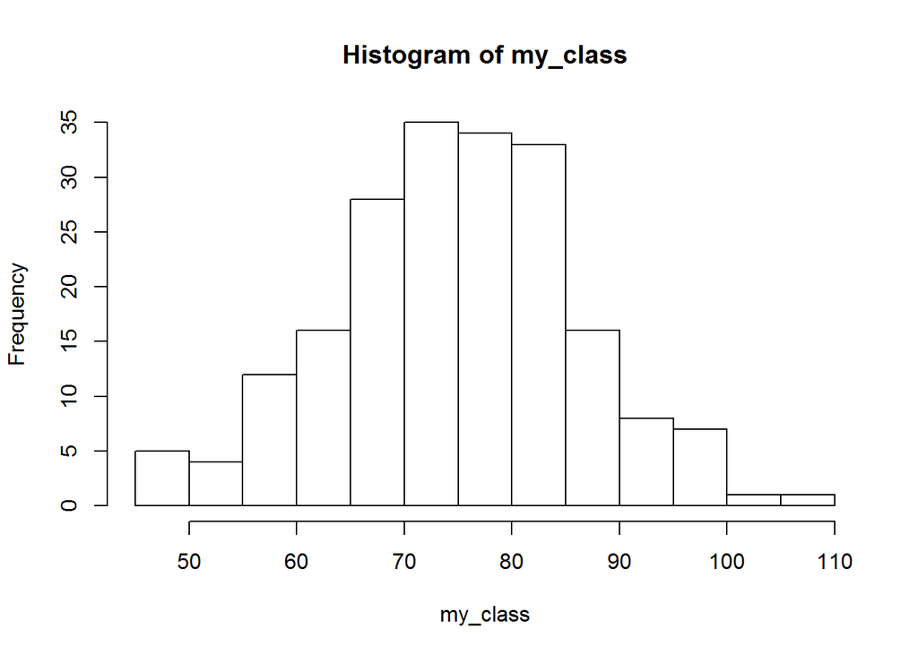

```r
previous_4 <- round(previous_4, 0)


# Merge me and other_199: my_class
my_class <- c(me, other_199)

# cbind() my_class and previous_4: last_5
last_5 <- cbind(my_class, previous_4)

# Name last_5 appropriately
nms <- paste0("year_", 1:5)
colnames(last_5) <- nms


# Build histogram of my_class
hist(my_class)
```

```r
# Generate summary of last_5
summary(last_5)
```

```
##      year_1           year_2           year_3           year_4
##  Min.   : 46.00   Min.   : 43.00   Min.   : 38.00   Min.   : 42.00
##  1st Qu.: 68.00   1st Qu.: 63.75   1st Qu.: 69.00   1st Qu.: 65.75
##  Median : 75.50   Median : 73.00   Median : 76.50   Median : 74.00
##  Mean   : 75.25   Mean   : 72.28   Mean   : 76.25   Mean   : 74.50
##  3rd Qu.: 83.25   3rd Qu.: 81.00   3rd Qu.: 84.25   3rd Qu.: 82.25
##  Max.   :108.00   Max.   :108.00   Max.   :102.00   Max.   :113.00
##      year_5
##  Min.   : 38.00
##  1st Qu.: 71.00
##  Median : 78.00
##  Mean   : 77.67
##  3rd Qu.: 86.00
##  Max.   :117.00
```

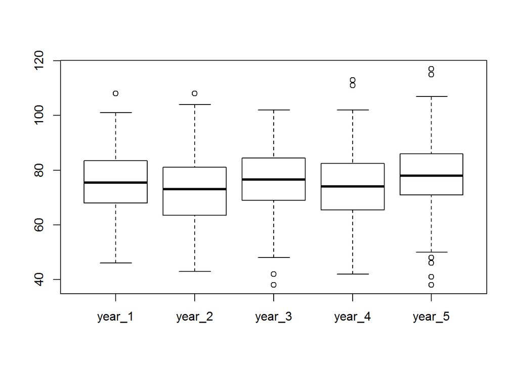

```r
# Build boxplot of last_5
boxplot(last_5)
```

```r
# How many grades in your class are higher than 75?
sum(my_class > 75)
```

```
## [1] 100
```

```r
# How many students in your class scored strictly higher than you?
sum(my_class > me)
```

```
## [1] 17
```

```r
# What's the proportion of grades below or equal to 64 in the last 5 years?
mean(last_5 <= 64)
```

```
## [1] 0.191
```

```r
# Is your grade greater than 87 and smaller than or equal to 89?
me > 87 & me <= 89
```

```
## [1] TRUE
```

```r
# Which grades in your class are below 60 or above 90?
my_class < 60 | my_class > 90
```

```
##   [1] FALSE FALSE  TRUE FALSE FALSE FALSE FALSE FALSE FALSE FALSE  TRUE
##  [12] FALSE FALSE FALSE FALSE FALSE FALSE FALSE FALSE  TRUE FALSE FALSE
##  [23]  TRUE FALSE  TRUE FALSE FALSE  TRUE  TRUE FALSE FALSE FALSE FALSE
##  [34]  TRUE FALSE FALSE FALSE FALSE FALSE FALSE FALSE FALSE FALSE  TRUE
##  [45]  TRUE FALSE FALSE FALSE FALSE FALSE FALSE FALSE FALSE FALSE  TRUE
##  [56] FALSE  TRUE FALSE FALSE FALSE FALSE FALSE FALSE FALSE FALSE FALSE
##  [67] FALSE FALSE FALSE FALSE FALSE FALSE  TRUE FALSE FALSE  TRUE FALSE
##  [78] FALSE  TRUE FALSE FALSE FALSE  TRUE  TRUE FALSE FALSE FALSE FALSE
##  [89]  TRUE FALSE FALSE FALSE FALSE  TRUE FALSE FALSE  TRUE  TRUE FALSE
## [100] FALSE FALSE  TRUE  TRUE FALSE FALSE FALSE FALSE FALSE FALSE FALSE
## [111] FALSE FALSE FALSE FALSE FALSE FALSE FALSE FALSE FALSE FALSE FALSE
## [122] FALSE FALSE FALSE FALSE FALSE FALSE  TRUE FALSE  TRUE FALSE FALSE
## [133] FALSE FALSE FALSE  TRUE FALSE FALSE FALSE FALSE FALSE FALSE FALSE
## [144]  TRUE FALSE FALSE  TRUE FALSE FALSE FALSE FALSE FALSE FALSE  TRUE
## [155] FALSE  TRUE FALSE  TRUE FALSE FALSE FALSE  TRUE FALSE FALSE FALSE
## [166] FALSE FALSE  TRUE FALSE FALSE FALSE  TRUE FALSE FALSE FALSE FALSE
## [177] FALSE FALSE  TRUE FALSE FALSE FALSE FALSE FALSE FALSE FALSE FALSE
## [188] FALSE FALSE FALSE FALSE FALSE FALSE FALSE FALSE FALSE  TRUE FALSE
## [199] FALSE FALSE
```

```r
# What's the proportion of grades in your class that is average?
mean(my_class >= 70 & my_class <= 85)
```

```
## [1] 0.525
```

```r
# How many students in the last 5 years had a grade of 80 or 90?
sum(last_5 %in% c(80, 90))
```

```
## [1] 44
```

```r
# Define n_smart
n_smart <- sum(my_class >= 80)

# Code the if-else construct
if (n_smart > 50) {
    print("smart class")
} else {
    print("rather average")
}
```

```
## [1] "smart class"
```

```r
# Define prop_less
prop_less <- mean(my_class < me)

# Code the control construct
if (prop_less > 0.9) {
    print("you're among the best 10 percent")
} else if (prop_less > 0.8) {
    print("you're among the best 20 percent")
} else {
    print("need more analysis")
}
```

```
## [1] "you're among the best 20 percent"
```

```r
# Embedded control structure: fix the error
if (mean(my_class) < 75) {
  if (mean(my_class) > me) {
    print("average year, but still smarter than me")
  } else {
    print("average year, but I'm not that bad")
  }
} else {
  if (mean(my_class) > me) {
    print("smart year, even smarter than me")
  } else {
    print("smart year, but I am smarter")
  }
}
```

```
## [1] "smart year, but I am smarter"
```

```r
# Create top_grades
top_grades <- my_class[my_class >= 85]

# Create worst_grades
worst_grades <- my_class[my_class < 65]

# Write conditional statement
if (length(top_grades) > length(worst_grades)) { print("top grades prevail") }
```

```
## [1] "top grades prevail"
```

### *R Programming (Writing Functions in R)*

Hadley and Charlotte Wickham led a course on writing functions in R. Broadly, the course includes advice on when/how to use functions, as well as specific advice about commands available through library(purrr).

Key pieces of advice include:

- Write a function once you have cut and paste some code twice or more
- Solve a simple problem before writing the function
- A good function is both correct and understandable
- Abstract away the for loops when possible (focus on data/actions, solve iteration more easily, have more understandable code), for example using purrr::map() or purr::map_() where type can be dbl, chr, lgl, int, forcing a type-certain output
- Use purrr::safely() and purrr::possibly() for better error handling
- Use purr::pmap or purr::walk2 to iterate over 2+ arguments
- Iterate functions for their side effects (printing, plotting, etc.) using purrr::walk()
- Use stop() and stopifnot() for error catching of function arguments/output formats
- Avoid type-inconsistent functions (e.g., sapply)
- Avoid non-standard functions
- Never rely on global options (e.g., how the user will have set stringsAsFactors)

John Chambers gave a few useful slogans about functions:

- Everything that exists is an object
- Everything that happens is a function call

Each function has three components:

- formals(x) are in essence the arguments as in args(), but as a list
- body(x) is the function code
- environment(x) is where it was defined

Only the LAST evaluated expression is returned. The use of return() is recommended only for early-returns in a special case (for example, when a break() will be called).

Further, functions can be written anonymously on the command line, such as (function (x) {x + 1}) (1:5). A function should only depend on arguments passed to it, not variables from a parent enviornment. Every time the function is called, it receives a clean working environment. Once it finishes, its variables are no longer available unless they were returned (either by default as the last operation, or by way of return()):

```r
# Components of a function
args(rnorm)
```

```
## function (n, mean = 0, sd = 1)
## NULL
```

```r
formals(rnorm)
```

```
## $n
##
##
## $mean
## [1] 0
##
## $sd
## [1] 1
```

```r
body(rnorm)
```

```
## .Call(C_rnorm, n, mean, sd)
```

```r
environment(rnorm)
```

```
## <environment: namespace:stats>
```

```r
# What is passed back
funDummy <- function(x) {
    if (x <= 2) {
        print("That is too small")
        return(3)  # This ends the function by convention
    }
    ceiling(x)  # This is the defaulted return() value if nothing happened to prevent the code getting here
}

funDummy(1)
```

```
## [1] "That is too small"
```

```
## [1] 3
```

```r
funDummy(5)
```

```
## [1] 5
```

```r
# Anonymous functions
(function (x) {x + 1}) (1:5)
```

```
## [1] 2 3 4 5 6
```

The course includes some insightful discussion of vectors. As it happens, lists and data frames are just special collections of vectors in R. Each column of a data frame is a vector, while each element of a list is either 1) an embedded data frame (which is eventually a vector by way of columns), 2) an embedded list (which is eventually a vector by way of recursion), or 3) an actual vector.

The atomic vectors are of types logical, integer, character, and double; complex and raw are rarer types that are also available. Lists are just recursive vectors, which is to say that lists can contain other lists and can be hetergeneous. To explore vectors, you have:

- typeof() for the type
- length() for the length

Note that NULL is the absence of a vector and has length 0. NA is the absence of an element in the vector and has length 1. All math operations with NA return NA; for example NA == NA will return NA.

There are some good tips on extracting element from a list:

- [] is to extract a sub-list
- [[]] and $ more common and extract elements while removing an element of hierachy
- seq_along(mtcars) will return 1:11 since there are 11 elements. Helfpully, is applied to a frame with no columns, this returns integer(0) which means the for() loop does not crash
- mtcars[[11]] will return the 11th element (11th column) of mtcars
- vector(“type”, “length”) will create a n empty vector of the requested type and length
- range(x, na.rm=FALSE) gives vector c(xmin, xmax) which can be handy for plotting, scaling, and the like

```r
# Data types
data(mtcars)
str(mtcars)
```

```
## 'data.frame':    32 obs. of  11 variables:
##  $ mpg : num  21 21 22.8 21.4 18.7 18.1 14.3 24.4 22.8 19.2 ...
##  $ cyl : num  6 6 4 6 8 6 8 4 4 6 ...
##  $ disp: num  160 160 108 258 360 ...
##  $ hp  : num  110 110 93 110 175 105 245 62 95 123 ...
##  $ drat: num  3.9 3.9 3.85 3.08 3.15 2.76 3.21 3.69 3.92 3.92 ...
##  $ wt  : num  2.62 2.88 2.32 3.21 3.44 ...
##  $ qsec: num  16.5 17 18.6 19.4 17 ...
##  $ vs  : num  0 0 1 1 0 1 0 1 1 1 ...
##  $ am  : num  1 1 1 0 0 0 0 0 0 0 ...
##  $ gear: num  4 4 4 3 3 3 3 4 4 4 ...
##  $ carb: num  4 4 1 1 2 1 4 2 2 4 ...
```

```r
typeof(mtcars)  # n.b. that this is technically a "list"
```

```
## [1] "list"
```

```r
length(mtcars)
```

```
## [1] 11
```

```r
# NULL and NA
length(NULL)
```

```
## [1] 0
```

```r
typeof(NULL)
```

```
## [1] "NULL"
```

```r
length(NA)
```

```
## [1] 1
```

```r
typeof(NA)
```

```
## [1] "logical"
```

```r
NULL == NULL
```

```
## logical(0)
```

```r
NULL == NA
```

```
## logical(0)
```

```r
NA == NA
```

```
## [1] NA
```

```r
is.null(NULL)
```

```
## [1] TRUE
```

```r
is.null(NA)
```

```
## [1] FALSE
```

```r
is.na(NULL)
```

```
## logical(0)
```

```r
is.na(NA)
```

```
## [1] TRUE
```

```r
# Extraction
mtcars[["mpg"]][1:5]
```

```
## [1] 21.0 21.0 22.8 21.4 18.7
```

```r
mtcars[[2]][1:5]
```

```
## [1] 6 6 4 6 8
```

```r
mtcars$hp[1:5]
```

```
## [1] 110 110  93 110 175
```

```r
# Relevant lengths
seq_along(mtcars)
```

```
##  [1]  1  2  3  4  5  6  7  8  9 10 11
```

```r
x <- data.frame()
seq_along(x)
```

```
## integer(0)
```

```r
length(seq_along(x))
```

```
## [1] 0
```

```r
foo <- function(x) { for (eachCol in seq_along(x)) { print(typeof(x[[eachCol]])) }}
foo(mtcars)
```

```
## [1] "double"
## [1] "double"
## [1] "double"
## [1] "double"
## [1] "double"
## [1] "double"
## [1] "double"
## [1] "double"
## [1] "double"
## [1] "double"
## [1] "double"
```

```r
foo(x)  # Note that this does nothing!
data(airquality)
str(airquality)
```

```
## 'data.frame':    153 obs. of  6 variables:
##  $ Ozone  : int  41 36 12 18 NA 28 23 19 8 NA ...
##  $ Solar.R: int  190 118 149 313 NA NA 299 99 19 194 ...
##  $ Wind   : num  7.4 8 12.6 11.5 14.3 14.9 8.6 13.8 20.1 8.6 ...
##  $ Temp   : int  67 72 74 62 56 66 65 59 61 69 ...
##  $ Month  : int  5 5 5 5 5 5 5 5 5 5 ...
##  $ Day    : int  1 2 3 4 5 6 7 8 9 10 ...
```

```r
foo(airquality)
```

```
## [1] "integer"
## [1] "integer"
## [1] "double"
## [1] "integer"
## [1] "integer"
## [1] "integer"
```

```r
# Range command
mpgRange <- range(mtcars$mpg)
mpgRange
```

```
## [1] 10.4 33.9
```

```r
mpgScale <- (mtcars$mpg - mpgRange[1]) / (mpgRange[2] - mpgRange[1])
summary(mpgScale)
```

```
##    Min. 1st Qu.  Median    Mean 3rd Qu.    Max.
##  0.0000  0.2138  0.3745  0.4124  0.5277  1.0000
```

The typical arguments in a function use a consistent, simple naming function:

- x, y, z: vectors
- df: data frame
- i, j: numeric indices (generally rows and columns)
- n: length of number of rows
- p: number of columns

Data arguments should come before detail arguments, and detail arguments should be given reasonable default values. See for example rnorm(n, mean=0, sd=1). The number requested (n) must be specified, but defaults are available for the details (mean and standard deviation).

#### *Functional Programming and library(purrr)*

Functions can be passed as arguments to other functions, which is at the core of functional programming. For example:

```r
do_math <- function(x, fun) { fun(x) }
do_math(1:10, fun=mean)
```

```
## [1] 5.5
```

```r
do_math(1:10, fun=sd)
```

```
## [1] 3.02765
```

The library(purrr) takes advantage of this, and in a type-consistent manner. There are functions for:

- map() will create a list as the output
- map_chr() will create a character vector as the output
- map_dbl() will create a double vector as the output
- map_int() will create an integer vector as the output
- map_lgl() will create a logical (boolean) vector as the output

The general arguments are .x (a list or an atomic vector) and .f which can be either a function, an anonymous function (formula with ~), or an extractor .x[[.f]]. For example:

```r
library(purrr)
library(RColorBrewer)  # Need to have in non-cached chunk for later

data(mtcars)

# Create output as a list
map(.x=mtcars, .f=sum)
```

```
## $mpg
## [1] 642.9
##
## $cyl
## [1] 198
##
## $disp
## [1] 7383.1
##
## $hp
## [1] 4694
##
## $drat
## [1] 115.09
##
## $wt
## [1] 102.952
##
## $qsec
## [1] 571.16
##
## $vs
## [1] 14
##
## $am
## [1] 13
##
## $gear
## [1] 118
##
## $carb
## [1] 90
```

```r
# Create same output as a double
map_dbl(.x=mtcars, .f=sum)
```

```
##      mpg      cyl     disp       hp     drat       wt     qsec       vs
##  642.900  198.000 7383.100 4694.000  115.090  102.952  571.160   14.000
##       am     gear     carb
##   13.000  118.000   90.000
```

```r
# Create same output as integer
# map_int(.x=mtcars, .f=sum) . . . this would bomb since it is not actually an integere
map_int(.x=mtcars, .f=function(x) { as.integer(round(sum(x), 0)) } )
```

```
##  mpg  cyl disp   hp drat   wt qsec   vs   am gear carb
##  643  198 7383 4694  115  103  571   14   13  118   90
```

```r
# Same thing but using an anonymous function with ~ and .
map_int(.x=mtcars, .f = ~ as.integer(round(sum(.), 0)) )
```

```
##  mpg  cyl disp   hp drat   wt qsec   vs   am gear carb
##  643  198 7383 4694  115  103  571   14   13  118   90
```

```r
# Create a boolean vector
map_lgl(.x=mtcars, .f = ~ ifelse(sum(.) > 200, TRUE, FALSE) )
```

```
##   mpg   cyl  disp    hp  drat    wt  qsec    vs    am  gear  carb
##  TRUE FALSE  TRUE  TRUE FALSE FALSE  TRUE FALSE FALSE FALSE FALSE
```

```r
# Create a character vector
map_chr(.x=mtcars, .f = ~ ifelse(sum(.) > 200, "Large", "Not So Large") )
```

```
##            mpg            cyl           disp             hp           drat
##        "Large" "Not So Large"        "Large"        "Large" "Not So Large"
##             wt           qsec             vs             am           gear
## "Not So Large"        "Large" "Not So Large" "Not So Large" "Not So Large"
##           carb
## "Not So Large"
```

```r
# Use the extractor [pulls the first row]
map_dbl(.x=mtcars, .f=1)
```

```
##    mpg    cyl   disp     hp   drat     wt   qsec     vs     am   gear
##  21.00   6.00 160.00 110.00   3.90   2.62  16.46   0.00   1.00   4.00
##   carb
##   4.00
```

```r
# Example from help file using chaining
mtcars %>%
  split(.$cyl) %>%
  map(~ lm(mpg ~ wt, data = .x)) %>%
  map(summary) %>%
  map_dbl("r.squared")
```

```
##         4         6         8
## 0.5086326 0.4645102 0.4229655
```

```r
# Using sapply
sapply(split(mtcars, mtcars$cyl), FUN=function(.x) { summary(lm(mpg ~ wt, data=.x))$r.squared } )
```

```
##         4         6         8
## 0.5086326 0.4645102 0.4229655
```

```r
# Use the extractor from a list
cylSplit <- split(mtcars, mtcars$cyl)
map(cylSplit, "mpg")
```

```
## $`4`
##  [1] 22.8 24.4 22.8 32.4 30.4 33.9 21.5 27.3 26.0 30.4 21.4
##
## $`6`
## [1] 21.0 21.0 21.4 18.1 19.2 17.8 19.7
##
## $`8`
##  [1] 18.7 14.3 16.4 17.3 15.2 10.4 10.4 14.7 15.5 15.2 13.3 19.2 15.8 15.0
```

```r
map(cylSplit, "cyl")
```

```
## $`4`
##  [1] 4 4 4 4 4 4 4 4 4 4 4
##
## $`6`
## [1] 6 6 6 6 6 6 6
##
## $`8`
##  [1] 8 8 8 8 8 8 8 8 8 8 8 8 8 8
```

The purrr library has several additional interesting functions:

- safely() is a wrapper for any functions that traps the errors and returns a relevant list
- possibly() is similar to safely() with the exception that a default value for error cases is supplied
- quietly() is a wrapper to suppress verbosity
- transpose() reverses the order of lists (making the inner-most lists the outer-most lists), which is an easy way to extract either all the answers or all the error cases
- map2(.x, .y, .f) allows two inputs to be passed to map()
- pmap(.l, .f) allows passing a named list with as many inputs as needed to function .f
- invoke_map(.f, .x, …) lets you iterate over a list of functions .f
- walk() is like map() but called solely to get function side effects (plot, save, etc.); it also returns the object that is passed to it, which can be convenient for chaining (piping)

Some example code includes:

```r
library(purrr)  # Called again for clarity; all these key functions belong to purrr

# safely(.f, otherwise = NULL, quiet = TRUE)
safe_log10 <- safely(log10)
map(list(0, 1, 10, "a"), .f=safe_log10)
```

```
## [[1]]
## [[1]]$result
## [1] -Inf
##
## [[1]]$error
## NULL
##
##
## [[2]]
## [[2]]$result
## [1] 0
##
## [[2]]$error
## NULL
##
##
## [[3]]
## [[3]]$result
## [1] 1
##
## [[3]]$error
## NULL
##
##
## [[4]]
## [[4]]$result
## NULL
##
## [[4]]$error
## <simpleError in .f(...): non-numeric argument to mathematical function>
```

```r
# possibly(.f, otherwise, quiet = TRUE)
poss_log10 <- possibly(log10, otherwise=NaN)
map_dbl(list(0, 1, 10, "a"), .f=poss_log10)
```

```
## [1] -Inf    0    1  NaN
```

```r
# transpose() - note that this can become masked by data.table::transpose() so be careful
purrr::transpose(map(list(0, 1, 10, "a"), .f=safe_log10))
```

```
## $result
## $result[[1]]
## [1] -Inf
##
## $result[[2]]
## [1] 0
##
## $result[[3]]
## [1] 1
##
## $result[[4]]
## NULL
##
##
## $error
## $error[[1]]
## NULL
##
## $error[[2]]
## NULL
##
## $error[[3]]
## NULL
##
## $error[[4]]
## <simpleError in .f(...): non-numeric argument to mathematical function>
```

```r
purrr::transpose(map(list(0, 1, 10, "a"), .f=safe_log10))$result
```

```
## [[1]]
## [1] -Inf
##
## [[2]]
## [1] 0
##
## [[3]]
## [1] 1
##
## [[4]]
## NULL
```

```r
unlist(purrr::transpose(map(list(0, 1, 10, "a"), .f=safe_log10))$result)
```

```
## [1] -Inf    0    1
```

```r
purrr::transpose(map(list(0, 1, 10, "a"), .f=safe_log10))$error
```

```
## [[1]]
## NULL
##
## [[2]]
## NULL
##
## [[3]]
## NULL
##
## [[4]]
## <simpleError in .f(...): non-numeric argument to mathematical function>
```

```r
map_lgl(purrr::transpose(map(list(0, 1, 10, "a"), .f=safe_log10))$error, is.null)
```

```
## [1]  TRUE  TRUE  TRUE FALSE
```

```r
# map2(.x, .y, .f)
map2(list(5, 10, 20), list(1, 2, 3), .f=rnorm) # rnorm(5, 1), rnorm(10, 2), and rnorm(20, 3)
```

```
## [[1]]
## [1] 0.41176421 2.00652288 0.06152025 0.46963873 1.15436157
##
## [[2]]
##  [1] 0.006821057 2.902712636 1.436150816 1.377836302 2.625075832
##  [6] 0.680797806 0.313499192 0.718062969 2.820989906 3.134207742
##
## [[3]]
##  [1] 3.3716474 2.9393673 1.8648940 3.2343343 2.1849894 2.0697179 1.0872014
##  [8] 3.4970403 3.5769694 3.0999340 1.2033341 0.9839011 2.9820314 1.7116383
## [15] 0.8779558 1.6990118 2.5914013 2.3587803 3.7460957 1.2980312
```

```r
# pmap(.l, .f)
pmap(list(n=list(5, 10, 20), mean=list(1, 5, 10), sd=list(0.1, 0.5, 0.1)), rnorm)
```

```
## [[1]]
## [1] 1.0151570 1.1573287 1.0628581 0.8805484 0.9418430
##
## [[2]]
##  [1] 5.032920 4.689799 5.423525 5.265610 4.727383 5.252325 5.166292
##  [8] 4.861745 5.135408 4.106679
##
## [[3]]
##  [1]  9.854138 10.090939 10.045554  9.970755 10.092487  9.769531 10.140064
##  [8]  9.834716 10.196817 10.047367 10.054093 10.006439 10.142002 10.092259
## [15] 10.222459 10.082440 10.067818  9.993884 10.078380  9.936942
```

```r
# invoke_map(.f, .x, ...)
invoke_map(list(rnorm, runif, rexp), n=5)
```

```
## [[1]]
## [1] -0.96707137  0.08207476  1.39498168  0.60287972 -0.15130461
##
## [[2]]
## [1] 0.01087442 0.02980483 0.81443586 0.88438198 0.67976034
##
## [[3]]
## [1] 0.2646751 1.3233260 1.1079261 1.3504952 0.6795524
```

```r
# walk() is for the side effects of a function
x <- list(1, "\n\ta\n", 3)
x %>% walk(cat)
```

```
## 1
##  a
## 3
```

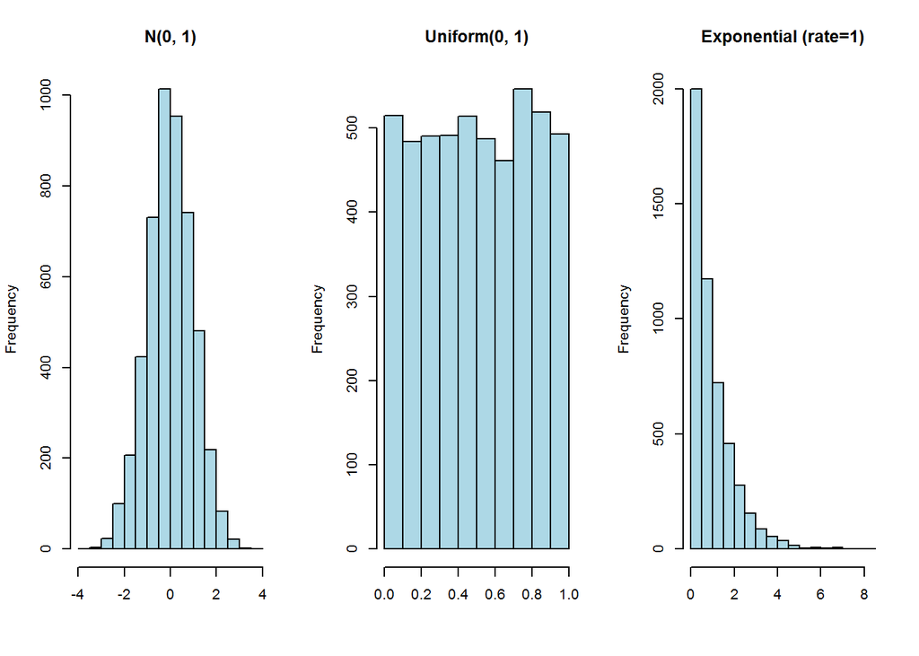

```
## $x
## $x[[1]]
##      Min.   1st Qu.    Median      Mean   3rd Qu.      Max.
## -3.711000 -0.637800 -0.000217  0.006543  0.671800  3.633000
##
## $x[[2]]
##      Min.   1st Qu.    Median      Mean   3rd Qu.      Max.
## 0.0001241 0.2518000 0.5012000 0.5028000 0.7566000 0.9999000
##
## $x[[3]]
##    Min. 1st Qu.  Median    Mean 3rd Qu.    Max.
## 0.00001 0.29140 0.68340 0.98260 1.37900 8.46300
##
##
## $main
## $main[[1]]
##    Length     Class      Mode
##         1 character character
##
## $main[[2]]
##    Length     Class      Mode
##         1 character character
##
## $main[[3]]
##    Length     Class      Mode
##         1 character character
```

```r
# Chaining is available by way of the %>% operator
pretty_titles <- c("N(0, 1)", "Uniform(0, 1)", "Exponential (rate=1)")
set.seed(1607120947)
x <- invoke_map(list(rnorm, runif, rexp), n=5000)
foo <- function(x) { map(x, .f=summary) }
par(mfrow=c(1, 3))
pwalk(list(x=x, main=pretty_titles), .f=hist, xlab="", col="light blue") %>% map(.f=foo)
```

```r
par(mfrow=c(1, 1))
```

#### *Writing Robust Functions*

There are two potentially desirable behaviors with functions:

- Relaxed (default R approach) - make reasonable guesses about what you mean, which is particularly useful for interactive analyses
- Robust (programming) - strict functions that throw errors rather than guessing in light of uncertainty

As a best practice, R functions that will be used for programming (as opposed to interactive command line work) should be written in a robust manner. Three standard problems should be avoided/mitigated:

- Type-unstable - may return a vector one time, and a list the next
- Non-standard evaluation - can use succinct API, but can introduce ambiguity
- Hidden arguments - dependence on global functions/environments

There are several methods available for throwing errors within an R function:

- stopifnot(expression) will stop and throw an error unless expression is TRUE
- if (expression) { stop(“Error”, call.=FALSE) }
- if (expression) { stop(" ‘x’ should be a character vector“, call.=FALSE) }
  - call.=FALSE means that the call to the function should not be shown (???) - Hadley recommends this

One example that commonly creates surprises is the [,] operator for extraction. Adding [ , , drop=FALSE] ensures that you will still have what you passed (e.g., a matrix or data frame) rather than conversion of a chunk of data to a vector.

Another common source of error is sapply() which will return a vector when it can and a list otherwise. The map() and map_typ() functions in purrr are designed to be type-stable; if the output is not as expected, they will error out.

Non-standard evaluations take advantage of the existence of something else (e.g., a variable in the parent environment that has not been passed). This can cause confusion and improper results.

- subset(mtcars, disp > 400) takes advantage of disp being an element of mtcars; disp would crash if called outside subset
- This can cause problems when it is embedded inside a function
- ggplot and dplyr frequently have these behaviors also
  - The risk is that you can also put variables from the global environment in to the same call

Pure functions have the key properties that 1) their output depends only on their inputs, and 2) they do not impact the outside world other than by way of their return value. Specifically, the function should not depend on how the user has configured their global options as shown in options(), nor should it modify those options() settings upon return of control to the parent environment.

A few examples are shown below:

```r
# Throwing errors to stop a function (cannot actually run these!)
# stopifnot(FALSE)
# if (FALSE) { stop("Error: ", call.=FALSE) }
# if (FALSE) { stop("Error: This condition needed to be set as TRUE", call.=FALSE) }

# Behavior of [,] and [,,drop=FALSE]
mtxTest <- matrix(data=1:9, nrow=3, byrow=TRUE)
class(mtxTest)
```

```
## [1] "matrix"
```

```r
mtxTest[1, ]
```

```
## [1] 1 2 3
```

```r
class(mtxTest[1, ])
```

```
## [1] "integer"
```

```r
mtxTest[1, , drop=FALSE]
```

```
##      [,1] [,2] [,3]
## [1,]    1    2    3
```

```r
class(mtxTest[1, , drop=FALSE])
```

```
## [1] "matrix"
```

```r
# Behavior of sapply() - may not get what you are expecting
foo <- function(x) { x^2 }
sapply(1:5, FUN=foo)
```

```
## [1]  1  4  9 16 25
```

```r
class(sapply(1:5, FUN=foo))
```

```
## [1] "numeric"
```

```r
sapply(c(1, list(1.5, 2, 2.5), 3, 4, 5), FUN=foo)
```

```
## [1]  1.00  2.25  4.00  6.25  9.00 16.00 25.00
```

```r
class(sapply(c(1, list(1.5, 2, 2.5), 3, 4, 5), FUN=foo))
```

```
## [1] "numeric"
```

```r
sapply(list(1, c(1.5, 2, 2.5), 3, 4, 5), FUN=foo)
```

```
## [[1]]
## [1] 1
##
## [[2]]
## [1] 2.25 4.00 6.25
##
## [[3]]
## [1] 9
##
## [[4]]
## [1] 16
##
## [[5]]
## [1] 25
```

```r
class(sapply(list(1, c(1.5, 2, 2.5), 3, 4, 5), FUN=foo))
```

```
## [1] "list"
```

This was a very enjoyable and instructive course.

### *Object Oriented Programming (OOP) in R: S3 and R6*

Chapter 1 - Introduction to Object Oriented Programming (OOP)

Typical R usage involves a functional programming style - data to function to new data to new function to newer values and etc. Object Oriented Programming (OOP) instead involves thinking about the data structures (objects), their functionalities, and the like:

- A method is just a function, talked about in an OOP context
- There are ~20 objects available in R; of particular interest are 1) lists and 2) environments
- Frequently, OOP is neither desirable nor necessary for data analysis; you actually prefer the functional programming style
- OOP is often better when you have a limited number of objects and you understand their behavior very well (e.g., industry SME such as Bioconductor)
  - An example would be the genomic range object
- OOP can also be better for areas like API where there are limited numbers of responses and they can be stored accordingly
- OOP can also be better for areas like GUI, as there tend to be just a small number of objects (buttons, drop-downs, and the like)
- In a nutshell, OOP is great for tool-building, while functional programming is best for data analysis

There are nine different options for OOP in R:

- No need to learn these five (5): R.oo (never really took off), OOP (defunct and no longer available), R5 (experimental and abandoned), mutatr (experimental and banadoned), proto (used early in ggplot2 but mostly deprecated now)
- S3 (fundamental R skill) - around since the 1980s; mature and widely used; a very simple system that implements functions being able to work differently on different objects; one-trick pony, but “it’s a great trick”
- S4 has been around since S version 4, mostly “a little weird and not necessarily recommended to learn as a first choice”; caveated that Bioconductor is a big user of S4
- ReferenceClasses is an attempt to behave similarly to Java, C# and the like - encapsulation and inheritance and the like
- R6 covers much of the same ground as ReferenceClasses, but in a much simpler manner
- Gist is to 1) use S3 regularly, and 2) use R6 when you need higher power and/or functionality than S3

How does R distinguish types of variables?

- Generally, class() is sufficient to interrogate the type of a variable
- If class() returns “matrix” then it may be helpful to know what the matrix contains; typeof() will distinguish that it is “integer” or “double” or “character” or the like
  - The typeof() query and result can be particularly important in S3
- The functions mode() and storage.mode() exist for compatability with older versions of S; should know they exist but no need to use them per se

Assigning Classes and Implicit Classes:

- The class can be reassigned, for example with class(x) <- “random_numbers”
- While class() can be overridden, typeof() cannot; typeof(x) will be the same even if class(x) has been reassigned
- If typeof(x) is “double” then x would be said to have an implicit class of “numeric”
  - And, as such, is.numeric(x) will still return TRUE
  - Additionally, length(x) and mean(x) and the like will still work properly, treating x as the numeric that it is

Example code includes:

```r
# Create these variables
a_numeric_vector <- rlnorm(50)
a_factor <- factor(
  sample(c(LETTERS[1:5], NA), 50, replace = TRUE)
)
a_data_frame <- data.frame(
  n = a_numeric_vector,
  f = a_factor
)
a_linear_model <- lm(dist ~ speed, cars)

# Call summary() on the numeric vector
summary(a_numeric_vector)
```

```
##    Min. 1st Qu.  Median    Mean 3rd Qu.    Max.
## 0.08694 0.58120 1.06400 1.63500 1.48800 7.43600
```

```r
# Do the same for the other three objects
summary(a_factor)
```

```
##    A    B    C    D    E NA's
##    5    9    8   11   11    6
```

```r
summary(a_data_frame)
```

```
##        n              f
##  Min.   :0.08694   A   : 5
##  1st Qu.:0.58121   B   : 9
##  Median :1.06361   C   : 8
##  Mean   :1.63546   D   :11
##  3rd Qu.:1.48764   E   :11
##  Max.   :7.43560   NA's: 6
```

```r
summary(a_linear_model)
```

```
##
## Call:
## lm(formula = dist ~ speed, data = cars)
##
## Residuals:
##     Min      1Q  Median      3Q     Max
## -29.069  -9.525  -2.272   9.215  43.201
##
## Coefficients:
##             Estimate Std. Error t value Pr(>|t|)
## (Intercept) -17.5791     6.7584  -2.601   0.0123 *
## speed         3.9324     0.4155   9.464 1.49e-12 ***
## ---
## Signif. codes:  0 '***' 0.001 '**' 0.01 '*' 0.05 '.' 0.1 ' ' 1
##
## Residual standard error: 15.38 on 48 degrees of freedom
## Multiple R-squared:  0.6511, Adjusted R-squared:  0.6438
## F-statistic: 89.57 on 1 and 48 DF,  p-value: 1.49e-12
```

```r
type_info <-
function(x)
{
  c(
    class = class(x),
    typeof = typeof(x),
    mode = mode(x),
    storage.mode = storage.mode(x)
  )
}

# Create list of example variables
some_vars <- list(
  an_integer_vector = rpois(24, lambda = 5),
  a_numeric_vector = rbeta(24, shape1 = 1, shape2 = 1),
  an_integer_array = array(rbinom(24, size = 8, prob = 0.5), dim = c(2, 3, 4)),
  a_numeric_array = array(rweibull(24, shape = 1, scale = 1), dim = c(2, 3, 4)),
  a_data_frame = data.frame(int = rgeom(24, prob = 0.5), num = runif(24)),
  a_factor = factor(month.abb),
  a_formula = y ~ x,
  a_closure_function = mean,
  a_builtin_function = length,
  a_special_function = `if`
)

# Loop over some_vars calling type_info() on each element to explore them
lapply(some_vars, FUN=type_info)
```

```
## $an_integer_vector
##        class       typeof         mode storage.mode
##    "integer"    "integer"    "numeric"    "integer"
##
## $a_numeric_vector
##        class       typeof         mode storage.mode
##    "numeric"     "double"    "numeric"     "double"
##
## $an_integer_array
##        class       typeof         mode storage.mode
##      "array"    "integer"    "numeric"    "integer"
##
## $a_numeric_array
##        class       typeof         mode storage.mode
##      "array"     "double"    "numeric"     "double"
##
## $a_data_frame
##        class       typeof         mode storage.mode
## "data.frame"       "list"       "list"       "list"
##
## $a_factor
##        class       typeof         mode storage.mode
##     "factor"    "integer"    "numeric"    "integer"
##
## $a_formula
##        class       typeof         mode storage.mode
##    "formula"   "language"       "call"   "language"
##
## $a_closure_function
##        class       typeof         mode storage.mode
##   "function"    "closure"   "function"   "function"
##
## $a_builtin_function
##        class       typeof         mode storage.mode
##   "function"    "builtin"   "function"   "function"
##
## $a_special_function
##        class       typeof         mode storage.mode
##   "function"    "special"   "function"   "function"
```

```r
whiteChess <- list(king="g1", queen="h4", bishops=c("c2", "g5"), knights=character(0), rooks=c("f1", "f6"), pawns=c("a2", "b2", "d4", "e3", "g2", "h2"))
blackChess <- list(king="g8", queen="d7", bishops=c("b7", "e7"), knights=character(0), rooks=c("a6", "f8"), pawns=c("a5", "c3", "c4", "d5", "f7", "g6"))
chess <- list(white=whiteChess, black=blackChess)

# Explore the structure of chess
str(chess)
```

```
## List of 2
##  $ white:List of 6
##   ..$ king   : chr "g1"
##   ..$ queen  : chr "h4"
##   ..$ bishops: chr [1:2] "c2" "g5"
##   ..$ knights: chr(0)
##   ..$ rooks  : chr [1:2] "f1" "f6"
##   ..$ pawns  : chr [1:6] "a2" "b2" "d4" "e3" ...
##  $ black:List of 6
##   ..$ king   : chr "g8"
##   ..$ queen  : chr "d7"
##   ..$ bishops: chr [1:2] "b7" "e7"
##   ..$ knights: chr(0)
##   ..$ rooks  : chr [1:2] "a6" "f8"
##   ..$ pawns  : chr [1:6] "a5" "c3" "c4" "d5" ...
```

```r
# Override the class of chess
class(chess) <- "chess_game"

# Is chess still a list?
is.list(chess)
```

```
## [1] TRUE
```

```r
# How many pieces are left on the board?
length(unlist(chess))
```

```
## [1] 24
```

```r
type_info(chess)  # note that typeof(), mode(), and storage.mode() all remained as list
```

```
##        class       typeof         mode storage.mode
## "chess_game"       "list"       "list"       "list"
```

Chapter 2 - Using S3

Function overloading is the property of a function of input-dependent behavior:

- The primary purpose is to make coding easier - otherwise, there would need to be many more functions
- The S3 system exists to make this simpler; specifically, S3 splits a function in to “generic” and “method”
- Methods always need to be named as generic.class; for example, print.Date or summary.factor or unique.array; the generic.default can be used as the default for all other cases
  - The generic function will then call UseMethod(“”)
- The method signatures contain the generic signatures (everything the method needs can be passed by the generic)
- Arguments can be passed between methods using the ellipsis ( . ); best practice is to include this in both the generic and the method
- Due to the feature of using generic.Method to call the various functions, naming functions with dots in them is bad practice (known as “lower.leopard.case” and is a bad idea to use)
  - Preferable is lower_snake_case or lowerCamelCase
- Can be tested using pryr::is_s3_generic() and pryr::is_s3_method()

Methodical Thinking - determining which methods are available for an S3 generic:

- Can pass the string quoted or not - methods(“mean”) and methods(mean) will both return the methods of mean
- Alternately, methods(class = “glm”) or methods(class = glm) will show all the generics that have a method for “glm”
  - This is more generous than just S3; will return both the S3 methods and the S4 methods
  - For ONLY the S3 methods, use .S3methods(class = “glm”)
  - For ONLY the S4 methods, use .S4methods(class = “glm”)
- Generally, the methods() command is the best to use

S3 and Primitive Functions:

- Most of the time for an R user is typically spent on writing, debugging, and maintaining code; as such, these tasks are often optimized by R
- However, sometimes the time need to run the code is vital; these functions are typically written in C rather than R
  - The trade-off is that C code is typically harder to write and also harder to debug
  - R has several interfaces to the C language
- Primitive - direct access through a few fundamental features reserved in base R (a function that uses this access is called a “Primitive Function” and will be .Primitive(“”))
  - .S3PrimitiveGenerics will list all of the S3 generic functions with primitive access to C
  - The primitive generic will have C go directly to the “typeof” without worrying about what class the user may have created; other generics will bomb out if the class cannot be handled

Too Much Class:

- A variable may be a member of more than one class (common with things that are tbl_df and data.frame at the same time)
- Generally, the most specific class should be listed first with the more generic classes listed last; good practice is to keep the original class at the end of the string
- The inherits() function is a nice way to see whether something belongs to a class - for example, inherits(x, “numeric”) will be TRUE is x can use the generic.numeric functions
  - Generally, this is slower than using a specific function such as is.numeric(x), so the advice is to use the specific functions as and when they are available
- The NextMethod(“function”) in a generic.method will call the next class to be acted on; can only be used if there are additional classes to be acted on (???)

Example code includes:

```r
# Create get_n_elements
get_n_elements <- function(x, ...) {
  UseMethod("get_n_elements")
}

# View get_n_elements
get_n_elements
```

```
## function(x, ...) {
##   UseMethod("get_n_elements")
## }
```

```r
# Create a data.frame method for get_n_elements
get_n_elements.data.frame <- function(x, ...) {
  nrow(x) * ncol(x)
}

# Call the method on the sleep dataset
n_elements_sleep <- get_n_elements(sleep)

# View the result
n_elements_sleep
```

```
## [1] 60
```

```r
# View pre-defined objects
# ls.str()  ## Do not run, this can be a cluster with many variables loaded . . .

# Create a default method for get_n_elements
get_n_elements.default <- function(x, ...) {
  length(unlist(x))
}

# Call the method on the ability.cov dataset
n_elements_ability.cov <- get_n_elements(ability.cov)


# Find methods for print
methods("print")
```

```
##   [1] print.acf*
##   [2] print.AES*
##   [3] print.anova*
##   [4] print.aov*
##   [5] print.aovlist*
##   [6] print.ar*
##   [7] print.Arima*
##   [8] print.arima0*
##   [9] print.AsIs
##  [10] print.aspell*
##  [11] print.aspell_inspect_context*
##  [12] print.bibentry*
##  [13] print.Bibtex*
##  [14] print.browseVignettes*
##  [15] print.by
```

[output cut: 187 more lines]

```r
# Commented due to no dataset "hair" on my machine
# View the structure of hair
# str(hair)

# What primitive generics are available?
.S3PrimitiveGenerics
```

```
##  [1] "anyNA"          "as.character"   "as.complex"     "as.double"
##  [5] "as.environment" "as.integer"     "as.logical"     "as.numeric"
##  [9] "as.raw"         "c"              "dim"            "dim<-"
## [13] "dimnames"       "dimnames<-"     "is.array"       "is.finite"
## [17] "is.infinite"    "is.matrix"      "is.na"          "is.nan"
## [21] "is.numeric"     "length"         "length<-"       "levels<-"
## [25] "names"          "names<-"        "rep"            "seq.int"
## [29] "xtfrm"
```

```r
# Does length.hairstylist exist?
# exists("length.hairstylist")

# What is the length of hair?
# length(hair)


kitty <- "Miaow!"

# Assign classes
class(kitty) <- c("cat", "mammal", "character")

# Does kitty inherit from cat/mammal/character vector?
inherits(kitty, "cat")
```

```
## [1] TRUE
```

```r
inherits(kitty, "mammal")
```

```
## [1] TRUE
```

```r
inherits(kitty, "character")
```

```
## [1] TRUE
```

```r
# Is kitty a character vector?
is.character(kitty)
```

```
## [1] TRUE
```

```r
# Does kitty inherit from dog?
inherits(kitty, "dog")
```

```
## [1] FALSE
```

```r
what_am_i <-
function(x, ...)
{
  UseMethod("what_am_i")
}

# cat method
what_am_i.cat <- function(x, ...)
{
  # Write a message
  print("I'm a cat")
  # Call NextMethod
  NextMethod("what_am_i")
}

# mammal method
what_am_i.mammal <- function(x, ...)
{
  # Write a message
  print("I'm a mammal")
  # Call NextMethod
  NextMethod("what_am_i")
}

# character method
what_am_i.character <- function(x, ...)
{
  # Write a message
  print("I'm a character vector")
}

# Call what_am_i()
what_am_i(kitty)
```

```
## [1] "I'm a cat"
## [1] "I'm a mammal"
## [1] "I'm a character vector"
```

Chapter 3 - Using R6

Object factory - R6 provides a means of storing data and objects within the same variable:

- First step is to create a “class generator” (template for objects) defining what can be stored in it and what actions can be applied to it
  - Can also be referred to as the “factory”; it can create the objects
- Factories are defined using R6::R6Class(“”, private=list(), public=, active=)
- The $new() method of the defined factory will create a new object based on the factory’s pre-defined elements

Hiding Complexity with Encapsulation - should be able to use something even if the internal (hidden) functionality is very complicated:

- The term “encapsulation” means separating the implementation from the user interface
- Generally, the encapsulation for R6 is contained in the private=list() aspect of the factory
- The user-interface data for R6 is contained in the public=list() aspect of the factory; each aspect of this list would typically be a function
  - The function might access field in the private list, using private$ to achieve this
  - The function might access fields in the public list, using self$ to achieve this

Generally, data available in the “private” area of a class is not available to users:

- From time to time, you may want to grant “controlled access” to this “private” data – “getting” (OOP for reading) the data or “setting” (OOP for writing) the data
- R6 achieves this through “Active Bindings”; these are defined like functions, but accessed like data variables
- The “active bindings” are added to the active=list() component of an R6::R6Class()
- R6 requires that different names be used throughout; a common best practice is for all “private” variables to start with two periods (..)
- By convention, “setting” is a function that takes a single argument named “value”

Example code includes:

```r
# Define microwave_oven_factory
microwave_oven_factory <- R6::R6Class(
  "MicrowaveOven",
  private=list(power_rating_watts=800)
)

# View the microwave_oven_factory
microwave_oven_factory
```

```
## <MicrowaveOven> object generator
##   Public:
##     clone: function (deep = FALSE)
##   Private:
##     power_rating_watts: 800
##   Parent env: <environment: R_GlobalEnv>
##   Locked objects: TRUE
##   Locked class: FALSE
##   Portable: TRUE
```

```r
# Make a new microwave oven
microwave_oven <- microwave_oven_factory$new()


# Add a cook method to the factory definition
microwave_oven_factory <- R6::R6Class(
  "MicrowaveOven",
  private = list(
    power_rating_watts = 800
  ),
  public = list(
    cook = function(time_seconds) {
      Sys.sleep(time_seconds)
      print("Your food is cooked!")
    }
  )
)

# Create microwave oven object
a_microwave_oven <- microwave_oven_factory$new()

# Call cook method for 1 second
a_microwave_oven$cook(time_seconds=1)
```

```
## [1] "Your food is cooked!"
```

```r
# Add a close_door() method
microwave_oven_factory <- R6::R6Class(
  "MicrowaveOven",
  private = list(
    power_rating_watts = 800,
    door_is_open = FALSE
  ),
  public = list(
    cook = function(time_seconds) {
      Sys.sleep(time_seconds)
      print("Your food is cooked!")
    },
    open_door = function() {
      private$door_is_open = TRUE
    },
    close_door = function() {
      private$door_is_open = FALSE
    }
  )
)


# Add an initialize method
microwave_oven_factory <- R6::R6Class(
  "MicrowaveOven",
  private = list(
    power_rating_watts = 800,
    door_is_open = FALSE
  ),
  public = list(
    cook = function(time_seconds) {
      Sys.sleep(time_seconds)
      print("Your food is cooked!")
    },
    open_door = function() {
      private$door_is_open = TRUE
    },
    close_door = function() {
      private$door_is_open = FALSE
    },
    # Add initialize() method here
    initialize = function(power_rating_watts, door_is_open) {
      if (!missing(power_rating_watts)) {
        private$power_rating_watts <- power_rating_watts
      }
      if (!missing(door_is_open)) {
        private$door_is_open <- door_is_open
      }
    }
  )
)

# Make a microwave
a_microwave_oven <- microwave_oven_factory$new(power_rating_watts=650, door_is_open=TRUE)


# Add a binding for power rating
microwave_oven_factory <- R6::R6Class(
  "MicrowaveOven",
  private = list(
    ..power_rating_watts = 800
  ),
  active = list(
    # add the binding here
    power_rating_watts = function() {
      private$..power_rating_watts
    }

  )
)

# Make a microwave
a_microwave_oven <- microwave_oven_factory$new()

# Get the power rating
a_microwave_oven$power_rating_watts
```

```
## [1] 800
```

```r
# Add a binding for power rating
microwave_oven_factory <- R6::R6Class(
  "MicrowaveOven",
  private = list(
    ..power_rating_watts = 800,
    ..power_level_watts = 800
  ),
  # Add active list containing an active binding
  active=list(
    power_level_watts = function(value) {
      if (missing(value)) {
        private$..power_level_watts
      } else {
        assertive.types::assert_is_a_number(value, severity="warning")
        assertive.numbers::assert_all_are_in_closed_range(value,
                                                          lower=0,
                                                          upper=private$..power_rating_watts,
                                                          severity="warning"
                                                          )
        private$..power_level_watts <- value
      }
    }
  )
)

# Make a microwave
a_microwave_oven <- microwave_oven_factory$new()

# Get the power level
a_microwave_oven$power_level_watts
```

```
## [1] 800
```

```r
# Try to set the power level to "400"
a_microwave_oven$power_level_watts <- "400"
# Try to set the power level to 1600 watts
a_microwave_oven$power_level_watts <- 1600
# Set the power level to 400 watts
a_microwave_oven$power_level_watts <- 400
```

Chapter 4 - R6 Inheritance

Inheritance is an attempt to avoid “copy and paste” from one class to another (dependent, fancier, or the like) class:

- “Parent” is the class that you inherit from
- “Children” are the classes that inherit from you
- Setting inherit= inside R6::R6Class() will send over all the private, public, and active from the parent
  - You can still add public functions and the like
- Inheritance works only in one direction - children take from parents, not the other way around
- The class() argument will be both the “parent” class and the “child” class

Extend or Override to create additional functionality:

- To override functionality, you define things with the same name as they have in the parent
- To extend functionality, you define new variables and functions, which will only be available in the child class
- The prefixes allow for access to elements from the parent, even when those have been overridden
  - private$ accesses private fields
  - self$ accesses public methods in self
  - super$ accesses public methods in parent

Multiple Levels of Inheritance - a can inherit from b that inherited from c and the like:

- By default, R6 classes only have access to their direct parent (no use of super$super$ or the like to get at the grandparent)
- This can be addressed by an active binding in the child - active=list(super_ = function() super ) # defaults to be named _super since super is a reserved word
- So, the call would become super$super_$

Example code includes:

```r
microwave_oven_factory <-
    R6::R6Class("MicrowaveOven",
                private=list(..power_rating_watts=800,
                             ..power_level_watts=800,
                             ..door_is_open=FALSE
                             ),
                public=list(cook=function(time) Sys.sleep(time),
                            open_door=function() private$..door_is_open <- TRUE,
                            close_door = function() private$..door_is_open <- FALSE
                            ),
                active=list(power_rating_watts=function() private$..power_rating_watts,
                            power_level_watts = function(value) {
                                if (missing(value)) {
                                    private$..power_level_watts
                                    } else {
                                        private$..power_level_watts <-
                                            max(0,
                                                min(private$..power_rating_watts,
                                                    as.numeric(value)
                                                    )
                                                )
                                    }
                                }
                            )
                )

# Explore the microwave oven class
microwave_oven_factory
```

```
## <MicrowaveOven> object generator
##   Public:
##     cook: function (time)
##     open_door: function ()
##     close_door: function ()
##     clone: function (deep = FALSE)
##   Active bindings:
##     power_rating_watts: function ()
##     power_level_watts: function (value)
##   Private:
##     ..power_rating_watts: 800
##     ..power_level_watts: 800
##     ..door_is_open: FALSE
##   Parent env: <environment: R_GlobalEnv>
##   Locked objects: TRUE
##   Locked class: FALSE
##   Portable: TRUE
```

```r
# Define a fancy microwave class inheriting from microwave oven
fancy_microwave_oven_factory <- R6::R6Class(
  "FancyMicrowaveOven",
  inherit=microwave_oven_factory
)


# Explore microwave oven classes
microwave_oven_factory
```

```
## <MicrowaveOven> object generator
##   Public:
##     cook: function (time)
##     open_door: function ()
##     close_door: function ()
##     clone: function (deep = FALSE)
##   Active bindings:
##     power_rating_watts: function ()
##     power_level_watts: function (value)
##   Private:
##     ..power_rating_watts: 800
##     ..power_level_watts: 800
##     ..door_is_open: FALSE
##   Parent env: <environment: R_GlobalEnv>
##   Locked objects: TRUE
##   Locked class: FALSE
##   Portable: TRUE
```

```r
fancy_microwave_oven_factory
```

```
## <FancyMicrowaveOven> object generator
##   Inherits from: <microwave_oven_factory>
##   Public:
##     clone: function (deep = FALSE)
##   Parent env: <environment: R_GlobalEnv>
##   Locked objects: TRUE
##   Locked class: FALSE
##   Portable: TRUE
```

```r
# Instantiate both types of microwave
a_microwave_oven <- microwave_oven_factory$new()
a_fancy_microwave <- fancy_microwave_oven_factory$new()

# Get power rating for each microwave
microwave_power_rating <- a_microwave_oven$power_level_watts
fancy_microwave_power_rating <- a_fancy_microwave$power_level_watts

# Verify that these are the same
identical(microwave_power_rating, fancy_microwave_power_rating)
```

```
## [1] TRUE
```

```r
# Cook with each microwave
a_microwave_oven$cook(1)
a_fancy_microwave$cook(1)

# Explore microwave oven class
microwave_oven_factory
```

```
## <MicrowaveOven> object generator
##   Public:
##     cook: function (time)
##     open_door: function ()
##     close_door: function ()
##     clone: function (deep = FALSE)
##   Active bindings:
##     power_rating_watts: function ()
##     power_level_watts: function (value)
##   Private:
##     ..power_rating_watts: 800
##     ..power_level_watts: 800
##     ..door_is_open: FALSE
##   Parent env: <environment: R_GlobalEnv>
##   Locked objects: TRUE
##   Locked class: FALSE
##   Portable: TRUE
```

```r
# Extend the class definition
fancy_microwave_oven_factory <- R6::R6Class(
  "FancyMicrowaveOven",
  inherit = microwave_oven_factory,
  # Add a public list with a cook baked potato method
  public = list(
    cook_baked_potato=function() {
      self$cook(3)
    }
  )
)

# Instantiate a fancy microwave
a_fancy_microwave <- fancy_microwave_oven_factory$new()

# Call the cook_baked_potato() method
a_fancy_microwave$cook_baked_potato()


# Explore microwave oven class
microwave_oven_factory
```

```
## <MicrowaveOven> object generator
##   Public:
##     cook: function (time)
##     open_door: function ()
##     close_door: function ()
##     clone: function (deep = FALSE)
##   Active bindings:
##     power_rating_watts: function ()
##     power_level_watts: function (value)
##   Private:
##     ..power_rating_watts: 800
##     ..power_level_watts: 800
##     ..door_is_open: FALSE
##   Parent env: <environment: R_GlobalEnv>
##   Locked objects: TRUE
##   Locked class: FALSE
##   Portable: TRUE
```

```r
# Update the class definition
fancy_microwave_oven_factory <- R6::R6Class(
  "FancyMicrowaveOven",
  inherit = microwave_oven_factory,
  # Add a public list with a cook method
  public = list(
    cook = function(time_seconds) {
      super$cook(time_seconds)
      message("Enjoy your dinner!")
    }
  )

)

# Instantiate a fancy microwave
a_fancy_microwave <- fancy_microwave_oven_factory$new()

# Call the cook() method
a_fancy_microwave$cook(1)
```

```
## Enjoy your dinner!
```

```r
# Expose the parent functionality
fancy_microwave_oven_factory <- R6::R6Class(
  "FancyMicrowaveOven",
  inherit = microwave_oven_factory,
  public = list(
    cook_baked_potato = function() {
      self$cook(3)
    },
    cook = function(time_seconds) {
      super$cook(time_seconds)
      message("Enjoy your dinner!")
    }
  ),
  # Add an active element with a super_ binding
  active = list(
    super_ = function() super
  )
)

# Instantiate a fancy microwave
a_fancy_microwave <- fancy_microwave_oven_factory$new()

# Call the super_ binding
a_fancy_microwave$super_
```

```
## <environment: 0x000000000a2c1fb0>
```

```r
ascii_pizza_slice <- "   __\n // \"\"--.._\n||  (_)  _ \"-._\n||    _ (_)    '-.\n||   (_)   __..-'\n \\\\__..--\"\""


# Explore other microwaves
microwave_oven_factory
```

```
## <MicrowaveOven> object generator
##   Public:
##     cook: function (time)
##     open_door: function ()
##     close_door: function ()
##     clone: function (deep = FALSE)
##   Active bindings:
##     power_rating_watts: function ()
##     power_level_watts: function (value)
##   Private:
##     ..power_rating_watts: 800
##     ..power_level_watts: 800
##     ..door_is_open: FALSE
##   Parent env: <environment: R_GlobalEnv>
##   Locked objects: TRUE
##   Locked class: FALSE
##   Portable: TRUE
```

```r
fancy_microwave_oven_factory
```

```
## <FancyMicrowaveOven> object generator
##   Inherits from: <microwave_oven_factory>
##   Public:
##     cook_baked_potato: function ()
##     cook: function (time_seconds)
##     clone: function (deep = FALSE)
##   Active bindings:
##     super_: function ()
##   Parent env: <environment: R_GlobalEnv>
##   Locked objects: TRUE
##   Locked class: FALSE
##   Portable: TRUE
```

```r
# Define a high-end microwave oven class
high_end_microwave_oven_factory <- R6::R6Class(
  "HighEndMicrowaveOven",
  inherit=fancy_microwave_oven_factory,
  public=list(
    cook=function(time_seconds) {
      super$super_$cook(time_seconds)
      message(ascii_pizza_slice)
    }
  )
)

# Instantiate a high-end microwave oven
a_high_end_microwave <- high_end_microwave_oven_factory$new()

# Use it to cook for one second
a_high_end_microwave$cook(1)
```

```
##    __
##  // ""--.._
## ||  (_)  _ "-._
## ||    _ (_)    '-.
## ||   (_)   __..-'
##  \\__..--""
```

Chapter 5 - Advanced R6 Usage

Environments, Reference Behavior, and Static Fields:

- New environments can be called using the new.env() # environments are always created empty
- Adding elements to an environment is very similar in syntax to adding elements to a list # The ls.str() is the best way to look at these
- One large behavioral change is that if environment A is copied to environment B, then changes made in environment A will be reflected in environment B
- R typically uses “copy by value”, where environment use “copy by reference”
- The R6 class can take advantage of the “copying by reference”, specifically by adding a shared={} to the private list of the environment
  - e <- new.env()
  - assign any variables that you like to e in later lines
  - e # just a return of the environment
- The fields can then be accessed through an active binding, using private$shared$ # can either retrieve the value or modify the value this way

Cloning Objects - R6 is built using environments, so the “copy by reference” is part and parcel of R6:

- The clone() method in R6 will instead copy by value
- So, if you set a_clone <- a_thing$clone(), a_clone will be a “copy by value” (and specifically not a “copy by reference”) of a_thing
  - There is also an argument deep=TRUE that can be inside clone(), which will make sure “copy by value” applies to all elements inside the class

Shut it Down - if the R6 object is linked to any databases or has any side effects, it can be a good idea to shut it down:

- Counterpart to initialize() is finalize(), which are the actions to take when the R6 object is detsroyed
- The rm() function does not always make the finalize() happen; rather, it will occur during garbage collection
- To force R to run the garbage collection, you can request the gc() at the command line

Example code includes:

```r
# Define a new environment
env <- new.env()

# Add an element named perfect
env$perfect <- c(6, 28, 496)

# Add an element named bases
env[["bases"]] <- c("A", "C", "G", "T")


# Assign lst and env
lst <- list(
  perfect = c(6, 28, 496),
  bases = c("A", "C", "G", "T")
)
env <- list2env(lst)

# Copy lst
lst2 <- lst

# Change lst's bases element
lst$bases <- c("A", "C", "G", "U")

# Test lst and lst2 identical
identical(lst$bases, lst2$bases)
```

```
## [1] FALSE
```

```r
# Copy env
env2 <- env

# Change env's bases element
env$bases <- c("A", "C", "G", "U")

# Test env and env2 identical
identical(env$bases, env2$bases)
```

```
## [1] TRUE
```

```r
# Complete the class definition
env_microwave_oven_factory <- R6::R6Class(
  "MicrowaveOven",
  private = list(
    shared = {
      # Create a new environment named e
      e <- new.env()
      # Assign safety_warning into e
      e$safety_warning <- "Warning. Do not try to cook metal objects."
      # Return e
      e
    }
  ),
  active = list(
    # Add the safety_warning binding
    safety_warning = function(value) {
      if (missing(value)) {
        private$shared$safety_warning
      } else {
        private$shared$safety_warning <- value
      }
    }
  )
)

# Create two microwave ovens
a_microwave_oven <- env_microwave_oven_factory$new()
another_microwave_oven <- env_microwave_oven_factory$new()

# Change the safety warning for a_microwave_oven
a_microwave_oven$safety_warning <- "Warning. If the food is too hot you may scald yourself."

# Verify that the warning has change for another_microwave
another_microwave_oven$safety_warning
```

```
## [1] "Warning. If the food is too hot you may scald yourself."
```

```r
# Still uses microwave_oven_factory as defined in Chapter 4
# Create a microwave oven
a_microwave_oven <- microwave_oven_factory$new()

# Copy a_microwave_oven using <-
assigned_microwave_oven <- a_microwave_oven

# Copy a_microwave_oven using clone()
cloned_microwave_oven <- a_microwave_oven$clone()

# Change a_microwave_oven's power level
a_microwave_oven$power_level_watts <- 400

# Check a_microwave_oven & assigned_microwave_oven same
identical(a_microwave_oven$power_level_watts, assigned_microwave_oven$power_level_watts)
```

```
## [1] TRUE
```

```r
# Check a_microwave_oven & cloned_microwave_oven different
!identical(a_microwave_oven$power_level_watts, cloned_microwave_oven$power_level_watts)
```

```
## [1] TRUE
```

```r
# Commented, due to never defined power_plug
# Create a microwave oven
# a_microwave_oven <- microwave_oven_factory$new()

# Look at its power plug
# a_microwave_oven$power_plug

# Copy a_microwave_oven using clone(), no args
# cloned_microwave_oven <- a_microwave_oven$clone()

# Copy a_microwave_oven using clone(), deep = TRUE
# deep_cloned_microwave_oven <- a_microwave_oven$clone(deep=TRUE)

# Change a_microwave_oven's power plug type
# a_microwave_oven$power_plug$type <- "British"

# Check a_microwave_oven & cloned_microwave_oven same
# identical(a_microwave_oven$power_plug$type, cloned_microwave_oven$power_plug$type)

# Check a_microwave_oven & deep_cloned_microwave_oven different
# !identical(a_microwave_oven$power_plug$type, deep_cloned_microwave_oven$power_plug$type)


# Commented due to not having this SQL database
# Microwave_factory is pre-defined
# microwave_oven_factory

# Complete the class definition
# smart_microwave_oven_factory <- R6::R6Class(
#   "SmartMicrowaveOven",
#   inherit = microwave_oven_factory, # Specify inheritance
#   private = list(
#     conn = NULL
#   ),
#   public = list(
#     initialize = function() {
#       # Connect to the database
#       private$conn = dbConnect(SQLite(), "cooking-times.sqlite")
#     },
#     get_cooking_time = function(food) {
#       dbGetQuery(
#         private$conn,
#         sprintf("SELECT time_seconds FROM cooking_times WHERE food = '%s'", food)
#       )
#     },
#     finalize = function() {
#       message("Disconnecting from the cooking times database.")
#       dbDisconnect(private$conn)
#     }
#   )
# )

# Create a smart microwave object
# a_smart_microwave <- smart_microwave_oven_factory$new()

# Call the get_cooking_time() method
# a_smart_microwave$get_cooking_time("soup")

# Remove the smart microwave
# rm(a_smart_microwave)

# Force garbage collection
# gc()
```

A nice introduction to S3 and R6.

## Machine Learning

### *Introduction to Machine Learning*

Chapter 1 - What is Machine Learning?

Machine learning is the process of constructing and using algorithms that learn from data:

- Learning means that “more information leads to better performance”
- Input Knowledge is typically a dataset containing a number of observations, data about them (features), and (sometimes) their classification or known result (label)
- The entire point of machine learning is to make predictions; it is not descriptive statistics

Classification, Regression, Clustering are three common forms of machine learning problems:

- Classification is predicting the class (category) for an unknown object based solely on its features
  - Qualitative output, with known categories for which the unseen objects can potentially be assigned
- Regression predicts a continuous range using the predictors/response approach
  - Quantitative output, requeires previous input-output observations
- Clsutering is grouping similar objects together, and different objects in different clusters
  - Similar to classification, though without labelling the resulting clusters
  - Need not have a prior sense for what is “right” or “wrong” in the data

Supervised vs Unsupervised Learning:

- Supervised learning means that labels (answers) are available during the training process - Classification and Regression are examples
- Unsupervised learning means that labels (answers) are not available during the training process - Clustering is an example
- Semi-Supervised learning is the blend of some labelled and some labelled data; cluster, then use the labelled data to define the clusters

Example code includes:

```r
data(iris, package="datasets")

# Reveal number of observations and variables in two different ways
str(iris)
```

```
## 'data.frame':    150 obs. of  5 variables:
##  $ Sepal.Length: num  5.1 4.9 4.7 4.6 5 5.4 4.6 5 4.4 4.9 ...
##  $ Sepal.Width : num  3.5 3 3.2 3.1 3.6 3.9 3.4 3.4 2.9 3.1 ...
##  $ Petal.Length: num  1.4 1.4 1.3 1.5 1.4 1.7 1.4 1.5 1.4 1.5 ...
##  $ Petal.Width : num  0.2 0.2 0.2 0.2 0.2 0.4 0.3 0.2 0.2 0.1 ...
##  $ Species     : Factor w/ 3 levels "setosa","versicolor",..: 1 1 1 1 1 1 1 1 1 1 ...
```

```r
dim(iris)
```

```
## [1] 150   5
```

```r
# Show first and last observations in the iris data set
head(iris)
```

```
##   Sepal.Length Sepal.Width Petal.Length Petal.Width Species
## 1          5.1         3.5          1.4         0.2  setosa
## 2          4.9         3.0          1.4         0.2  setosa
## 3          4.7         3.2          1.3         0.2  setosa
## 4          4.6         3.1          1.5         0.2  setosa
## 5          5.0         3.6          1.4         0.2  setosa
## 6          5.4         3.9          1.7         0.4  setosa
```

```r
tail(iris)
```

```
##     Sepal.Length Sepal.Width Petal.Length Petal.Width   Species
## 145          6.7         3.3          5.7         2.5 virginica
## 146          6.7         3.0          5.2         2.3 virginica
## 147          6.3         2.5          5.0         1.9 virginica
## 148          6.5         3.0          5.2         2.0 virginica
## 149          6.2         3.4          5.4         2.3 virginica
## 150          5.9         3.0          5.1         1.8 virginica
```

```r
# Summarize the iris data set
summary(iris)
```

```
##   Sepal.Length    Sepal.Width     Petal.Length    Petal.Width
##  Min.   :4.300   Min.   :2.000   Min.   :1.000   Min.   :0.100
##  1st Qu.:5.100   1st Qu.:2.800   1st Qu.:1.600   1st Qu.:0.300
##  Median :5.800   Median :3.000   Median :4.350   Median :1.300
##  Mean   :5.843   Mean   :3.057   Mean   :3.758   Mean   :1.199
##  3rd Qu.:6.400   3rd Qu.:3.300   3rd Qu.:5.100   3rd Qu.:1.800
##  Max.   :7.900   Max.   :4.400   Max.   :6.900   Max.   :2.500
##        Species
##  setosa    :50
##  versicolor:50
##  virginica :50
##
##
##
```

```r
data(Wage, package="ISLR")

# Build Linear Model: lm_wage (coded already)
lm_wage <- lm(wage ~ age, data = Wage)

# Define data.frame: unseen (coded already)
unseen <- data.frame(age = 60)

# Predict the wage for a 60-year old worker
predict(lm_wage, unseen)
```

```
##        1
## 124.1413
```

```r
emails <- data.frame(
    avg_capital_seq=c( 1, 2.11, 4.12, 1.86, 2.97, 1.69, 5.891, 3.17, 1.23, 2.44, 3.56, 3.25, 1.33 ),
    spam=as.integer(c( 0, 0, 1, 0, 1, 0, 1, 0, 0, 1, 0, 0, 1 ))
    )
str(emails)
```

```
## 'data.frame':    13 obs. of  2 variables:
##  $ avg_capital_seq: num  1 2.11 4.12 1.86 2.97 ...
##  $ spam           : int  0 0 1 0 1 0 1 0 0 1 ...
```

```r
# Show the dimensions of emails
dim(emails)
```

```
## [1] 13  2
```

```r
# Inspect definition of spam_classifier()
spam_classifier <- function(x){
  prediction <- rep(NA, length(x)) # initialize prediction vector
  prediction[x > 4] <- 1
  prediction[x >= 3 & x <= 4] <- 0
  prediction[x >= 2.2 & x < 3] <- 1
  prediction[x >= 1.4 & x < 2.2] <- 0
  prediction[x > 1.25 & x < 1.4] <- 1
  prediction[x <= 1.25] <- 0
  return(prediction) # prediction is either 0 or 1
}

# Apply the classifier to the avg_capital_seq column: spam_pred
spam_pred <- spam_classifier(emails$avg_capital_seq)

# Compare spam_pred to emails$spam. Use ==
spam_pred == emails$spam
```

```
##  [1] TRUE TRUE TRUE TRUE TRUE TRUE TRUE TRUE TRUE TRUE TRUE TRUE TRUE
```

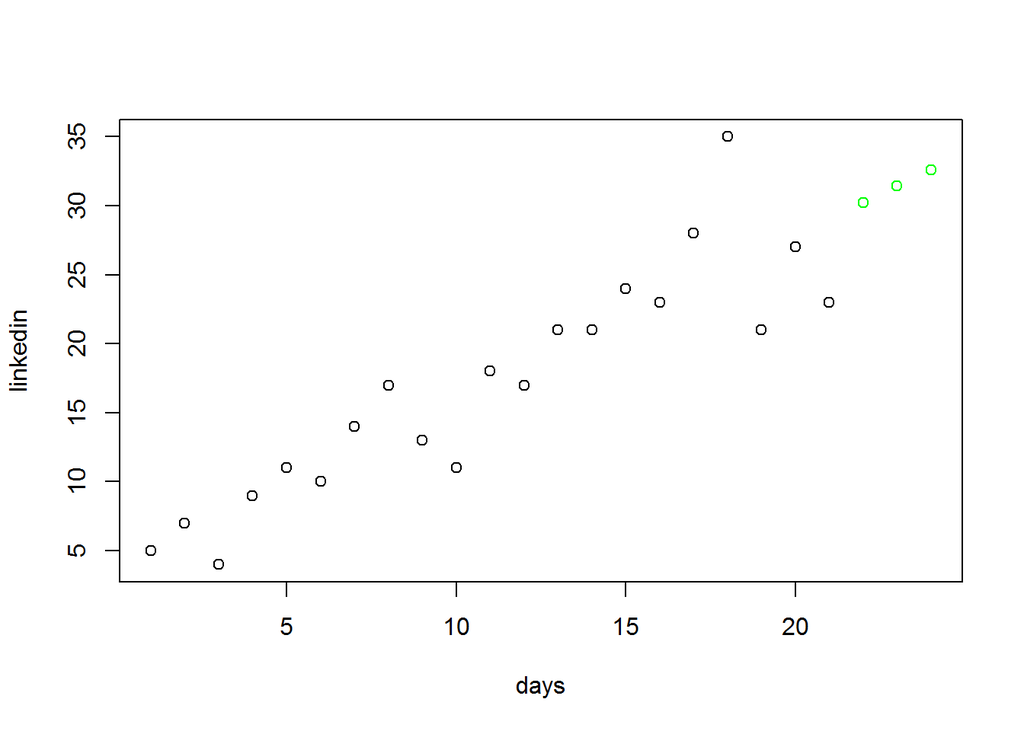

```r
linkedin <- c( 5, 7, 4, 9, 11, 10, 14, 17, 13, 11, 18, 17, 21, 21, 24, 23, 28, 35, 21, 27, 23 )

# Create the days vector
days <- 1:length(linkedin)

# Fit a linear model called on the linkedin views per day: linkedin_lm
linkedin_lm <- lm(linkedin ~ days)

# Predict the number of views for the next three days: linkedin_pred
future_days <- data.frame(days = 22:24)
linkedin_pred <- predict(linkedin_lm, future_days)

# Plot historical data and predictions
plot(linkedin ~ days, xlim = c(1, 24))
points(22:24, linkedin_pred, col = "green")
```

```r
# Chop up iris in my_iris and species
my_iris <- iris[-5]
species <- iris$Species

# Perform k-means clustering on my_iris: kmeans_iris
kmeans_iris <- kmeans(my_iris, 3)

# Compare the actual Species to the clustering using table()
table(kmeans_iris$cluster, species)
```

```
##    species
##     setosa versicolor virginica
##   1     50          0         0
##   2      0          2        36
##   3      0         48        14
```

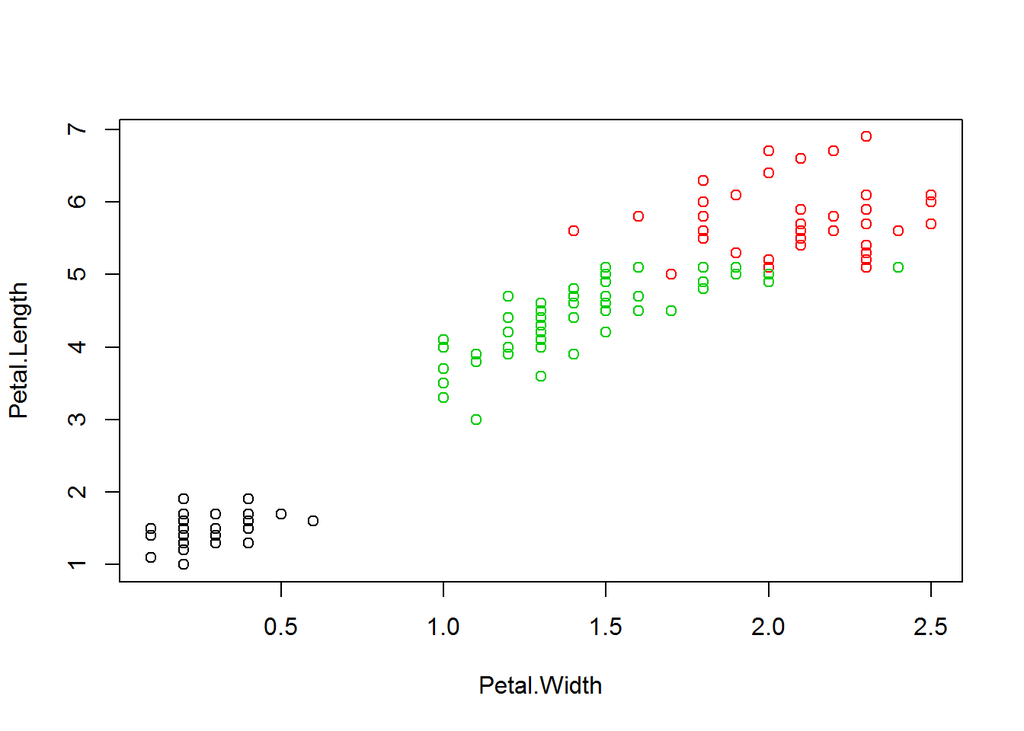

```r
# Plot Petal.Width against Petal.Length, coloring by cluster
plot(Petal.Length ~ Petal.Width, data = my_iris, col = kmeans_iris$cluster)
```

```r
# Take a look at the iris dataset
str(iris)
```

```
## 'data.frame':    150 obs. of  5 variables:
##  $ Sepal.Length: num  5.1 4.9 4.7 4.6 5 5.4 4.6 5 4.4 4.9 ...
##  $ Sepal.Width : num  3.5 3 3.2 3.1 3.6 3.9 3.4 3.4 2.9 3.1 ...
##  $ Petal.Length: num  1.4 1.4 1.3 1.5 1.4 1.7 1.4 1.5 1.4 1.5 ...
##  $ Petal.Width : num  0.2 0.2 0.2 0.2 0.2 0.4 0.3 0.2 0.2 0.1 ...
##  $ Species     : Factor w/ 3 levels "setosa","versicolor",..: 1 1 1 1 1 1 1 1 1 1 ...
```

```r
summary(iris)
```

```
##   Sepal.Length    Sepal.Width     Petal.Length    Petal.Width
##  Min.   :4.300   Min.   :2.000   Min.   :1.000   Min.   :0.100
##  1st Qu.:5.100   1st Qu.:2.800   1st Qu.:1.600   1st Qu.:0.300
##  Median :5.800   Median :3.000   Median :4.350   Median :1.300
##  Mean   :5.843   Mean   :3.057   Mean   :3.758   Mean   :1.199
##  3rd Qu.:6.400   3rd Qu.:3.300   3rd Qu.:5.100   3rd Qu.:1.800
##  Max.   :7.900   Max.   :4.400   Max.   :6.900   Max.   :2.500
##        Species
##  setosa    :50
##  versicolor:50
##  virginica :50
##
##
##
```

```r
# A decision tree model has been built for you
tree <- rpart::rpart(Species ~ Sepal.Length + Sepal.Width + Petal.Length + Petal.Width,
              data = iris, method = "class")

# A dataframe containing unseen observations
unseen <- data.frame(Sepal.Length = c(5.3, 7.2),
                     Sepal.Width = c(2.9, 3.9),
                     Petal.Length = c(1.7, 5.4),
                     Petal.Width = c(0.8, 2.3)
                     )

# Predict the label of the unseen observations. Print out the result.
predict(tree, unseen, type="class")
```

```
##         1         2
##    setosa virginica
## Levels: setosa versicolor virginica
```

```r
data(mtcars, package="datasets")
cars <- mtcars[,c("wt", "hp")]
str(cars)
```

```
## 'data.frame':    32 obs. of  2 variables:
##  $ wt: num  2.62 2.88 2.32 3.21 3.44 ...
##  $ hp: num  110 110 93 110 175 105 245 62 95 123 ...
```

```r
# Explore the cars dataset
str(cars)
```

```
## 'data.frame':    32 obs. of  2 variables:
##  $ wt: num  2.62 2.88 2.32 3.21 3.44 ...
##  $ hp: num  110 110 93 110 175 105 245 62 95 123 ...
```

```r
summary(cars)
```

```
##        wt              hp
##  Min.   :1.513   Min.   : 52.0
##  1st Qu.:2.581   1st Qu.: 96.5
##  Median :3.325   Median :123.0
##  Mean   :3.217   Mean   :146.7
##  3rd Qu.:3.610   3rd Qu.:180.0
##  Max.   :5.424   Max.   :335.0
```

```r
# Group the dataset into two clusters: km_cars
km_cars <- kmeans(cars, 2)

# Print out the contents of each cluster
km_cars$cluster
```

```
##           Mazda RX4       Mazda RX4 Wag          Datsun 710
##                   2                   2                   2
##      Hornet 4 Drive   Hornet Sportabout             Valiant
##                   2                   1                   2
##          Duster 360           Merc 240D            Merc 230
##                   1                   2                   2
##            Merc 280           Merc 280C          Merc 450SE
##                   2                   2                   1
##          Merc 450SL         Merc 450SLC  Cadillac Fleetwood
##                   1                   1                   1
## Lincoln Continental   Chrysler Imperial            Fiat 128
##                   1                   1                   2
##         Honda Civic      Toyota Corolla       Toyota Corona
##                   2                   2                   2
##    Dodge Challenger         AMC Javelin          Camaro Z28
##                   2                   2                   1
##    Pontiac Firebird           Fiat X1-9       Porsche 914-2
##                   1                   2                   2
##        Lotus Europa      Ford Pantera L        Ferrari Dino
##                   2                   1                   1
##       Maserati Bora          Volvo 142E
##                   1                   2
```

```r
# Group the dataset into two clusters: km_cars
km_cars <- kmeans(cars, 2)

# Add code: color the points in the plot based on the clusters
plot(cars, col=km_cars$cluster)

# Print out the cluster centroids
km_cars$centers
```

```
##         wt        hp
## 1 2.692000  99.47368
## 2 3.984923 215.69231
```

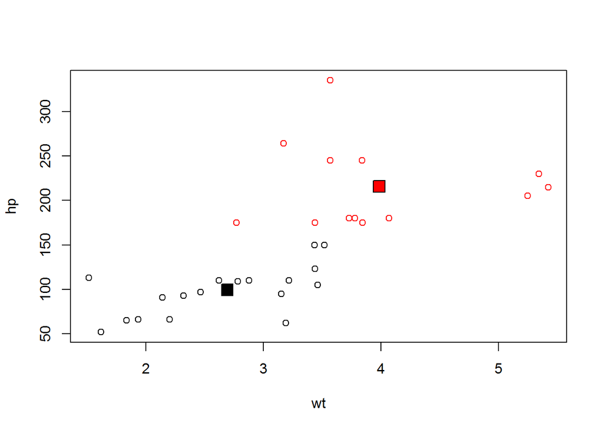

```r
# Replace the ___ part: add the centroids to the plot
points(km_cars$centers, pch = 22, bg = c(1, 2), cex = 2)
```

Chapter 2 - Performance Measures

Measuring model performance or error - is the model good?

- Contect dependent assessment - speed, accuracy, interpretability, etc.
- Classification systems are assessed based on accuracy (correct/total) and error (1 - accuracy)
  - Confusion matrix with truth as rows and prediction as columns - for binary classifier, these are True Positive, True Negative, False Positive (model P, reality N), and False Negative (model N, reality P)
  - Precision = TP / (TP + FP) # of the positives that I predict, how many are actually true positives?
  - Recall = TP / (TP + FN) # of the actual positive cases, how many did I correctly classify as being positive?
- Regression systems are frequently assessed using RMSE (square-root of the mean of the sum-squared residuals)
- Clustering systems are frequently assessed using 1) similarity within cluster, and 2) similarity between clusters
  - Within cluster distances are often assessed using WSS (within sum-squares) or diameter
  - Between cluster distances often assessed using BSS (between sum-squares) or inter-cluster distances
  - Dunn’s index = (minimal inter-cluster) / (maximal diameter)

Training set and test set - power is about the ability to make predictions about unseen data:

- Split raw data in to a training set and a test set (fully disjoint) so that the test set can assess the real-world predictive power
- Generally, the training set should be larger than the test set (3:1 being common, though arbitrary)
- Shuffle the dataset before splitting; as well, for classification, be sure that all classes are proportionally represented in both the training and the test data
- Cross-validation (sampling multiple times, with different separations) can further increase the robustness of the model
  - In the k-fold example, the the data is split in to k-equal pieces, and each piece serves as the test dataset once

Bias and variance are the main error sources for a predictive model:

- Irreducible error, or noise, should not be minimized
- Reducible error, or error due to unfit model, should be minimized
  - Bias - error due to wrong assumptions (typically under-fits), which will never get better with more training data
  - Variance - error due to sampling of the training set (typically over-fits), which will get better with more training data
- Typically, managing Bias-Variance trade-offs will help make the best predictions using the unseen data

Example code includes:

```r
library(dplyr)
data(titanic_train, package="titanic")

titanic <- titanic_train %>%
    select(Survived, Pclass, Sex, Age) %>%
    mutate(Survived=factor(Survived, levels=c(1, 0)), Sex=factor(Sex)) %>%
    na.omit()

# Have a look at the structure of titanic
str(titanic)
```

```
## 'data.frame':    714 obs. of  4 variables:
##  $ Survived: Factor w/ 2 levels "1","0": 2 1 1 1 2 2 2 1 1 1 ...
##  $ Pclass  : int  3 1 3 1 3 1 3 3 2 3 ...
##  $ Sex     : Factor w/ 2 levels "female","male": 2 1 1 1 2 2 2 1 1 1 ...
##  $ Age     : num  22 38 26 35 35 54 2 27 14 4 ...
##  - attr(*, "na.action")=Class 'omit'  Named int [1:177] 6 18 20 27 29 30 32 33 37 43 ...
##   .. ..- attr(*, "names")= chr [1:177] "6" "18" "20" "27" ...
```

```r
# A decision tree classification model is built on the data
tree <- rpart::rpart(Survived ~ ., data = titanic, method = "class")

# Use the predict() method to make predictions, assign to pred
pred <- predict(tree, titanic, type="class")

# Use the table() method to make the confusion matrix
(conf <- table(titanic$Survived, pred))
```

```
##    pred
##       1   0
##   1 212  78
##   0  53 371
```

```r
# Assign TP, FN, FP and TN using conf
TP <- conf[1, 1] # this will be 212
FN <- conf[1, 2] # this will be 78
FP <- conf[2, 1] # fill in
TN <- conf[2, 2] # fill in

# Calculate and print the accuracy: acc
(acc <- sum(TP, TN) / sum(conf))
```

```
## [1] 0.8165266
```

```r
# Calculate and print out the precision: prec
(prec <- TP / (TP + FP))
```

```
## [1] 0.8
```

```r
# Calculate and print out the recall: rec
(rec <- TP / (TP + FN))
```

```
## [1] 0.7310345
```

```r
# DO NOT HAVE THIS DATASET
# Take a look at the structure of air
# str(air)

# Inspect your colleague's code to build the model
# fit <- lm(dec ~ freq + angle + ch_length, data = air)

# Use the model to predict for all values: pred
# pred <- predict(fit, air)

# Use air$dec and pred to calculate the RMSE
# rmse <- sqrt( mean((air$dec-pred)^2) )

# Print out rmse
# rmse

# Previous model
# fit <- lm(dec ~ freq + angle + ch_length, data = air)
# pred <- predict(fit)
# rmse <- sqrt(sum( (air$dec - pred) ^ 2) / nrow(air))
# rmse

# Your colleague's more complex model
# fit2 <- lm(dec ~ freq + angle + ch_length + velocity + thickness, data = air)

# Use the model to predict for all values: pred2
# pred2 <- predict(fit2)

# Calculate rmse2
# rmse2 <- sqrt(sum( (air$dec - pred2) ^ 2) / nrow(air))

# Print out rmse2
# rmse2


# ALSO DO NOT HAVE THIS DATASET, THOUGH IT IS AVAILABLE ON UCI
# Explore the structure of the dataset
seeds <- read.delim("seeds.txt", header=FALSE,
                    col.names=c("area", "perimeter", "compactness", "length",
                                "width", "asymmetry", "groove", "type"
                                )
                    )

str(seeds)
```

```
## 'data.frame':    210 obs. of  8 variables:
##  $ area       : num  15.3 14.9 14.3 13.8 16.1 ...
##  $ perimeter  : num  14.8 14.6 14.1 13.9 15 ...
##  $ compactness: num  0.871 0.881 0.905 0.895 0.903 ...
##  $ length     : num  5.76 5.55 5.29 5.32 5.66 ...
##  $ width      : num  3.31 3.33 3.34 3.38 3.56 ...
##  $ asymmetry  : num  2.22 1.02 2.7 2.26 1.35 ...
##  $ groove     : num  5.22 4.96 4.83 4.8 5.17 ...
##  $ type       : int  1 1 1 1 1 1 1 1 1 1 ...
```

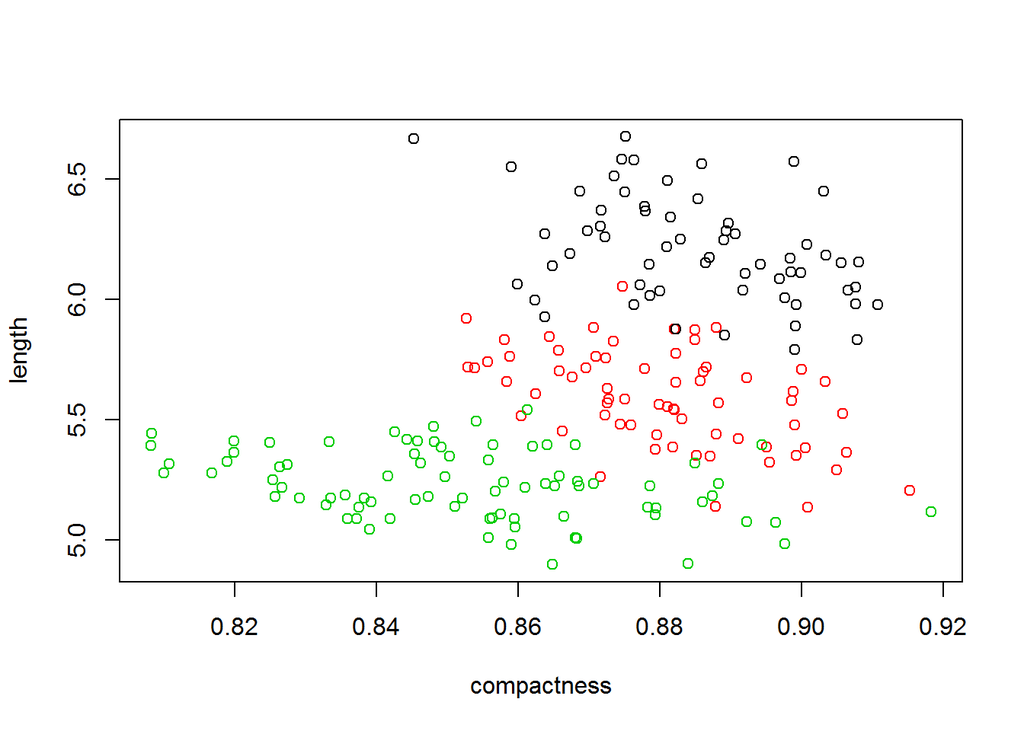

```r
# Group the seeds in three clusters
km_seeds <- kmeans(seeds[,-8], 3)

# Color the points in the plot based on the clusters
plot(length ~ compactness, data = seeds, col=km_seeds$cluster)
```

```r
# Print out the ratio of the WSS to the BSS
with(km_seeds, tot.withinss / betweenss)
```

```
## [1] 0.2762846
```

```r
# Shuffle the dataset, call the result shuffled
n <- nrow(titanic)
shuffled <- titanic[sample(n),]

# Split the data in train and test
train_indices <- 1:round(0.7*n)
train <- shuffled[train_indices, ]
test <- shuffled[-train_indices, ]

# Print the structure of train and test
str(train)
```

```
## 'data.frame':    500 obs. of  4 variables:
##  $ Survived: Factor w/ 2 levels "1","0": 2 2 2 2 2 2 1 1 1 1 ...
##  $ Pclass  : int  3 2 3 3 3 3 1 3 1 3 ...
##  $ Sex     : Factor w/ 2 levels "female","male": 2 2 2 1 2 2 1 2 2 1 ...
##  $ Age     : num  17 25 25 2 2 70.5 33 29 36 5 ...
##  - attr(*, "na.action")=Class 'omit'  Named int [1:177] 6 18 20 27 29 30 32 33 37 43 ...
##   .. ..- attr(*, "names")= chr [1:177] "6" "18" "20" "27" ...
```

```r
str(test)
```

```
## 'data.frame':    214 obs. of  4 variables:
##  $ Survived: Factor w/ 2 levels "1","0": 2 1 2 2 2 2 2 2 1 1 ...
##  $ Pclass  : int  1 3 3 3 2 3 1 2 3 3 ...
##  $ Sex     : Factor w/ 2 levels "female","male": 1 2 2 1 2 1 2 2 2 2 ...
##  $ Age     : num  2 29 32 14 31 18 37 36.5 21 32 ...
##  - attr(*, "na.action")=Class 'omit'  Named int [1:177] 6 18 20 27 29 30 32 33 37 43 ...
##   .. ..- attr(*, "names")= chr [1:177] "6" "18" "20" "27" ...
```

```r
# Fill in the model that has been learned.
tree <- rpart::rpart(Survived ~ ., data=train, method = "class")

# Predict the outcome on the test set with tree: pred
pred <- predict(tree, newdata=test, type="class")

# Calculate the confusion matrix: conf
(conf <- table(test$Survived, pred))
```

```
##    pred
##      1  0
##   1 62 32
##   0 21 99
```

```r
# Initialize the accs vector
accs <- rep(0,6)

for (i in 1:6) {
  # These indices indicate the interval of the test set
  indices <- (((i-1) * round((1/6)*nrow(shuffled))) + 1):((i*round((1/6) * nrow(shuffled))))

  # Exclude them from the train set
  train <- shuffled[-indices,]

  # Include them in the test set
  test <- shuffled[indices,]

  # A model is learned using each training set
  tree <- rpart::rpart(Survived ~ ., train, method = "class")

  # Make a prediction on the test set using tree
  pred <- predict(tree, newdata=test, type="class")

  # Assign the confusion matrix to conf
  conf <- table(test$Survived, pred)

  # Assign the accuracy of this model to the ith index in accs
  accs[i] <- sum(diag(conf))/sum(conf)
}

# Print out the mean of accs
mean(accs)
```

```
## [1] 0.7955182
```

```r
data(spam, package="kernlab")
str(spam)
```

```
## 'data.frame':    4601 obs. of  58 variables:
##  $ make             : num  0 0.21 0.06 0 0 0 0 0 0.15 0.06 ...
##  $ address          : num  0.64 0.28 0 0 0 0 0 0 0 0.12 ...
##  $ all              : num  0.64 0.5 0.71 0 0 0 0 0 0.46 0.77 ...
##  $ num3d            : num  0 0 0 0 0 0 0 0 0 0 ...
##  $ our              : num  0.32 0.14 1.23 0.63 0.63 1.85 1.92 1.88 0.61 0.19 ...
##  $ over             : num  0 0.28 0.19 0 0 0 0 0 0 0.32 ...
##  $ remove           : num  0 0.21 0.19 0.31 0.31 0 0 0 0.3 0.38 ...
##  $ internet         : num  0 0.07 0.12 0.63 0.63 1.85 0 1.88 0 0 ...
##  $ order            : num  0 0 0.64 0.31 0.31 0 0 0 0.92 0.06 ...
##  $ mail             : num  0 0.94 0.25 0.63 0.63 0 0.64 0 0.76 0 ...
##  $ receive          : num  0 0.21 0.38 0.31 0.31 0 0.96 0 0.76 0 ...
##  $ will             : num  0.64 0.79 0.45 0.31 0.31 0 1.28 0 0.92 0.64 ...
##  $ people           : num  0 0.65 0.12 0.31 0.31 0 0 0 0 0.25 ...
##  $ report           : num  0 0.21 0 0 0 0 0 0 0 0 ...
```

[output cut: 44 more lines]

```r
emails_full <- spam %>%
    select(capitalAve, type) %>%
    mutate(avg_capital_seq=capitalAve, spam=factor(as.integer(type)-1, levels=c(1, 0))) %>%
    select(avg_capital_seq, spam)
str(emails_full)
```

```
## 'data.frame':    4601 obs. of  2 variables:
##  $ avg_capital_seq: num  3.76 5.11 9.82 3.54 3.54 ...
##  $ spam           : Factor w/ 2 levels "1","0": 1 1 1 1 1 1 1 1 1 1 ...
```

```r
# The spam filter that has been 'learned' for you
spam_classifier <- function(x){
  prediction <- rep(NA, length(x)) # initialize prediction vector
  prediction[x > 4] <- 1
  prediction[x >= 3 & x <= 4] <- 0
  prediction[x >= 2.2 & x < 3] <- 1
  prediction[x >= 1.4 & x < 2.2] <- 0
  prediction[x > 1.25 & x < 1.4] <- 1
  prediction[x <= 1.25] <- 0
  return(factor(prediction, levels = c("1", "0"))) # prediction is either 0 or 1
}

# Apply spam_classifier to emails_full: pred_full
pred_full <- spam_classifier(emails_full$avg_capital_seq)

# Build confusion matrix for emails_full: conf_full
conf_full <- table(emails_full$spam, pred_full)

# Calculate the accuracy with conf_full: acc_full
(acc_full <- sum(diag(conf_full)) / sum(conf_full))
```

```
## [1] 0.6561617
```

```r
emails_small <- data.frame(avg_capital_seq=c( 1, 2.112, 4.123, 1.863, 2.973, 1.687, 5.891,
                                              3.167, 1.23, 2.441, 3.555, 3.25, 1.333
                                              ),
                           spam=factor(c(0, 0, 1, 0, 1, 0, 1, 0, 0, 1, 0, 0, 1), levels=c(1, 0))
                           )
str(emails_small)
```

```
## 'data.frame':    13 obs. of  2 variables:
##  $ avg_capital_seq: num  1 2.11 4.12 1.86 2.97 ...
##  $ spam           : Factor w/ 2 levels "1","0": 2 2 1 2 1 2 1 2 2 1 ...
```

```r
spam_classifier <- function(x){
  prediction <- rep(NA, length(x))
  prediction[x > 4] <- 1
  prediction[x <= 4] <- 0
  return(factor(prediction, levels = c("1", "0")))
}

# conf_small and acc_small have been calculated for you
conf_small <- table(emails_small$spam, spam_classifier(emails_small$avg_capital_seq))
acc_small <- sum(diag(conf_small)) / sum(conf_small)
acc_small
```

```
## [1] 0.7692308
```

```r
# Apply spam_classifier to emails_full and calculate the confusion matrix: conf_full
conf_full <- table(emails_full$spam, spam_classifier(emails_full$avg_capital_seq))

# Calculate acc_full
(acc_full <- sum(diag(conf_full)) / sum(conf_full))
```

```
## [1] 0.7259291
```

Chapter 3 - Classification

Decision trees - assign class to an unseen observation (each observation consists of a vector of features, and a classification):

K-nearest-neighbors (knn) - an example of “instance based learning”:

- Instance-based learning saves the training set in memory, and then compares the unseen instances to the training set
- The simplest form is to run k-nearest-neighbors with k=1, aka “nearest neighbor” using Euclidean distance on the standardized variables
  - With greater k, find the k-nearest neighbors and use plurality/majority voting to select a prediction
  - Can also use the Manhattan distances rather than Euclidean distances, which is to say sum(abs(a(i)-b(i)) rather than sqrt( sum( (a(i) - b(i))^2 )
  - Caution to have normalized/standardized all the inputs to avoid the scaling/units problem; transfrom both the train and test data the same
- Categorical features with n-categories should typically be split in to either n OR n-1 dummy variables (the n-1 will always work better - is required actually - for non-singular regression matrix on the same data)

ROC curve - Receiver Operator Characteristic curve - is a powerful performance measure for binary classification:

- Key idea is to use a probability threshhold to make the binary classification (need not be simple majority; could require strong-majority or even sizable-minority to declare as positive)
- Key Ratio 1: True Positive Rate = Recall = TP / (TP + FN) # of all the patients that are actually sick, what percentage do I correctly flag as sick?
- Key Ratio 2: False Positive Rate = FP / (FP + TN) # of all the patients that are actually NOT sick, what percentage do I INCORRECTLY flag as sick?
- For the ROC curve, the FPR is on the horizontal axis while the TPR is on the vertical axis
  - Curve can be drawn based on the output probabilities from the classifier, using various threshholds to get an associate (FPR, TPR) for the graph
- Interpreting the curve - the closer to the upper-left corner (TPR=1, FPR=0), the better
  - Area Under Curve (AUC) of 0.9+ is generally an excellent classifier

Example code includes:

```r
titanic <- titanic_train %>%
    select(Survived, Pclass, Sex, Age) %>%
    mutate(Survived=factor(Survived, levels=c(1, 0)), Sex=factor(Sex), Pclass=factor(Pclass)) %>%
    na.omit()

trIdx <- sample(x=1:nrow(titanic), size=round(.7*nrow(titanic)), replace=FALSE)
train <- titanic[trIdx, ]
test <- titanic[-trIdx, ]
str(train); str(test)
```

```
## 'data.frame':    500 obs. of  4 variables:
##  $ Survived: Factor w/ 2 levels "1","0": 2 2 1 1 1 2 2 1 2 2 ...
##  $ Pclass  : Factor w/ 3 levels "1","2","3": 2 3 2 1 1 2 3 3 3 3 ...
##  $ Sex     : Factor w/ 2 levels "female","male": 2 2 2 1 1 2 2 1 2 2 ...
##  $ Age     : num  36 25 62 15 21 57 19 35 31 38 ...
##  - attr(*, "na.action")=Class 'omit'  Named int [1:177] 6 18 20 27 29 30 32 33 37 43 ...
##   .. ..- attr(*, "names")= chr [1:177] "6" "18" "20" "27" ...
```

```
## 'data.frame':    214 obs. of  4 variables:
##  $ Survived: Factor w/ 2 levels "1","0": 1 2 1 1 1 2 1 1 1 2 ...
##  $ Pclass  : Factor w/ 3 levels "1","2","3": 1 1 3 3 1 3 2 2 1 1 ...
##  $ Sex     : Factor w/ 2 levels "female","male": 1 2 1 1 1 1 1 2 2 2 ...
##  $ Age     : num  35 54 27 4 58 14 55 34 28 40 ...
##  - attr(*, "na.action")=Class 'omit'  Named int [1:177] 6 18 20 27 29 30 32 33 37 43 ...
##   .. ..- attr(*, "names")= chr [1:177] "6" "18" "20" "27" ...
```

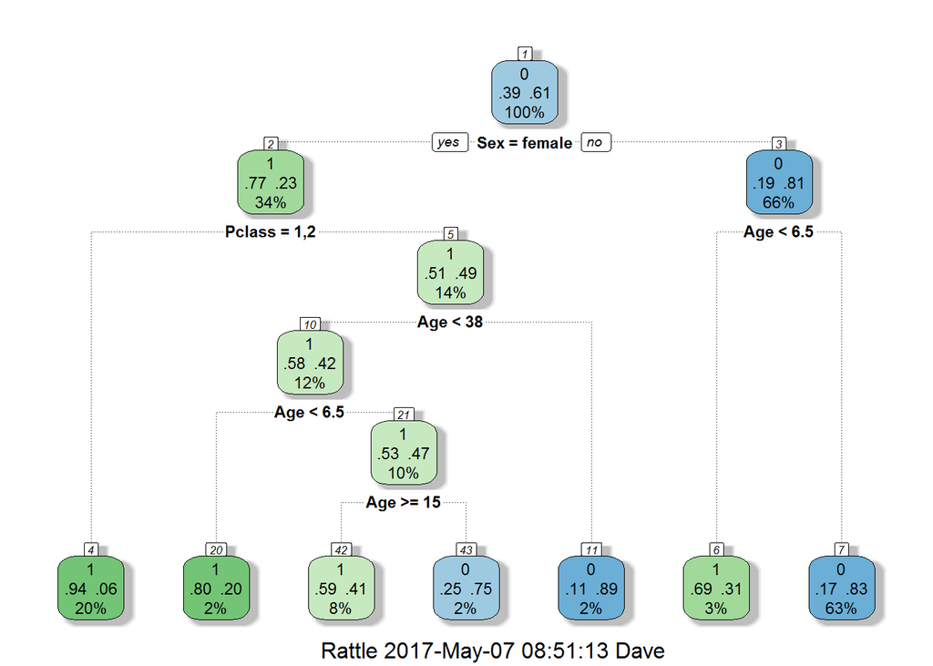

```r
# Fill in the ___, build a tree model: tree
tree <- rpart::rpart(Survived ~ ., data=train, method="class")

# Draw the decision tree
rattle::fancyRpartPlot(tree)
```

```r
# Predict the values of the test set: pred
pred <- predict(tree, newdata=test, type="class")

# Construct the confusion matrix: conf
(conf <- table(test$Survived, pred))
```

```
##    pred
##      1  0
##   1 71 24
##   0 22 97
```

```r
# Print out the accuracy
sum(diag(conf)) / sum(conf)
```

```
## [1] 0.7850467
```

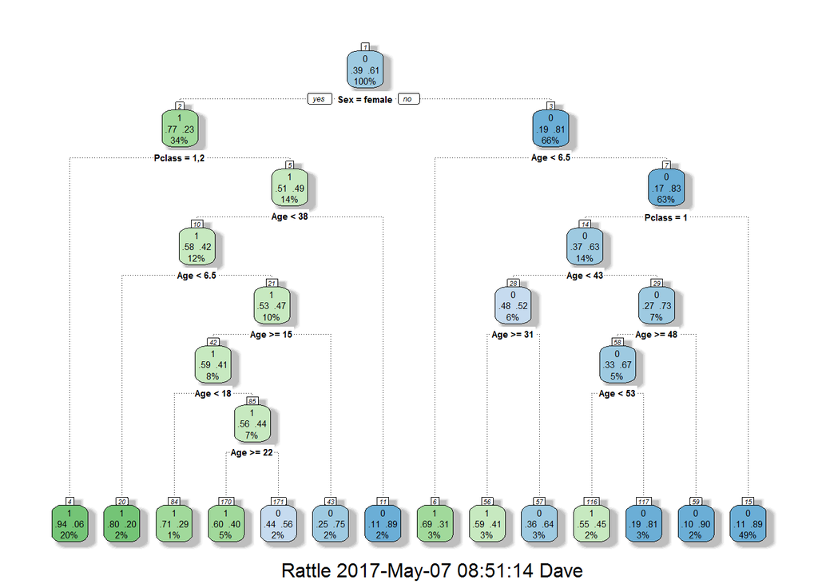

```r
# Calculation of a complex tree
tree <- rpart::rpart(Survived ~ ., train, method = "class", control = rpart::rpart.control(cp=0.00001))

# Draw the complex tree
rattle::fancyRpartPlot(tree)
```

[figure not shown]

```r
# Prune the tree: pruned
pruned <- rpart::prune(tree, cp=0.01)

# Draw pruned
rattle::fancyRpartPlot(pruned)
```

```r
data(spam, package="kernlab")
spam <- spam %>%
    mutate(spam=as.integer(type)-1L) %>%
    select(-type)
str(spam)
```

```
## 'data.frame':    4601 obs. of  58 variables:
##  $ make             : num  0 0.21 0.06 0 0 0 0 0 0.15 0.06 ...
##  $ address          : num  0.64 0.28 0 0 0 0 0 0 0 0.12 ...
##  $ all              : num  0.64 0.5 0.71 0 0 0 0 0 0.46 0.77 ...
##  $ num3d            : num  0 0 0 0 0 0 0 0 0 0 ...
##  $ our              : num  0.32 0.14 1.23 0.63 0.63 1.85 1.92 1.88 0.61 0.19 ...
##  $ over             : num  0 0.28 0.19 0 0 0 0 0 0 0.32 ...
##  $ remove           : num  0 0.21 0.19 0.31 0.31 0 0 0 0.3 0.38 ...
##  $ internet         : num  0 0.07 0.12 0.63 0.63 1.85 0 1.88 0 0 ...
##  $ order            : num  0 0 0.64 0.31 0.31 0 0 0 0.92 0.06 ...
##  $ mail             : num  0 0.94 0.25 0.63 0.63 0 0.64 0 0.76 0 ...
##  $ receive          : num  0 0.21 0.38 0.31 0.31 0 0.96 0 0.76 0 ...
##  $ will             : num  0.64 0.79 0.45 0.31 0.31 0 1.28 0 0.92 0.64 ...
##  $ people           : num  0 0.65 0.12 0.31 0.31 0 0 0 0 0.25 ...
##  $ report           : num  0 0.21 0 0 0 0 0 0 0 0 ...
```

[output cut: 44 more lines]

```r
idxTrain <- sample(x=1:nrow(spam), size=round(.7*nrow(spam)), replace=FALSE)
train <- spam[idxTrain, ]
test <- spam[-idxTrain, ]
dim(train); dim(test)
```

```
## [1] 3221   58
```

```
## [1] 1380   58
```

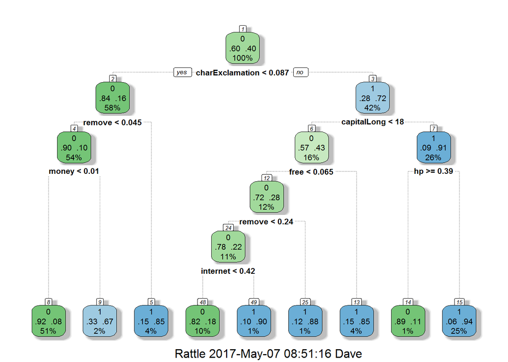

```r
# Train and test tree with gini criterion
tree_g <- rpart::rpart(spam ~ ., train, method = "class")
pred_g <- predict(tree_g, test, type = "class")
conf_g <- table(test$spam, pred_g)
acc_g <- sum(diag(conf_g)) / sum(conf_g)

# Change the first line of code to use information gain as splitting criterion
tree_i <- rpart::rpart(spam ~ ., train, method = "class", parms = list(split = "information"))
pred_i <- predict(tree_i, test, type = "class")
conf_i <- table(test$spam, pred_i)
acc_i <- sum(diag(conf_i)) / sum(conf_i)

# Draw a fancy plot of both tree_g and tree_i
rattle::fancyRpartPlot(tree_g)
```

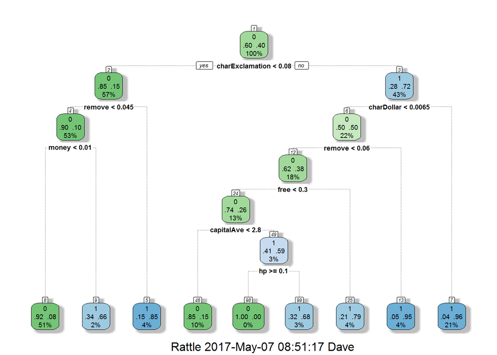

```r
rattle::fancyRpartPlot(tree_i)
```

```r
# Print out acc_g and acc_i
acc_g
```

```
## [1] 0.8869565
```

```r
acc_i
```

```
## [1] 0.8971014
```

```r
# Shuffle the dataset, call the result shuffled
titanic <- titanic_train %>%
    select(Survived, Pclass, Sex, Age) %>%
    mutate(Survived=factor(Survived, levels=c(1, 0)), Sex=as.integer(factor(Sex))-1L) %>%
    na.omit()
n <- nrow(titanic)
shuffled <- titanic[sample(n),]

# Split the data in train and test
train_indices <- 1:round(0.7*n)
train <- shuffled[train_indices, ]
test <- shuffled[-train_indices, ]

# Print the structure of train and test
str(train)
```

```
## 'data.frame':    500 obs. of  4 variables:
##  $ Survived: Factor w/ 2 levels "1","0": 2 1 1 1 2 2 1 1 1 2 ...
##  $ Pclass  : int  3 1 1 1 3 3 2 2 1 3 ...
##  $ Sex     : int  0 1 0 1 1 1 0 1 1 1 ...
##  $ Age     : num  2 26 43 27 19 36 41 19 25 28 ...
##  - attr(*, "na.action")=Class 'omit'  Named int [1:177] 6 18 20 27 29 30 32 33 37 43 ...
##   .. ..- attr(*, "names")= chr [1:177] "6" "18" "20" "27" ...
```

```r
str(test)
```

```
## 'data.frame':    214 obs. of  4 variables:
##  $ Survived: Factor w/ 2 levels "1","0": 1 2 2 2 2 1 1 2 2 2 ...
##  $ Pclass  : int  2 3 2 3 2 2 1 3 3 2 ...
##  $ Sex     : int  0 1 1 1 1 0 0 1 1 1 ...
##  $ Age     : num  28 17 34 28 29 36 19 22 25 30 ...
##  - attr(*, "na.action")=Class 'omit'  Named int [1:177] 6 18 20 27 29 30 32 33 37 43 ...
##   .. ..- attr(*, "names")= chr [1:177] "6" "18" "20" "27" ...
```

```r
# Store the Survived column of train and test in train_labels and test_labels
train_labels <- train$Survived
test_labels <- test$Survived

# Copy train and test to knn_train and knn_test
knn_train <- train
knn_test <- test

# Drop Survived column for knn_train and knn_test
knn_train$Survived <- NULL
knn_test$Survived <- NULL

# Normalize Pclass
min_class <- min(knn_train$Pclass)
max_class <- max(knn_train$Pclass)
knn_train$Pclass <- (knn_train$Pclass - min_class) / (max_class - min_class)
knn_test$Pclass <- (knn_test$Pclass - min_class) / (max_class - min_class)

# Normalize Age
min_age <- min(knn_train$Age)
max_age <- max(knn_train$Age)
knn_train$Age <- (knn_train$Age - min_age) / (max_age - min_age)
knn_test$Age <- (knn_test$Age - min_age) / (max_age - min_age)


# Fill in the ___, make predictions using knn: pred
pred <- class::knn(train = knn_train, test = knn_test, cl = train_labels, k = 5)

# Construct the confusion matrix: conf
(conf <- table(test_labels, pred))
```

```
##            pred
## test_labels   1   0
##           1  60  28
##           0  12 114
```

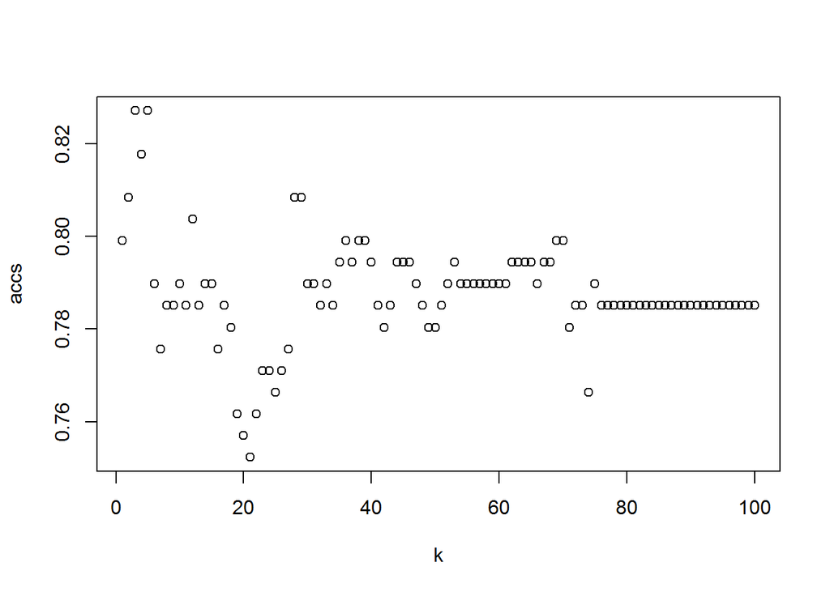

```r
range <- 1:round(0.2 * nrow(knn_train))
accs <- rep(0, length(range))

for (k in range) {

  # Fill in the ___, make predictions using knn: pred
  pred <- class::knn(knn_train, knn_test, cl=train_labels, k = k)

  # Fill in the ___, construct the confusion matrix: conf
  conf <- table(test_labels, pred)

  # Fill in the ___, calculate the accuracy and store it in accs[k]
  accs[k] <- sum(diag(conf)) / sum(conf)
}

# Plot the accuracies. Title of x-axis is "k".
plot(range, accs, xlab = "k")
```

```r
# Calculate the best k
which.max(accs)
```

```
## [1] 3
```

```r
# CAUTION - DO NOT HAVE THIS DATA, though UCIMLR (Census + Income) is the SOURCE
# test should be 9215 x 14 while train should be 21503 x 14
# income is the key variable, with 1 meaning > $50,000 while 0 meaning otherwise


# Build a tree on the training set: tree
# tree <- rpart::rpart(income ~ ., train, method = "class")

# Predict probability values using the model: all_probs
# all_probs <- predict(tree, newdata=test, type="prob")

# Print out all_probs
# str(all_probs)

# Select second column of all_probs: probs
# probs <- all_probs[, 2]


# Make a prediction object: pred
# pred <- ROCR::prediction(probs, test$income)

# Make a performance object: perf
# perf <- ROCR::performance(pred, "tpr", "fpr")

# Plot this curve
# plot(perf)

# Make a performance object: perf
# perf <- ROCR::performance(pred, "auc")

# Print out the AUC
# perf@y.values[[1]]


# EVEN MORE DATA THAT I DO NOT HAVE

draw_roc_lines <- function(tree, knn) {
  if (!(class(tree)== "performance" && class(knn) == "performance") ||
      !(attr(class(tree),"package") == "ROCR" && attr(class(knn),"package") == "ROCR")) {
    stop("This predefined function needs two performance objects as arguments.")
  } else if (length(tree@x.values) == 0 | length(knn@x.values) == 0) {
    stop('This predefined function needs the right kind of performance objects as arguments. Are you sure you are creating both objects with arguments "tpr" and  "fpr"?')
  } else {
    plot(0,0,
         type = "n",
         main = "ROC Curves",
         ylab = "True positive rate",
         xlab = "False positive rate",
         ylim = c(0,1),
         xlim = c(0,1))
    lines(tree@x.values[[1]], tree@y.values[[1]], type = "l", lwd = 2, col = "red")
    lines(knn@x.values[[1]], knn@y.values[[1]], type = "l", lwd = 2, col = "green")
    legend("bottomright", c("DT","KNN"), lty=c(1,1),lwd=c(2.5,2.5),col=c("red","green"))
  }
}

# Make the prediction objects for both models: pred_t, pred_k
# pred_t <- ROCR::prediction(probs_t, test$spam)
# pred_k <- ROCR::prediction(probs_k, test$spam)

# Make the performance objects for both models: perf_t, perf_k
# perf_t <- ROCR::performance(pred_t, "tpr", "fpr")
# perf_k <- ROCR::performance(pred_k, "tpr", "fpr")

# Draw the ROC lines using draw_roc_lines()
# draw_roc_lines(perf_t, perf_k)
```

Chapter 4 - Regression

Simple, Linear Regression - estimated an actual value rather than the class of an observation:

- In the “simple” version, there is only a single predictor variable; the “linear” assumption can be challenging to justify sometimes (scatterplot to check)
- Y = Beta-0 + Beta-1 * X-1 + epsilon (noise, assumed to have mean=0 and variance=sigma-squared)
  - Goal is to minimize the sum of the residuals-squared
- y-hat, Beta-0-hat, and Beta-1-hat are the predicted values, and include CI, prediction intervals, and the like
- RMSE (root mean square error) has both units and scales, which can create interpretation challenges
  - SSE (sum-squared errors) = sum[ (y-hat - y)^2 ] ; SST (sum-squared total) - sum[ (y - y-bar)^2 ]
  - R-squared = 1 - (SSE/SST) and is the fraction of the variance explained by the model

Multivariable Linear Regression - combining several predictors all in a single model:

k-Nearest-Neighbors and Generalization - solution to problem of not knowing what transformations to use:

- Non-parametric regression (no parameters or transforms needed) includes areas like k-Nearest-Neighbors, Kernel Regression, Regression Trees, and the like
- The kNN regression comes in handy when you cannot describe the relationship; caution that a well-built linear model will do a “far better job” of predicting an actual linear relationship, though!
  - To best manage bias-variance, the best value of k is often ~20% of the number of observations in the training set
- Additional question for any regression model (linear, transformed, non-parametric, etc.) is how well does it generalize to unseen data?
  - Similar idea of maintaining a hold-out sample - RMSE for the test set is generally the most important, and for a well-generalized model should be close to RMSE for the training set

Example code includes:

```r
kang_nose <- data.frame(nose_width=c( 241, 222, 233, 207, 247, 189, 226, 240, 215, 231, 263, 220, 271, 284, 279, 272, 268, 278, 238, 255, 308, 281, 288, 306, 236, 204, 216, 225, 220, 219, 201, 213, 228, 234, 237, 217, 211, 238, 221, 281, 292, 251, 231, 275, 275 ) ,
                        nose_length=c( 609, 629, 620, 564, 645, 493, 606, 660, 630, 672, 778, 616, 727, 810, 778, 823, 755, 710, 701, 803, 855, 838, 830, 864, 635, 565, 562, 580, 596, 597, 636, 559, 615, 740, 677, 675, 629, 692, 710, 730, 763, 686, 717, 737, 816 )
                        )
str(kang_nose)
```

```
## 'data.frame':    45 obs. of  2 variables:
##  $ nose_width : num  241 222 233 207 247 189 226 240 215 231 ...
##  $ nose_length: num  609 629 620 564 645 493 606 660 630 672 ...
```

```r
nose_width_new <- data.frame(nose_width=250)

# Plot nose length as function of nose width.
plot(kang_nose, xlab = "nose width", ylab = "nose length")

# Fill in the ___, describe the linear relationship between the two variables: lm_kang
lm_kang <- lm(nose_length ~ nose_width, data = kang_nose)

# Print the coefficients of lm_kang
lm_kang$coefficients
```

```
## (Intercept)  nose_width
##   27.893058    2.701175
```

```r
# Predict and print the nose length of the escaped kangoroo
predict(lm_kang, newdata=nose_width_new)
```

```
##        1
## 703.1869
```

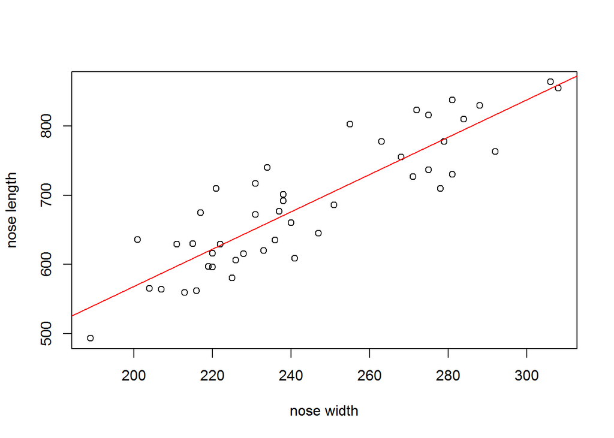

```r
# Build model and make plot
lm_kang <- lm(nose_length ~ nose_width, data=kang_nose)
plot(kang_nose, xlab = "nose width", ylab = "nose length")
abline(lm_kang$coefficients, col = "red")
```

```r
# Apply predict() to lm_kang: nose_length_est
nose_length_est <- predict(lm_kang)

# Calculate difference between the predicted and the true values: res
res <- (kang_nose$nose_length - nose_length_est)

# Calculate RMSE, assign it to rmse and print it
(rmse <- sqrt( mean( res^2 ) ))
```

```
## [1] 43.26288
```

```r
# Calculate the residual sum of squares: ss_res
ss_res <- sum(res^2)

# Determine the total sum of squares: ss_tot
ss_tot <- sum( (kang_nose$nose_length - mean(kang_nose$nose_length))^2 )

# Calculate R-squared and assign it to r_sq. Also print it.
(r_sq <- 1 - ss_res / ss_tot)
```

```
## [1] 0.7768914
```

```r
# Apply summary() to lm_kang
summary(lm_kang)
```

```
##
## Call:
## lm(formula = nose_length ~ nose_width, data = kang_nose)
##
## Residuals:
##     Min      1Q  Median      3Q     Max
## -69.876 -32.912  -4.855  30.227  86.307
##
## Coefficients:
##             Estimate Std. Error t value Pr(>|t|)
## (Intercept)  27.8931    54.2991   0.514     0.61
## nose_width    2.7012     0.2207  12.236 1.34e-15 ***
## ---
## Signif. codes:  0 '***' 0.001 '**' 0.01 '*' 0.05 '.' 0.1 ' ' 1
##
## Residual standard error: 44.26 on 43 degrees of freedom
## Multiple R-squared:  0.7769, Adjusted R-squared:  0.7717
## F-statistic: 149.7 on 1 and 43 DF,  p-value: 1.342e-15
```

```r
cgdp <- c( 666.3, 5935.7, 4619.2, 7574.3, 3646.7, 13961.2, 51127.1, 7884.2, 295.1, 47516.5, 825.2, 720, 1096.6, 7712.8, 22245.5, 4796.2, 8040, 11612.5, 15199.3, 40776.3, 7757, 378.6, 7593.9, 1426.4, 7720, 860.8, 3715.3, 10035.4, 27194.4, 47627.4, 7433.9, 60634.4, 6222.5, 6850.3, 39567.9, 590.2, 30262.2, 567.8, 36317.8, 1555, 49541.3, 4543.3, 1461.6, 550, 422.8, 585.6, 21682.6, 8299.1, 3703, 37896.8, 2346.7, 13507.4, 13902.7, 3514.6, 53313.6, 6432.8, 52111, 34960.3, 36194.4, 1269.1, 1084.4, 1604.4, 15209.9, 27970.5, 9127.3, 1707.5, 10139.2, 6575.4, 7437, 10125.6, 944.4, 648.1, 3631, 2032.8, 4301.1, 995.5, 16037.8, 3140, 2233.8, 449.4, 8624.8, 8518.7, 10361.3, 4731.6, 5370.7, 765.7, 1197.5, 4333.3, 7370.9, 4170.2, 1270.2, 10005.6, 253, 54198.7, 440.7, 3184.6, 1913.6, 97363.1, 698.3, 38400.1, 4749, 1333.5, 11770.9, 6594.4, 2843.1, 11879.7, 14422.8, 22080.9, 4479.1, 3575.2, 93397.1, 9996.7, 12735.9, 652.1, 1541.1, 25409, 1904.2, 1070.9, 2021.7, 3950.7, 6152.9, 1781.1, 1113.4, 1692.4, 18416.5, 23962.6, 58887.3, 2682.3, 15359.2, 1053.8, 646.1, 9031.5, 1280.4, 4106.4, 998.1, 677.4, 3082.5, 7986.9, 16810.9, 6477.9, 475.2, 1801.9 )
urb_pop <- c( 26.3, 43.3, 56.4, 57.6, 62.8, 24.2, 65.9, 54.4, 11.8, 97.8, 43.5, 29, 33.5, 73.6, 82.8, 39.6, 76.3, 85.4, 31.6, 76.9, 57.2, 39.8, 54.4, 53.8, 76.2, 28.2, 64.8, 75.9, 67, 75.1, 69.3, 87.5, 51.9, 59.9, 75.7, 22.2, 79.4, 19, 74.6, 40.7, 84.1, 53.4, 53.4, 36.7, 59, 48.5, 77.7, 35.6, 51.1, 80.6, 54.1, 58.7, 70.8, 53, 63, 69.4, 94, 68.8, 93, 35.6, 20.5, 44.2, 32, 82.4, 77.7, 37.6, 87.7, 78.4, 18.5, 79.5, 30.9, 29.6, 18.3, 38.6, 47, 26.8, 67.4, 59.7, 44.9, 34.5, 44.5, 64.1, 79, 49.1, 57, 39.1, 33.6, 60.4, 63.8, 71.2, 59.3, 39.8, 16.1, 81.5, 18.5, 46.9, 58.5, 80.2, 18.2, 80, 48.6, 38.3, 66.3, 78.3, 44.5, 86.5, 60.6, 62.9, 59.4, 37.2, 99.2, 54.4, 73.9, 27.8, 32.6, 82.9, 33.6, 43.4, 21.9, 66.3, 55.5, 37.2, 18.6, 64.5, 53.8, 49.7, 85.7, 21.3, 53.6, 22.3, 39.5, 49.7, 32.1, 23.6, 30.9, 15.8, 69.5, 61.8, 95.2, 64.3, 42, 40.5 )
world_bank_train <- data.frame(urb_pop=urb_pop, cgdp=cgdp)
str(world_bank_train)
```

```
## 'data.frame':    142 obs. of  2 variables:
##  $ urb_pop: num  26.3 43.3 56.4 57.6 62.8 24.2 65.9 54.4 11.8 97.8 ...
##  $ cgdp   : num  666 5936 4619 7574 3647 ...
```

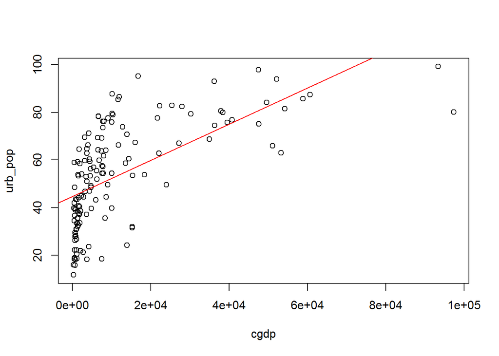

```r
cgdp_afg <- data.frame(cgdp=413)

# Plot urb_pop as function of cgdp
with(world_bank_train, plot(y=urb_pop, x=cgdp))

# Set up a linear model between the two variables: lm_wb
lm_wb <- lm(urb_pop ~ cgdp, data=world_bank_train)

# Add a red regression line to your scatter plot
abline(lm_wb$coefficients, col="red")
```

```r
# Summarize lm_wb and select R-squared
summary(lm_wb)$r.squared
```

```
## [1] 0.3822347
```

```r
# Predict the urban population of afghanistan based on cgdp_afg
predict(lm_wb, newdata=cgdp_afg)
```

```
##       1
## 45.0156
```

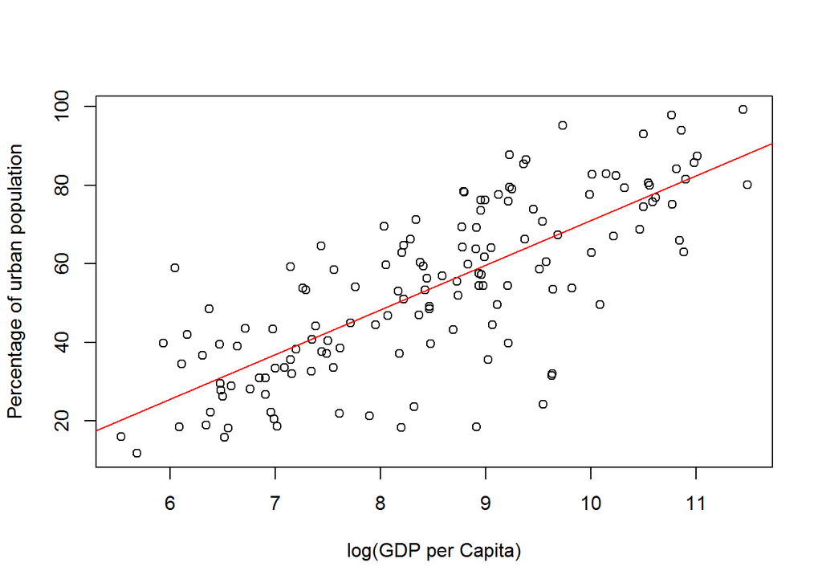

```r
# Plot: change the formula and xlab
plot(urb_pop ~ log(cgdp), data = world_bank_train,
     xlab = "log(GDP per Capita)",
     ylab = "Percentage of urban population")

# Linear model: change the formula
lm_wb <- lm(urb_pop ~ log(cgdp), data = world_bank_train)

# Add a red regression line to your scatter plot
abline(lm_wb$coefficients, col = "red")
```

```r
# Summarize lm_wb and select R-squared
summary(lm_wb)$r.squared
```

```
## [1] 0.5788284
```

```r
# Predict the urban population of afghanistan based on cgdp_afg
predict(lm_wb, newdata=cgdp_afg)
```

```
##        1
## 25.86829
```

```r
sales <- c( 231, 156, 10, 519, 437, 487, 299, 195, 20, 68, 570, 428, 464, 15, 65, 98, 398, 161, 397, 497, 528, 99, 0.5, 347, 341, 507, 400 )
sq_ft <- c( 3, 2.2, 0.5, 5.5, 4.4, 4.8, 3.1, 2.5, 1.2, 0.6, 5.4, 4.2, 4.7, 0.6, 1.2, 1.6, 4.3, 2.6, 3.8, 5.3, 5.6, 0.8, 1.1, 3.6, 3.5, 5.1, 8.6 )
inv <- c( 294, 232, 149, 600, 567, 571, 512, 347, 212, 102, 788, 577, 535, 163, 168, 151, 342, 196, 453, 518, 615, 278, 142, 461, 382, 590, 517 )
ads <- c( 8.2, 6.9, 3, 12, 10.6, 11.8, 8.1, 7.7, 3.3, 4.9, 17.4, 10.5, 11.3, 2.5, 4.7, 4.6, 5.5, 7.2, 10.4, 11.5, 12.3, 2.8, 3.1, 9.6, 9.8, 12, 7 )
size_dist <- c( 8.2, 4.1, 4.3, 16.1, 14.1, 12.7, 10.1, 8.4, 2.1, 4.7, 12.3, 14, 15, 2.5, 3.3, 2.7, 16, 6.3, 13.9, 16.3, 16, 6.5, 1.6, 11.3, 11.5, 15.7, 12 )
comp <- c( 11, 12, 15, 1, 5, 4, 10, 12, 15, 8, 1, 7, 3, 14, 11, 10, 4, 13, 7, 1, 0, 14, 12, 6, 5, 0, 8 )

shop_data <- data.frame(sales=sales, sq_ft=sq_ft, inv=inv, ads=ads,
                        size_dist=size_dist, comp=comp
                        )
str(shop_data)
```

```
## 'data.frame':    27 obs. of  6 variables:
##  $ sales    : num  231 156 10 519 437 487 299 195 20 68 ...
##  $ sq_ft    : num  3 2.2 0.5 5.5 4.4 4.8 3.1 2.5 1.2 0.6 ...
##  $ inv      : num  294 232 149 600 567 571 512 347 212 102 ...
##  $ ads      : num  8.2 6.9 3 12 10.6 11.8 8.1 7.7 3.3 4.9 ...
##  $ size_dist: num  8.2 4.1 4.3 16.1 14.1 12.7 10.1 8.4 2.1 4.7 ...
##  $ comp     : num  11 12 15 1 5 4 10 12 15 8 ...
```

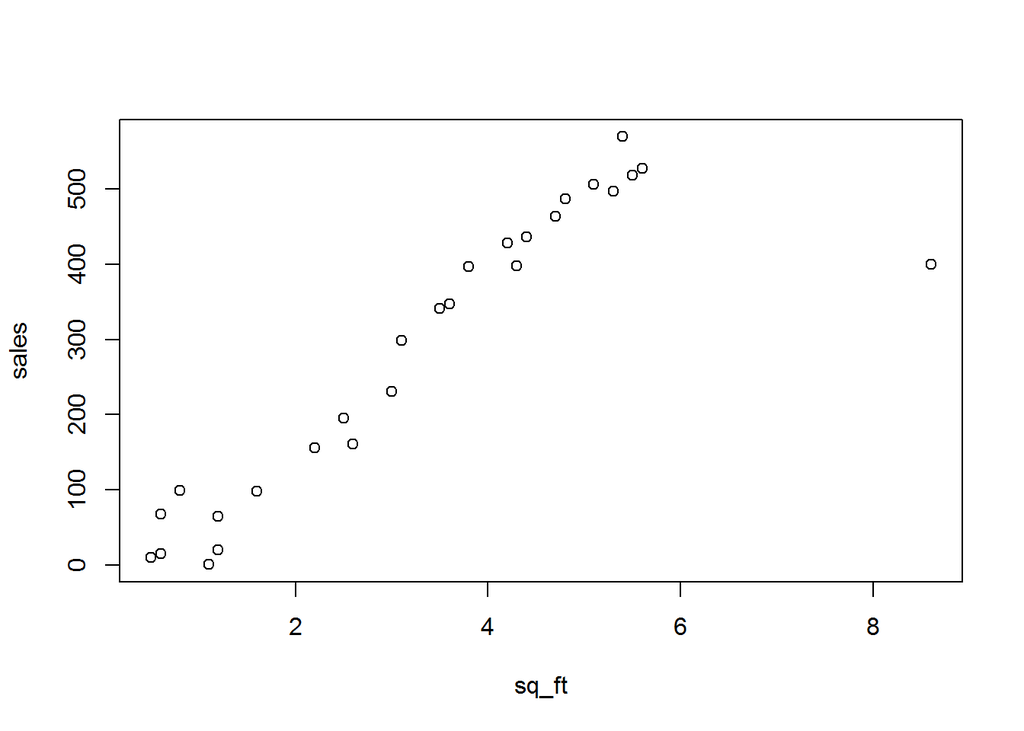

```r
shop_new <- data.frame(sq_ft=2.3, inv=420, ads=8.7, size_dist=9.1, comp=10)


# Add a plot: sales as a function of inventory. Is linearity plausible?
plot(sales ~ sq_ft, shop_data)
```

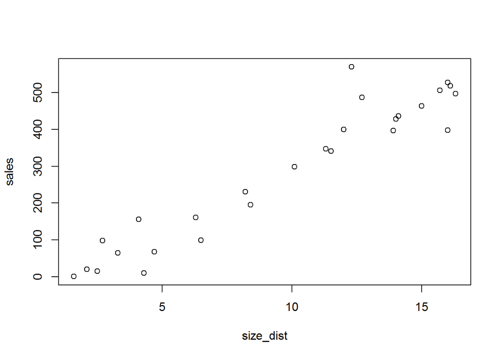

```r
plot(sales ~ size_dist, shop_data)
```

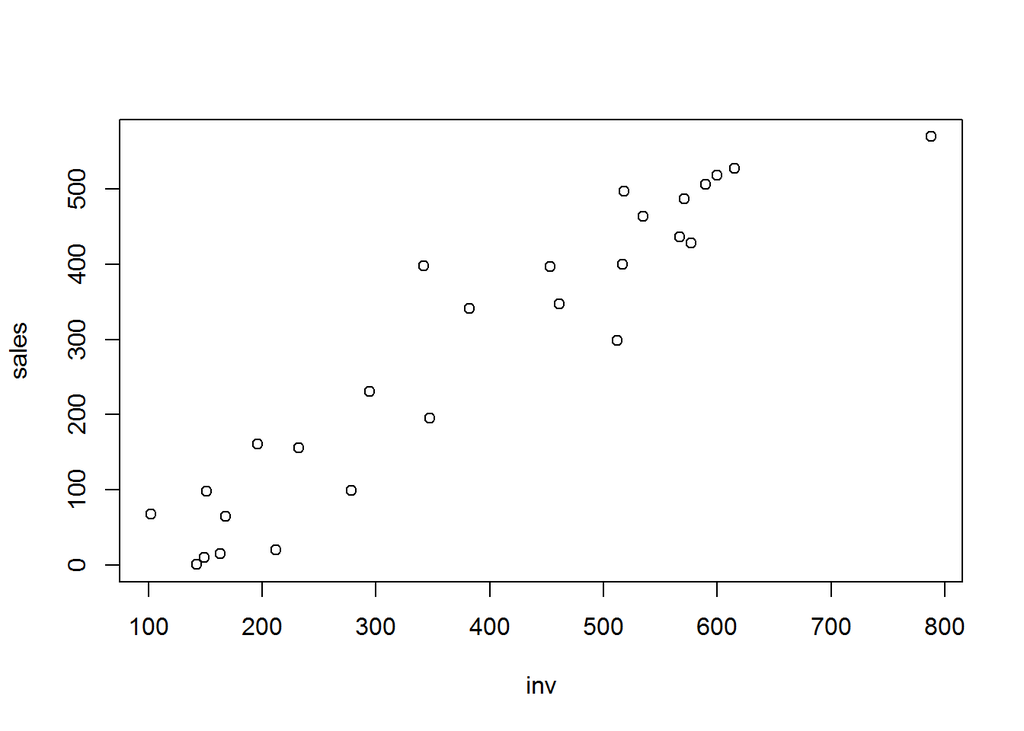

```r
plot(sales ~ inv, shop_data)
```

```r
# Build a linear model for net sales based on all other variables: lm_shop
lm_shop <- lm(sales ~ ., data=shop_data)

# Summarize lm_shop
summary(lm_shop)
```

```
##
## Call:
## lm(formula = sales ~ ., data = shop_data)
##
## Residuals:
##     Min      1Q  Median      3Q     Max
## -26.338  -9.699  -4.496   4.040  41.139
##
## Coefficients:
##              Estimate Std. Error t value Pr(>|t|)
## (Intercept) -18.85941   30.15023  -0.626 0.538372
## sq_ft        16.20157    3.54444   4.571 0.000166 ***
## inv           0.17464    0.05761   3.032 0.006347 **
## ads          11.52627    2.53210   4.552 0.000174 ***
## size_dist    13.58031    1.77046   7.671 1.61e-07 ***
## comp         -5.31097    1.70543  -3.114 0.005249 **
## ---
## Signif. codes:  0 '***' 0.001 '**' 0.01 '*' 0.05 '.' 0.1 ' ' 1
##
## Residual standard error: 17.65 on 21 degrees of freedom
## Multiple R-squared:  0.9932, Adjusted R-squared:  0.9916
## F-statistic: 611.6 on 5 and 21 DF,  p-value: < 2.2e-16
```

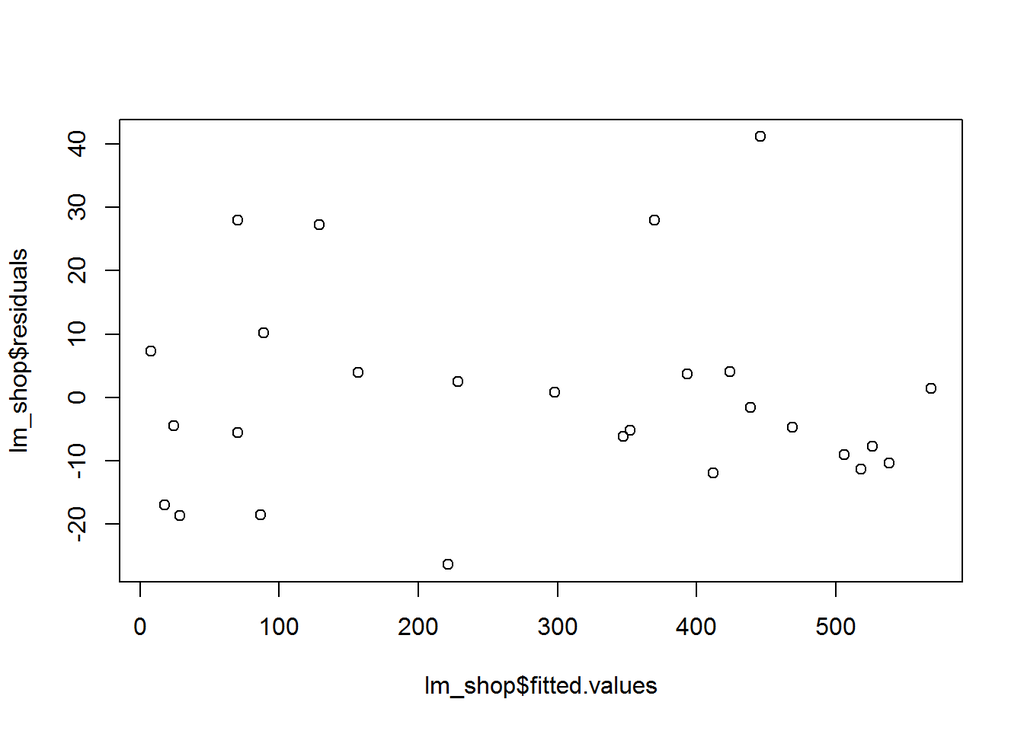

```r
# Plot the residuals in function of your fitted observations
plot(x=lm_shop$fitted.values, y=lm_shop$residuals)
```

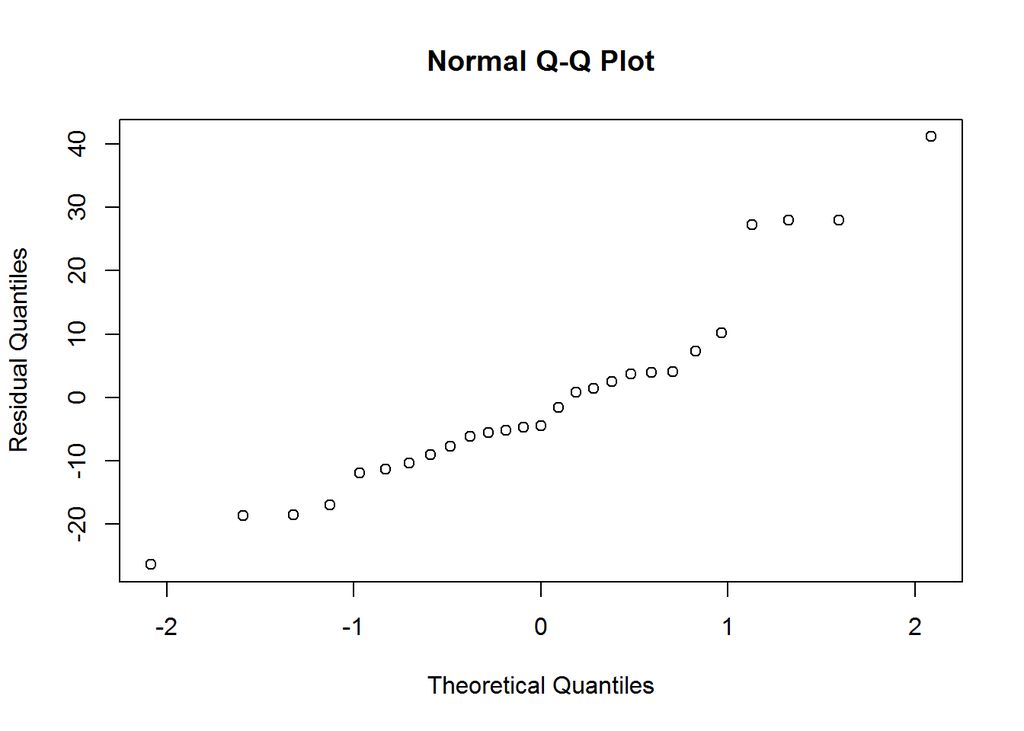

```r
# Make a Q-Q plot of your residual quantiles
qqnorm(lm_shop$residuals, ylab="Residual Quantiles")
```

```r
# Summarize your model, are there any irrelevant predictors?
summary(lm_shop)
```

```
##
## Call:
## lm(formula = sales ~ ., data = shop_data)
##
## Residuals:
##     Min      1Q  Median      3Q     Max
## -26.338  -9.699  -4.496   4.040  41.139
##
## Coefficients:
##              Estimate Std. Error t value Pr(>|t|)
## (Intercept) -18.85941   30.15023  -0.626 0.538372
## sq_ft        16.20157    3.54444   4.571 0.000166 ***
## inv           0.17464    0.05761   3.032 0.006347 **
## ads          11.52627    2.53210   4.552 0.000174 ***
## size_dist    13.58031    1.77046   7.671 1.61e-07 ***
## comp         -5.31097    1.70543  -3.114 0.005249 **
## ---
## Signif. codes:  0 '***' 0.001 '**' 0.01 '*' 0.05 '.' 0.1 ' ' 1
##
## Residual standard error: 17.65 on 21 degrees of freedom
## Multiple R-squared:  0.9932, Adjusted R-squared:  0.9916
## F-statistic: 611.6 on 5 and 21 DF,  p-value: < 2.2e-16
```

```r
# Predict the net sales based on shop_new.
predict(lm_shop, newdata=shop_new)
```

```
##        1
## 262.5006
```

```r
choco_data <- data.frame(
energy=c( 1970, 2003, 2057, 1920, 2250, 2186, 1930, 1980, 1890, 2030, 2180, 1623, 1640, 2210, 1980, 1970, 1877.4, 2021.4, 1840.1, 2272.1, 2047.3, 1843, 2075.2, 2119.8, 2090.9, 1934.3, 2257.3, 2057.9, 1878.2, 1595.3, 2188.3, 1980.4, 1985.9, 2156.5, 2134.6, 2094.2, 2151.7, 2127.7, 2001.9, 1635.2, 2098.9, 1978.6, 1961.2, 1727.2, 1903.7, 2062.6, 2230.1, 1970.5, 2057.4, 1979.2, 1744.1, 1914.9, 1918.7, 1978.1, 2184, 2124.4 ),
protein=c( 3.1, 4.6, 9.9, 5.1, 10.2, 7, 3.5, 7.2, 4.7, 5.6, 5.5, 2.2, 3.7, 8.2, 8.5, 5, 6.1, 4.6, 3.4, 10.5, 5.9, 3.2, 5.6, 7.5, 7.3, 5.4, 8.9, 6, 2.8, 3.4, 5.5, 7, 7.7, 8.9, 9.4, 7.5, 10.4, 5.6, 9.1, 2.9, 9.1, 4.7, 2.2, 2.3, 6.3, 6.7, 8.3, 6.3, 5.3, 7.8, 5.8, 7, 4.3, 6.9, 8.9, 5 ),
fat=c( 27.2, 26.5, 23, 18.4, 30.1, 28.4, 24.5, 22.9, 19.5, 20.4, 26.8, 9.2, 12, 29.8, 20.6, 20, 18, 22.3, 20.8, 27.7, 25.7, 18.3, 27.6, 25.8, 26.9, 21.6, 29.4, 27.8, 21.4, 12.9, 32.1, 24.4, 19.6, 26.6, 24.5, 24.6, 27.2, 26.1, 21.8, 12.2, 25, 26.7, 22, 16.5, 21.5, 29.6, 28.1, 20.8, 28.1, 21.2, 15.4, 19.9, 18.9, 21.9, 30.5, 25.1 ),
size=c( 50, 50, 40, 80, 45, 78, 55, 60, 60, 50, 40, 55, 44.5, 75, 60, 42.5, 52.3, 52.3, 63.1, 64.8, 46.9, 45, 60.7, 66.3, 54.7, 66.2, 62.6, 48, 58.8, 37.5, 75.4, 80.8, 50.6, 43.3, 63.9, 54.4, 87.6, 55.9, 64.3, 52.8, 46.7, 57.7, 31.8, 72, 56.6, 83.9, 63.4, 46, 63.7, 43.2, 37.2, 58.5, 49, 55.2, 57.9, 48.8 )
)
str(choco_data)
```

```
## 'data.frame':    56 obs. of  4 variables:
##  $ energy : num  1970 2003 2057 1920 2250 ...
##  $ protein: num  3.1 4.6 9.9 5.1 10.2 7 3.5 7.2 4.7 5.6 ...
##  $ fat    : num  27.2 26.5 23 18.4 30.1 28.4 24.5 22.9 19.5 20.4 ...
##  $ size   : num  50 50 40 80 45 78 55 60 60 50 ...
```

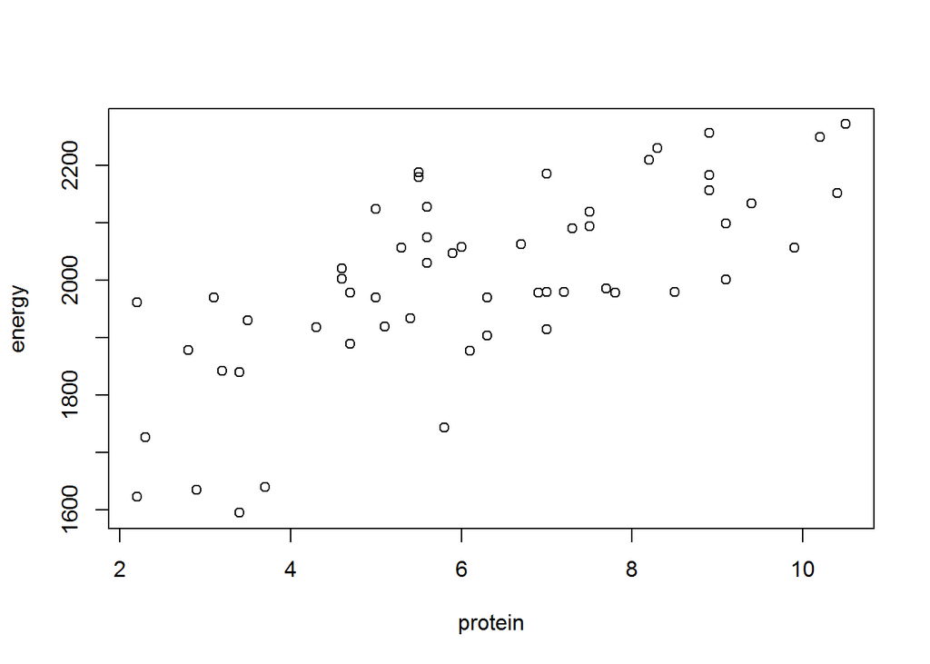

```r
# Add a plot:  energy/100g as function of total size. Linearity plausible?
plot(energy ~ protein, choco_data)
```

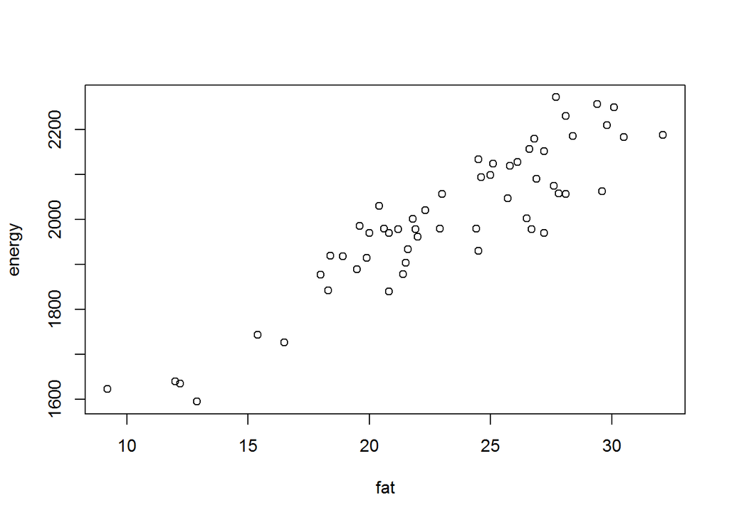

```r
plot(energy ~ fat, choco_data)
```

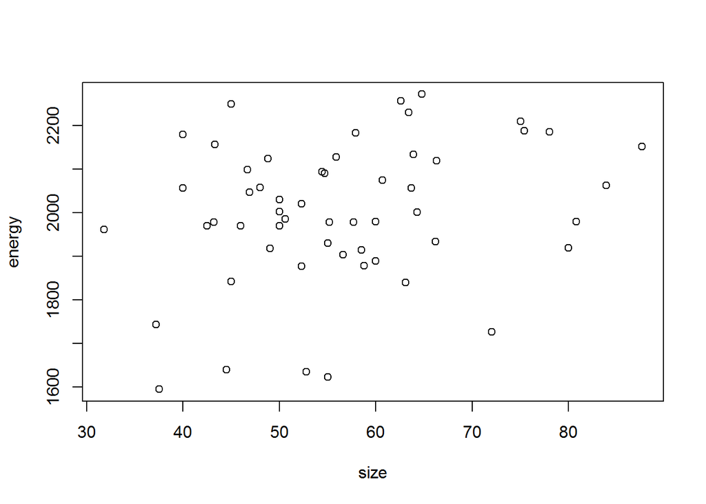

```r
plot(energy ~ size, choco_data)
```

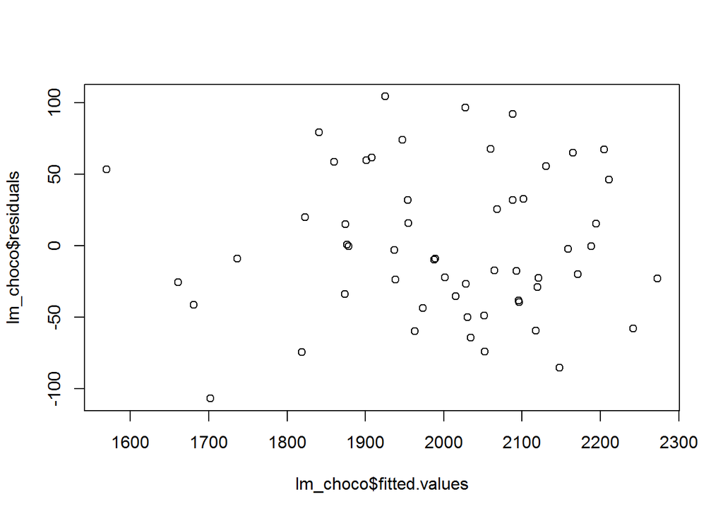

```r
# Build a linear model for the energy based on all other variables: lm_choco
lm_choco <- lm(energy ~ ., data=choco_data)

# Plot the residuals in function of your fitted observations
plot(x=lm_choco$fitted.values, y=lm_choco$residuals)
```

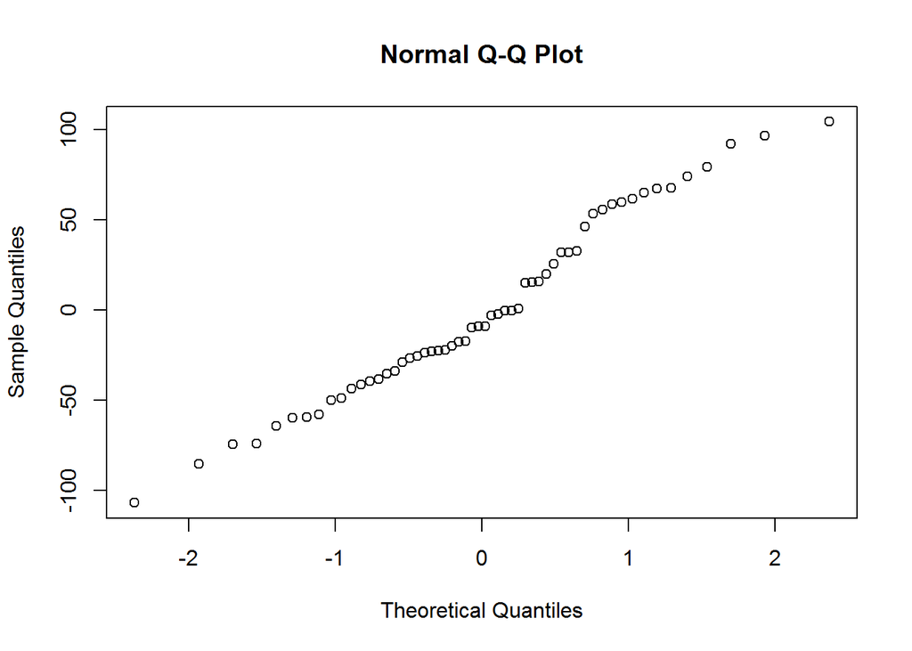

```r
# Make a Q-Q plot of your residual quantiles
qqnorm(lm_choco$residuals)
```

```r
# Summarize lm_choco
summary(lm_choco)
```

```
##
## Call:
## lm(formula = energy ~ ., data = choco_data)
##
## Residuals:
##      Min       1Q   Median       3Q      Max
## -106.680  -36.071   -9.062   36.079  104.361
##
## Coefficients:
##              Estimate Std. Error t value Pr(>|t|)
## (Intercept) 1339.2806    40.0195  33.466  < 2e-16 ***
## protein       23.0122     3.6565   6.293  6.6e-08 ***
## fat           24.4416     1.6839  14.515  < 2e-16 ***
## size          -0.8224     0.6026  -1.365    0.178
## ---
## Signif. codes:  0 '***' 0.001 '**' 0.01 '*' 0.05 '.' 0.1 ' ' 1
##
## Residual standard error: 52.14 on 52 degrees of freedom
## Multiple R-squared:  0.9021, Adjusted R-squared:  0.8965
## F-statistic: 159.8 on 3 and 52 DF,  p-value: < 2.2e-16
```

```r
world_bank_test <- data.frame(
cgdp=c( 18389.4, 1099, 2379.2, 5823.3, 3670, 788.4, 1646.4, 19553.9, 1630.8, 61887, 2965.9, 3436.3, 12276.4, 3150.5, 42736.2, 16529.7, 10067.5, 25592.4, 50271.1, 5422.6, 6290.8, 20832, 10803.5, 935.9, 37031.7, 5292.9, 45603.3, 42522, 56286.8, 14520, 5361.1, 6662.6, 4017, 2037.7, 6075.5, 1784.4, 96443.7, 40169.6, 19719.8, 1796, 619, 10829.9, 16444.8, 14091.4, 54629.5, 5560.7, 43619.1, 19199.3, 832.9, 9463.1, 25198.1, 461, 5719.6, 3100.8, 10542.8, 12922.4, 1337.9, 51590, 914.7, 2052.3, 4173.4 ),
urb_pop=c( 39.8, 26.7, 37.9, 46.2, 53.5, 39.6, 53.5, 73, 32.4, 89.3, 75, 43.1, 53.3, 68.1, 79.3, 88.9, 86.9, 70.7, 81.7, 83.4, 63.5, 77.2, 53.5, 32.5, 92.1, 72.9, 82.3, 85.3, 100, 89.4, 70.1, 50.2, 28.5, 36.3, 78.1, 77.3, 100, 100, 67.6, 37.2, 31.9, 74, 66.5, 62.3, 81.4, 49.2, 80.7, 80.5, 57.4, 55.7, 88.7, 49.3, 45.7, 65, 72.9, 91.6, 25.2, 89.9, 34, 33, 19.3 )
)
str(world_bank_test)
```

```
## 'data.frame':    61 obs. of  2 variables:
##  $ cgdp   : num  18389 1099 2379 5823 3670 ...
##  $ urb_pop: num  39.8 26.7 37.9 46.2 53.5 39.6 53.5 73 32.4 89.3 ...
```

```r
# Build the log-linear model
lm_wb_log <- lm(urb_pop ~ log(cgdp), data = world_bank_train)

# Calculate rmse_train
rmse_train <- sqrt(mean(lm_wb_log$residuals ^ 2))

# The real percentage of urban population in the test set, the ground truth
world_bank_test_truth <- world_bank_test$urb_pop

# The predictions of the percentage of urban population in the test set
world_bank_test_input <- data.frame(cgdp = world_bank_test$cgdp)
world_bank_test_output <- predict(lm_wb_log, world_bank_test_input)

# The residuals: the difference between the ground truth and the predictions
res_test <- world_bank_test_output - world_bank_test_truth

# Use res_test to calculate rmse_test
rmse_test <- sqrt(mean(res_test^2))

# Print the ratio of the test RMSE over the training RMSE
rmse_test / rmse_train
```

```
## [1] 1.082428
```

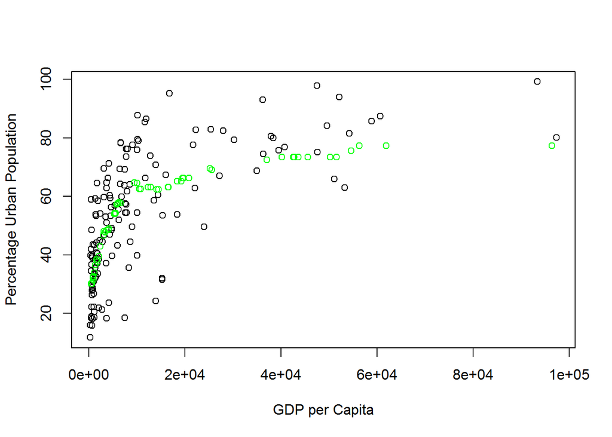

```r
my_knn <- function(x_pred, x, y, k){
  m <- length(x_pred)
  predict_knn <- rep(0, m)
  for (i in 1:m) {

    # Calculate the absolute distance between x_pred[i] and x
    dist <- abs(x_pred[i] - x)

    # Apply order() to dist, sort_index will contain
    # the indices of elements in the dist vector, in
    # ascending order. This means sort_index[1:k] will
    # return the indices of the k-nearest neighbors.
    sort_index <- order(dist)

    # Apply mean() to the responses of the k-nearest neighbors
    predict_knn[i] <- mean(y[sort_index[1:k]])

  }
  return(predict_knn)
}


# Apply your algorithm on the test set: test_output
test_output <- my_knn(x_pred=world_bank_test$cgdp, x=world_bank_train$cgdp,
                      y=world_bank_train$urb_pop, k=30
                      )

# Have a look at the plot of the output
plot(world_bank_train[,2:1],
     xlab = "GDP per Capita",
     ylab = "Percentage Urban Population")
points(world_bank_test$cgdp, test_output, col = "green")
```

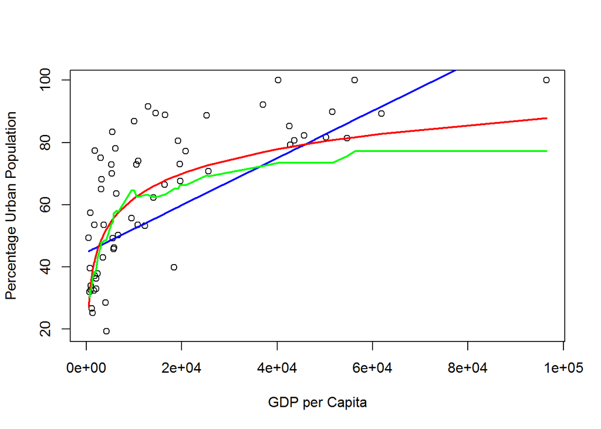

```r
# Set up a linear model between the two variables: lm_wb
lm_wb <- lm(urb_pop ~ cgdp, data=world_bank_train)

# Set up a linear model between the two variables: lm_wb
lm_wb_log <- lm(urb_pop ~ log(cgdp), data=world_bank_train)


# Define ranks to order the predictor variables in the test set
ranks <- order(world_bank_test$cgdp)

# Scatter plot of test set
plot(world_bank_test,
     xlab = "GDP per Capita", ylab = "Percentage Urban Population")

# Predict with simple linear model and add line
test_output_lm <- predict(lm_wb, data.frame(cgdp = world_bank_test$cgdp))
lines(world_bank_test$cgdp[ranks], test_output_lm[ranks], lwd = 2, col = "blue")

# Predict with log-linear model and add line
test_output_lm_log <- predict(lm_wb_log, data.frame(cgdp = world_bank_test$cgdp))
lines(world_bank_test$cgdp[ranks], test_output_lm_log[ranks], lwd = 2, col = "red")

# Predict with k-NN and add line
test_output_knn <- my_knn(x_pred=world_bank_test$cgdp, x=world_bank_train$cgdp,
                          y=world_bank_train$urb_pop, k=30
                          )
lines(world_bank_test$cgdp[ranks], test_output_knn[ranks], lwd = 2, col = "green")
```

```r
# Calculate RMSE on the test set for simple linear model
sqrt(mean( (test_output_lm - world_bank_test$urb_pop) ^ 2))
```

```
## [1] 17.41258
```

```r
# Calculate RMSE on the test set for log-linear model
sqrt(mean( (test_output_lm_log - world_bank_test$urb_pop) ^ 2))
```

```
## [1] 15.01008
```

```r
# Calculate RMSE on the test set for k-NN technique
sqrt(mean( (test_output_knn - world_bank_test$urb_pop) ^ 2))
```

```
## [1] 16.0917
```

Chapter 5 - Clustering

Clustering with k-means (unsupervised learning) - objects that are similar within and dissimilar across:

- The clusters have no pre-defined labels, and there is no right or wrong per se (different clustering seeds may return different clusters)
- Clustering can help with data visualization, pre-processing, outlier detection, target marketing, etc.
- Clustering requires definitions (measurements) for “similarity” of various observations; typically
  - Numeric variables can be standardized and then assessed using Euclidean and/or Manhattan distances
  - Categorical variables can be converted to 0/1 dummies, with a user-defined “distance” for 0 vs 1
- Clustering also requires a selection of a methodology, for example
  - k-means separates the data in to k disjoint subsets, reflecting the structure of the data
  - Botton-up hierarchical
- Measuring the outcome clusters looks at WSS (within sum-squares) and BSS (between cluster sum-squares)
  - WSS = sum-across-clusters-of ( sum-within-cluster-of ( distance-to-mean^2 ) )
  - BSS = sum-across-clsuters-of ( nObjects-in-cluster * (distance-cluster-centroid-to-fulldata-centroid )^2 )
- The R methodology for k-means is iterative
  1. Randomly assign k centroids
  2. Assign all data to the closest centroid
  3. Calculate the mean of each cluster, and make that the new centroid
  4. Repeat steps 2-3 until maxIter is reached or the segmentes do not change
- As a back-envelope rul-of-thumb, select k such that WSS is decreasing slowly, and that WSS / (WSS + BSS) < 0.2 ; can use the “Scree plot” to examine this
- kmeans(data, centers, nstart) # centers can either be the pre-defined clusters OR a number of clusters desired; nstart is the number of restarts with different centroids, frequently 10+
  - The clustering object will have $tot.withinss (WSS) and $betweenss (BSS), with calculations having been done from a Euclidean distance

Performance and scaling issues - since there is no “truth”, the goal is to have compact clusters with low variance within the clusters and high separation between the clusters:

- Can use Dunn’s index for ( minimum-distance-between-cluster-points ) / (maximum-diameter) # higher is better, but this has a high computational cost, and is skewed to the worst cluster in the data
- Internal validation can also include BIC and Silhouette’s Index
- External validation (based on previous knowledge) can be Hulbert’s Correlation or Jaccard’s Coefficient
- The R packages “cluster” and “clValid” contain the functions for many of these validations
  - clValid::dunn(clusters=, Data=)
- Scale of variables can pose challenges - frequently a good idea to “rescale” (at a minimum) so that variables are on the same scale
  - Typically, it is easiest to standardize (subtract mean, divide by sigma) all the variables
  - Can use scale(myData) to perform this ; caution that interpretation can be tricky since the units have been stripped of their scales

Hierarchical Clustering - addressing questions such as “which objects cluster first” and “which cluster pairs merge, and when”:

- Bottom-up (agglomerative) hierarchical clustering can provide further insights on a question of interest
- First, all the distances between objects are calculated and stored in a distance matrix
- Next, find the closest data points, merge them, call them a cluster, and compute the distance from this cluster to everything else
  - Distance can be simple-linkage (minimum distance from any point in the cluster to any point in the other cluster); often leads to undesirable chaining, though can be a very nice outlier detector as a result
  - Distance can be complete-linkage (maximum distance between any point in the cluster to any point in the other cluster)
  - Distance can be average-linkage (average distance between points in the cluster and points in the other cluster)
- The dedrogram (tree disgram) will show which leaves have merged where, with the heights being the distances at the merge; can prune at any height
- The distances can be calculated in R using dist(myData, method=) # euclidean, manhattan, etc.
- The clusters can be created using hclust(myDistanceData, method=)
- The hierarchical clustering methodology is in-depth, but at the expense of high computational costs; clusters cannot be un-merged as the process continues
- The k-means clustering methodology can undo merges and is computationally milder, but can be harder to interpret and also requires specifying the number of clusters and/or centroids

Example code includes:

```r
seeds <- data.frame(area=c( 15.26, 14.88, 14.29, 13.84, 16.14, 14.38, 14.69, 14.11, 16.63, 16.44, 15.26, 14.03, 13.89, 13.78, 13.74, 14.59, 13.99, 15.69, 14.7, 12.72, 14.16, 14.11, 15.88, 12.08, 15.01, 16.19, 13.02, 12.74, 14.11, 13.45, 13.16, 15.49, 14.09, 13.94, 15.05, 16.12, 16.2, 17.08, 14.8, 14.28, 13.54, 13.5, 13.16, 15.5, 15.11, 13.8, 15.36, 14.99, 14.79, 14.86, 14.43, 15.78, 14.49, 14.33, 14.52, 15.03, 14.46, 14.92, 15.38, 12.11, 11.42, 11.23, 12.36, 13.22, 12.78, 12.88, 14.34, 14.01, 14.37, 12.73, 17.63, 16.84, 17.26, 19.11, 16.82, 16.77, 17.32, 20.71, 18.94, 17.12, 16.53, 18.72, 20.2, 19.57, 19.51, 18.27, 18.88, 18.98, 21.18, 20.88, 20.1, 18.76, 18.81, 18.59, 18.36, 16.87, 19.31, 18.98, 18.17, 18.72, 16.41, 17.99, 19.46, 19.18, 18.95, 18.83, 18.85, 17.63, 19.94, 18.55, 18.45, 19.38, 19.13, 19.14, 20.97, 19.06, 18.96, 19.15, 18.89, 20.03, 20.24, 18.14, 16.17, 18.43, 15.99, 18.75, 18.65, 17.98, 20.16, 17.55, 18.3, 18.94, 15.38, 16.16, 15.56, 15.38, 17.36, 15.57, 15.6, 16.23, 13.07, 13.32, 13.34, 12.22, 11.82, 11.21, 11.43, 12.49, 12.7, 10.79, 11.83, 12.01, 12.26, 11.18, 11.36, 11.19, 11.34, 12.13, 11.75, 11.49, 12.54, 12.02, 12.05, 12.55, 11.14, 12.1, 12.44, 12.15, 11.35, 11.24, 11.02, 11.55, 11.27, 11.4, 10.83, 10.8, 11.26, 10.74, 11.48, 12.21, 11.41, 12.46, 12.19, 11.65, 12.89, 11.56, 11.81, 10.91, 11.23, 10.59, 10.93, 11.27, 11.87, 10.82, 12.11, 12.8, 12.79, 13.37, 12.62, 12.76, 12.38, 12.67, 11.18, 12.7, 12.37, 12.19, 11.23, 13.2, 11.84, 12.3 ))
seeds$perimeter <- c( 14.84, 14.57, 14.09, 13.94, 14.99, 14.21, 14.49, 14.1, 15.46, 15.25, 14.85, 14.16, 14.02, 14.06, 14.05, 14.28, 13.83, 14.75, 14.21, 13.57, 14.4, 14.26, 14.9, 13.23, 14.76, 15.16, 13.76, 13.67, 14.18, 14.02, 13.82, 14.94, 14.41, 14.17, 14.68, 15, 15.27, 15.38, 14.52, 14.17, 13.85, 13.85, 13.55, 14.86, 14.54, 14.04, 14.76, 14.56, 14.52, 14.67, 14.4, 14.91, 14.61, 14.28, 14.6, 14.77, 14.35, 14.43, 14.77, 13.47, 12.86, 12.63, 13.19, 13.84, 13.57, 13.5, 14.37, 14.29, 14.39, 13.75, 15.98, 15.67, 15.73, 16.26, 15.51, 15.62, 15.91, 17.23, 16.49, 15.55, 15.34, 16.19, 16.89, 16.74, 16.71, 16.09, 16.26, 16.66, 17.21, 17.05, 16.99, 16.2, 16.29, 16.05, 16.52, 15.65, 16.59, 16.57, 16.26, 16.34, 15.25, 15.86, 16.5, 16.63, 16.42, 16.29, 16.17, 15.86, 16.92, 16.22, 16.12, 16.72, 16.31, 16.61, 17.25, 16.45, 16.2, 16.45, 16.23, 16.9, 16.91, 16.12, 15.38, 15.97, 14.89, 16.18, 16.41, 15.85, 17.03, 15.66, 15.89, 16.32, 14.9, 15.33, 14.89, 14.66, 15.76, 15.15, 15.11, 15.18, 13.92, 13.94, 13.95, 13.32, 13.4, 13.13, 13.13, 13.46, 13.71, 12.93, 13.23, 13.52, 13.6, 13.04, 13.05, 13.05, 12.87, 13.73, 13.52, 13.22, 13.67, 13.33, 13.41, 13.57, 12.79, 13.15, 13.59, 13.45, 13.12, 13, 13, 13.1, 12.97, 13.08, 12.96, 12.57, 13.01, 12.73, 13.05, 13.47, 12.95, 13.41, 13.36, 13.07, 13.77, 13.31, 13.45, 12.8, 12.82, 12.41, 12.8, 12.86, 13.02, 12.83, 13.27, 13.47, 13.53, 13.78, 13.67, 13.38, 13.44, 13.32, 12.72, 13.41, 13.47, 13.2, 12.88, 13.66, 13.21, 13.34 )
seeds$compactness <- c( 0.87, 0.88, 0.9, 0.9, 0.9, 0.9, 0.88, 0.89, 0.87, 0.89, 0.87, 0.88, 0.89, 0.88, 0.87, 0.9, 0.92, 0.91, 0.92, 0.87, 0.86, 0.87, 0.9, 0.87, 0.87, 0.88, 0.86, 0.86, 0.88, 0.86, 0.87, 0.87, 0.85, 0.87, 0.88, 0.9, 0.87, 0.91, 0.88, 0.89, 0.89, 0.89, 0.9, 0.88, 0.9, 0.88, 0.89, 0.89, 0.88, 0.87, 0.88, 0.89, 0.85, 0.88, 0.86, 0.87, 0.88, 0.9, 0.89, 0.84, 0.87, 0.88, 0.89, 0.87, 0.87, 0.89, 0.87, 0.86, 0.87, 0.85, 0.87, 0.86, 0.88, 0.91, 0.88, 0.86, 0.86, 0.88, 0.88, 0.89, 0.88, 0.9, 0.89, 0.88, 0.88, 0.89, 0.9, 0.86, 0.9, 0.9, 0.87, 0.9, 0.89, 0.91, 0.85, 0.86, 0.88, 0.87, 0.86, 0.88, 0.89, 0.9, 0.9, 0.87, 0.88, 0.89, 0.91, 0.88, 0.88, 0.89, 0.89, 0.87, 0.9, 0.87, 0.89, 0.89, 0.91, 0.89, 0.9, 0.88, 0.89, 0.88, 0.86, 0.91, 0.91, 0.9, 0.87, 0.9, 0.87, 0.9, 0.91, 0.89, 0.87, 0.86, 0.88, 0.9, 0.88, 0.85, 0.86, 0.88, 0.85, 0.86, 0.86, 0.87, 0.83, 0.82, 0.83, 0.87, 0.85, 0.81, 0.85, 0.82, 0.83, 0.83, 0.84, 0.83, 0.86, 0.81, 0.81, 0.83, 0.84, 0.85, 0.84, 0.86, 0.86, 0.88, 0.85, 0.84, 0.83, 0.84, 0.82, 0.85, 0.84, 0.84, 0.81, 0.86, 0.84, 0.83, 0.85, 0.85, 0.86, 0.87, 0.86, 0.86, 0.85, 0.82, 0.82, 0.84, 0.86, 0.86, 0.84, 0.86, 0.88, 0.83, 0.86, 0.89, 0.88, 0.88, 0.85, 0.9, 0.86, 0.9, 0.87, 0.89, 0.86, 0.88, 0.85, 0.89, 0.85, 0.87 )
seeds$length <- c( 5.76, 5.55, 5.29, 5.32, 5.66, 5.39, 5.56, 5.42, 6.05, 5.88, 5.71, 5.44, 5.44, 5.48, 5.48, 5.35, 5.12, 5.53, 5.21, 5.23, 5.66, 5.52, 5.62, 5.1, 5.79, 5.83, 5.39, 5.39, 5.54, 5.52, 5.45, 5.76, 5.72, 5.58, 5.71, 5.71, 5.83, 5.83, 5.66, 5.4, 5.35, 5.35, 5.14, 5.88, 5.58, 5.38, 5.7, 5.57, 5.54, 5.68, 5.58, 5.67, 5.71, 5.5, 5.74, 5.7, 5.39, 5.38, 5.66, 5.16, 5.01, 4.9, 5.08, 5.39, 5.26, 5.14, 5.63, 5.61, 5.57, 5.41, 6.19, 6, 5.98, 6.15, 6.02, 5.93, 6.06, 6.58, 6.45, 5.85, 5.88, 6.01, 6.29, 6.38, 6.37, 6.17, 6.08, 6.55, 6.57, 6.45, 6.58, 6.17, 6.27, 6.04, 6.67, 6.14, 6.34, 6.45, 6.27, 6.22, 5.72, 5.89, 6.11, 6.37, 6.25, 6.04, 6.15, 6.03, 6.67, 6.15, 6.11, 6.3, 6.18, 6.26, 6.56, 6.42, 6.05, 6.25, 6.23, 6.49, 6.32, 6.06, 5.76, 5.98, 5.36, 6.11, 6.29, 5.98, 6.51, 5.79, 5.98, 6.14, 5.88, 5.84, 5.78, 5.48, 6.14, 5.92, 5.83, 5.87, 5.47, 5.54, 5.39, 5.22, 5.31, 5.28, 5.18, 5.27, 5.39, 5.32, 5.26, 5.41, 5.41, 5.22, 5.17, 5.25, 5.05, 5.39, 5.44, 5.3, 5.45, 5.35, 5.27, 5.33, 5.01, 5.11, 5.32, 5.42, 5.18, 5.09, 5.33, 5.17, 5.09, 5.14, 5.28, 4.98, 5.19, 5.14, 5.18, 5.36, 5.09, 5.24, 5.24, 5.11, 5.5, 5.36, 5.41, 5.09, 5.09, 4.9, 5.05, 5.09, 5.13, 5.18, 5.24, 5.16, 5.22, 5.32, 5.41, 5.07, 5.22, 4.98, 5.01, 5.18, 5.2, 5.14, 5.14, 5.24, 5.17, 5.24 )
seeds$width <- c( 3.31, 3.33, 3.34, 3.38, 3.56, 3.31, 3.26, 3.3, 3.46, 3.5, 3.24, 3.2, 3.2, 3.16, 3.11, 3.33, 3.38, 3.51, 3.47, 3.05, 3.13, 3.17, 3.51, 2.94, 3.25, 3.42, 3.03, 2.96, 3.22, 3.06, 2.98, 3.37, 3.19, 3.15, 3.33, 3.48, 3.46, 3.68, 3.29, 3.3, 3.16, 3.16, 3.2, 3.4, 3.46, 3.15, 3.39, 3.38, 3.29, 3.26, 3.27, 3.43, 3.11, 3.2, 3.11, 3.21, 3.38, 3.41, 3.42, 3.03, 2.85, 2.88, 3.04, 3.07, 3.03, 3.12, 3.19, 3.16, 3.15, 2.88, 3.56, 3.48, 3.59, 3.93, 3.49, 3.44, 3.4, 3.81, 3.64, 3.57, 3.47, 3.86, 3.86, 3.77, 3.8, 3.65, 3.76, 3.67, 4.03, 4.03, 3.79, 3.8, 3.69, 3.86, 3.48, 3.46, 3.81, 3.55, 3.51, 3.68, 3.52, 3.69, 3.89, 3.68, 3.75, 3.79, 3.81, 3.57, 3.76, 3.67, 3.77, 3.79, 3.9, 3.74, 3.99, 3.72, 3.9, 3.82, 3.77, 3.86, 3.96, 3.56, 3.39, 3.77, 3.58, 3.87, 3.59, 3.69, 3.77, 3.69, 3.75, 3.83, 3.27, 3.4, 3.41, 3.46, 3.57, 3.23, 3.29, 3.47, 2.99, 3.07, 3.07, 2.97, 2.78, 2.69, 2.72, 2.97, 2.91, 2.65, 2.84, 2.78, 2.83, 2.69, 2.75, 2.67, 2.85, 2.75, 2.68, 2.69, 2.88, 2.81, 2.85, 2.97, 2.79, 2.94, 2.9, 2.84, 2.67, 2.71, 2.7, 2.85, 2.76, 2.76, 2.64, 2.82, 2.71, 2.64, 2.76, 2.89, 2.77, 3.02, 2.91, 2.85, 3.03, 2.68, 2.72, 2.67, 2.82, 2.79, 2.72, 2.8, 2.95, 2.63, 2.98, 3.13, 3.05, 3.13, 2.91, 3.15, 2.99, 3.13, 2.81, 3.09, 2.96, 2.98, 2.8, 3.23, 2.84, 2.97 )
seeds$asymmetry <- c( 2.22, 1.02, 2.7, 2.26, 1.36, 2.46, 3.59, 2.7, 2.04, 1.97, 4.54, 1.72, 3.99, 3.14, 2.93, 4.18, 5.23, 1.6, 1.77, 4.1, 3.07, 2.69, 0.77, 1.42, 1.79, 0.9, 3.37, 2.5, 2.75, 3.53, 0.86, 3.41, 3.92, 2.12, 2.13, 2.27, 2.82, 2.96, 3.11, 6.68, 2.59, 2.25, 2.46, 4.71, 3.13, 1.56, 1.37, 2.96, 2.7, 2.13, 3.98, 5.59, 4.12, 3.33, 1.48, 1.93, 2.8, 1.14, 2, 1.5, 2.7, 2.27, 3.22, 4.16, 1.18, 2.35, 1.31, 2.22, 1.46, 3.53, 4.08, 4.67, 4.54, 2.94, 4, 4.92, 3.82, 4.45, 5.06, 2.86, 5.53, 5.32, 5.17, 1.47, 2.96, 2.44, 1.65, 3.69, 5.78, 5.02, 1.96, 3.12, 3.24, 6, 4.93, 3.7, 3.48, 2.14, 2.85, 2.19, 4.22, 2.07, 4.31, 3.36, 3.37, 2.55, 2.84, 3.75, 3.25, 1.74, 2.23, 3.68, 2.11, 6.68, 4.68, 2.25, 4.33, 3.08, 3.64, 3.06, 5.9, 3.62, 4.29, 2.98, 3.34, 4.19, 4.39, 2.26, 1.91, 5.37, 2.84, 2.91, 4.46, 4.27, 4.97, 3.6, 3.53, 2.64, 2.73, 3.77, 5.3, 7.04, 6, 5.47, 4.47, 6.17, 2.22, 4.42, 3.26, 5.46, 5.2, 6.99, 4.76, 3.33, 4.05, 5.81, 3.35, 4.83, 4.38, 5.39, 3.08, 4.27, 4.99, 4.42, 6.39, 2.2, 4.92, 3.64, 4.34, 3.52, 6.74, 6.71, 4.31, 5.59, 5.18, 4.77, 5.34, 4.7, 5.88, 1.66, 4.96, 4.99, 4.86, 5.21, 6.18, 4.06, 4.9, 4.18, 7.52, 4.97, 5.4, 3.98, 3.6, 4.85, 4.13, 4.87, 5.48, 4.67, 3.31, 2.83, 5.47, 2.3, 4.05, 8.46, 3.92, 3.63, 4.33, 8.31, 3.6, 5.64 )
seeds$groove_length <- c( 5.22, 4.96, 4.83, 4.8, 5.17, 4.96, 5.22, 5, 5.88, 5.53, 5.31, 5, 4.74, 4.87, 4.83, 4.78, 4.78, 5.05, 4.65, 4.91, 5.18, 5.22, 5.09, 4.96, 5, 5.31, 4.83, 4.87, 5.04, 5.1, 5.06, 5.23, 5.3, 5.01, 5.36, 5.44, 5.53, 5.48, 5.31, 5, 5.18, 5.18, 4.78, 5.53, 5.18, 4.96, 5.13, 5.17, 5.11, 5.35, 5.14, 5.14, 5.4, 5.22, 5.49, 5.44, 5.04, 5.09, 5.22, 4.52, 4.61, 4.7, 4.61, 5.09, 4.78, 4.61, 5.15, 5.13, 5.3, 5.07, 6.06, 5.88, 5.79, 6.08, 5.84, 5.8, 5.92, 6.45, 6.36, 5.75, 5.88, 5.88, 6.19, 6.27, 6.18, 6.2, 6.11, 6.5, 6.23, 6.32, 6.45, 6.05, 6.05, 5.88, 6.45, 5.97, 6.24, 6.45, 6.27, 6.1, 5.62, 5.84, 6.01, 6.23, 6.15, 5.88, 6.2, 5.93, 6.55, 5.89, 5.79, 5.96, 5.92, 6.05, 6.32, 6.16, 5.75, 6.18, 5.97, 6.32, 6.19, 6.01, 5.7, 5.91, 5.14, 5.99, 6.1, 5.92, 6.18, 5.66, 5.96, 5.95, 5.8, 5.8, 5.85, 5.44, 5.97, 5.88, 5.75, 5.92, 5.39, 5.44, 5.31, 5.22, 5.18, 5.28, 5.13, 5, 5.32, 5.19, 5.31, 5.27, 5.36, 5, 5.26, 5.22, 5, 5.22, 5.31, 5.31, 5.49, 5.31, 5.05, 5.18, 5.05, 5.06, 5.27, 5.34, 5.13, 5.09, 5.16, 4.96, 5, 5.09, 5.18, 5.06, 5.09, 4.96, 5, 5.18, 4.83, 5.15, 5.16, 5.13, 5.32, 5.18, 5.35, 4.96, 4.96, 4.79, 5.04, 5, 5.13, 5.09, 5.01, 4.91, 4.96, 5.09, 5.23, 4.83, 5.04, 4.75, 4.83, 5, 5, 4.87, 5, 5.06, 5.04, 5.06 )
str(seeds)
```

```
## 'data.frame':    210 obs. of  7 variables:
##  $ area         : num  15.3 14.9 14.3 13.8 16.1 ...
##  $ perimeter    : num  14.8 14.6 14.1 13.9 15 ...
##  $ compactness  : num  0.87 0.88 0.9 0.9 0.9 0.9 0.88 0.89 0.87 0.89 ...
##  $ length       : num  5.76 5.55 5.29 5.32 5.66 5.39 5.56 5.42 6.05 5.88 ...
##  $ width        : num  3.31 3.33 3.34 3.38 3.56 3.31 3.26 3.3 3.46 3.5 ...
##  $ asymmetry    : num  2.22 1.02 2.7 2.26 1.36 2.46 3.59 2.7 2.04 1.97 ...
##  $ groove_length: num  5.22 4.96 4.83 4.8 5.17 4.96 5.22 5 5.88 5.53 ...
```

```r
seeds_type <- c( 1, 1, 1, 1, 1, 1, 1, 1, 1, 1, 1, 1, 1, 1, 1, 1, 1, 1, 1, 1, 1, 1, 1, 1, 1, 1, 1, 1, 1, 1, 1, 1, 1, 1, 1, 1, 1, 1, 1, 1, 1, 1, 1, 1, 1, 1, 1, 1, 1, 1, 1, 1, 1, 1, 1, 1, 1, 1, 1, 1, 1, 1, 1, 1, 1, 1, 1, 1, 1, 1, 2, 2, 2, 2, 2, 2, 2, 2, 2, 2, 2, 2, 2, 2, 2, 2, 2, 2, 2, 2, 2, 2, 2, 2, 2, 2, 2, 2, 2, 2, 2, 2, 2, 2, 2, 2, 2, 2, 2, 2, 2, 2, 2, 2, 2, 2, 2, 2, 2, 2, 2, 2, 2, 2, 2, 2, 2, 2, 2, 2, 2, 2, 2, 2, 2, 2, 2, 2, 2, 2, 3, 3, 3, 3, 3, 3, 3, 3, 3, 3, 3, 3, 3, 3, 3, 3, 3, 3, 3, 3, 3, 3, 3, 3, 3, 3, 3, 3, 3, 3, 3, 3, 3, 3, 3, 3, 3, 3, 3, 3, 3, 3, 3, 3, 3, 3, 3, 3, 3, 3, 3, 3, 3, 3, 3, 3, 3, 3, 3, 3, 3, 3, 3, 3, 3, 3, 3, 3, 3, 3 )

# Do k-means clustering with three clusters, repeat 20 times: seeds_km
seeds_km <- kmeans(seeds, centers=3, nstart=20)

# Print out seeds_km
seeds_km
```

```
## K-means clustering with 3 clusters of sizes 72, 77, 61
##
## Cluster means:
##       area perimeter compactness   length    width asymmetry groove_length
## 1 14.64847  14.46042   0.8794444 5.563333 3.277639  2.649306      5.192778
## 2 11.96442  13.27481   0.8529870 5.229481 2.872857  4.759870      5.088442
## 3 18.72180  16.29738   0.8855738 6.209016 3.721967  3.603607      6.065902
##
## Clustering vector:
##   [1] 1 1 1 1 1 1 1 1 1 1 1 1 1 1 1 1 2 1 1 2 1 1 1 1 1 1 2 1 1 1 1 1 1 1 1
##  [36] 1 1 3 1 2 1 1 1 1 1 1 1 1 1 1 1 1 1 1 1 1 1 1 1 1 2 2 2 2 1 1 1 1 1 2
##  [71] 3 3 3 3 3 3 3 3 3 3 3 3 3 3 3 3 3 3 3 3 3 3 3 3 3 3 3 3 3 3 1 3 3 3 3
## [106] 3 3 3 3 3 3 3 3 3 3 3 3 3 3 3 3 3 1 3 1 3 3 3 3 3 3 3 1 1 1 1 3 1 1 1
## [141] 2 2 2 2 2 2 2 2 2 2 2 2 2 2 2 2 2 2 2 2 2 2 2 2 2 2 2 2 2 2 2 2 2 2 2
## [176] 2 2 2 2 1 2 2 2 2 2 2 2 2 2 2 2 2 2 2 2 2 2 2 2 2 2 1 2 2 2 2 2 2 2 2
##
## Within cluster sum of squares by cluster:
## [1] 207.4138 195.7171 184.0488
##  (between_SS / total_SS =  78.4 %)
##
## Available components:
##
## [1] "cluster"      "centers"      "totss"        "withinss"
## [5] "tot.withinss" "betweenss"    "size"         "iter"
## [9] "ifault"
```

```r
# Compare clusters with actual seed types. Set k-means clusters as rows
table(seeds_km$cluster, seeds_type)
```

```
##    seeds_type
##      1  2  3
##   1 60 10  2
##   2  9  0 68
##   3  1 60  0
```

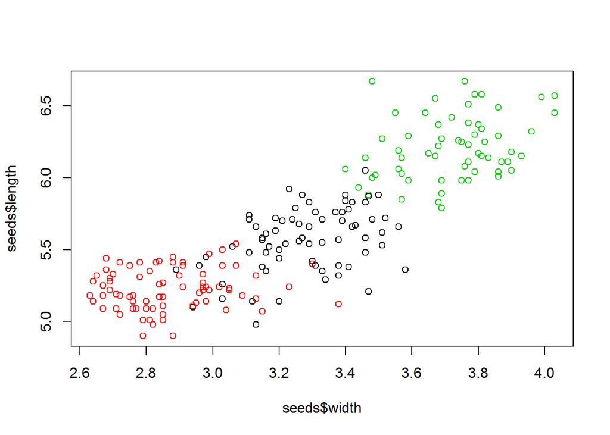

```r
# Plot the length as function of width. Color by cluster
plot(x=seeds$width, y=seeds$length, col=seeds_km$cluster)
```

```r
# Apply kmeans to seeds twice: seeds_km_1 and seeds_km_2
seeds_km_1 <- kmeans(seeds, centers=5, nstart=1)
seeds_km_2 <- kmeans(seeds, centers=5, nstart=1)

# Return the ratio of the within cluster sum of squares
seeds_km_1$tot.withinss / seeds_km_2$tot.withinss
```

```
## [1] 1.062865
```

```r
# Compare the resulting clusters
table(seeds_km_1$cluster, seeds_km_2$cluster)
```

```
##
##      1  2  3  4  5
##   1  0 14  0 27  0
##   2  0  0 48  0  6
##   3 21 29  0  0  0
##   4 21  0  0  0  0
##   5  0  0  0 19 25
```

```r
school_result <- data.frame(reading.4=c( 2.7, 3.9, 4.8, 3.1, 3.4, 3.1, 4.6, 3.1, 3.8, 5.2, 3.9, 4.1,
                                         5.7, 3, 2.9, 3.4, 4, 3, 4, 3, 3.6, 3.1, 3.2, 3, 3.8
                                        ),
                            arithmetic.4=c( 3.2, 3.8, 4.1, 3.5, 3.7, 3.4, 4.4, 3.3, 3.7, 4.9, 3.8, 4,
                                            5.1, 3.2, 3.3, 3.3, 4.2, 3, 4.1, 3.2, 3.6, 3.2, 3.3, 3.4, 4
                                          ),
                            reading.6=c( 4.5, 5.9, 6.8, 4.3, 5.1, 4.1, 6.6, 4, 4.7, 8.2, 5.2, 5.6, 7,
                                         4.5, 4.5, 4.4, 5.2, 4.6, 5.9, 4.4, 5.3, 4.6, 5.4, 4.2, 6.9
                                        ),
                            arithmetic.6=c( 4.8, 6.2, 5.5, 4.6, 5.6, 4.7, 6.1, 4.9, 4.9, 6.9, 5.4, 5.6,
                                            6.3, 5, 5.1, 5, 5.4, 5, 5.8, 5.1, 5.4, 5, 5.3, 4.7, 6.7
                                          )
                            )

# Explore the structure of your data
str(school_result)
```

```
## 'data.frame':    25 obs. of  4 variables:
##  $ reading.4   : num  2.7 3.9 4.8 3.1 3.4 3.1 4.6 3.1 3.8 5.2 ...
##  $ arithmetic.4: num  3.2 3.8 4.1 3.5 3.7 3.4 4.4 3.3 3.7 4.9 ...
##  $ reading.6   : num  4.5 5.9 6.8 4.3 5.1 4.1 6.6 4 4.7 8.2 ...
##  $ arithmetic.6: num  4.8 6.2 5.5 4.6 5.6 4.7 6.1 4.9 4.9 6.9 ...
```

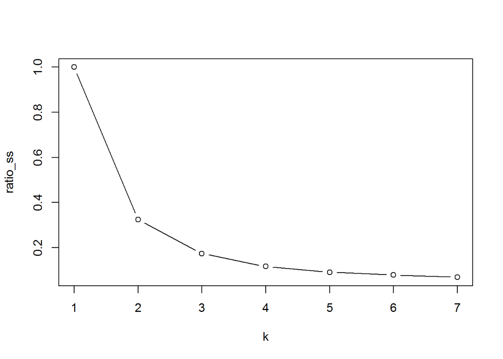

```r
# Initialise ratio_ss
ratio_ss <- rep(0, 7)

# Finish the for-loop.
for (k in 1:7) {

  # Apply k-means to school_result: school_km
  school_km <- kmeans(school_result, centers=k, nstart=20)

  # Save the ratio between of WSS to TSS in kth element of ratio_ss
  ratio_ss[k] <- school_km$tot.withinss / school_km$totss

}

# Make a scree plot with type "b" and xlab "k"
plot(ratio_ss, type="b", xlab="k")
```

```r
run_record <- data.frame(X100m=c( 10.23, 9.93, 10.15, 10.14, 10.27, 10, 9.84, 10.1, 10.17, 10.29, 10.97, 10.32, 10.24, 10.29, 10.16, 10.21, 10.02, 10.06, 9.87, 10.11, 10.32, 10.08, 10.33, 10.2, 10.35, 10.2, 10.01, 10, 10.28, 10.34, 10.6, 10.41, 10.3, 10.13, 10.21, 10.64, 10.19, 10.11, 10.08, 10.4, 10.57, 10, 9.86, 10.21, 10.11, 10.78, 10.37, 10.17, 10.18, 10.16, 10.36, 10.23, 10.38, 9.78 )
                         )
run_record$X200m <- c( 20.37, 20.06, 20.45, 20.19, 20.3, 19.89, 20.17, 20.15, 20.42, 20.85, 22.46, 20.96, 20.61, 20.52, 20.65, 20.47, 20.16, 20.23, 19.94, 19.85, 21.09, 20.11, 20.73, 20.93, 20.54, 20.89, 19.72, 20.03, 20.43, 20.41, 21.23, 20.77, 20.92, 20.06, 20.4, 21.52, 20.19, 20.42, 20.17, 21.18, 21.43, 19.98, 20.12, 20.75, 20.23, 21.86, 21.14, 20.59, 20.43, 20.41, 20.81, 20.69, 21.04, 19.32
                       )
run_record$X400m <- c( 46.18, 44.38, 45.8, 45.02, 45.26, 44.29, 44.72, 45.92, 45.25, 45.84, 51.4, 46.42, 45.77, 45.89, 44.9, 45.49, 44.64, 44.33, 44.36, 45.57, 48.44, 45.43, 45.48, 46.37, 45.58, 46.59, 45.26, 44.78, 44.18, 45.37, 46.95, 47.9, 46.41, 44.69, 44.31, 48.63, 45.68, 46.09, 46.11, 46.77, 45.57, 44.62, 46.11, 45.77, 44.6, 49.98, 47.6, 44.96, 45.54, 44.99, 46.72, 46.05, 46.63, 43.18
                       )
run_record$X800m <- c( 106.2, 104.4, 106.2, 103.8, 107.4, 102, 105, 105.6, 106.2, 108, 116.4, 112.2, 105, 101.4, 108.6, 104.4, 103.2, 103.8, 102, 105, 109.2, 105.6, 105.6, 109.8, 105, 108, 103.8, 106.2, 102, 104.4, 109.2, 105.6, 107.4, 108, 106.8, 108, 103.8, 104.4, 102.6, 108, 108, 103.2, 105, 105.6, 102.6, 116.4, 110.4, 103.8, 105.6, 102.6, 107.4, 108.6, 106.8, 102.6
                       )
run_record$X1500m <- c( 220.8, 211.8, 214.8, 214.2, 222, 214.2, 211.8, 219, 216.6, 223.2, 254.4, 230.4, 214.8, 211.2, 223.8, 216.6, 208.8, 211.8, 209.4, 216.6, 224.4, 215.4, 217.8, 226.2, 213.6, 222, 213, 217.2, 206.4, 218.4, 226.2, 220.2, 225.6, 229.8, 217.8, 228, 213, 212.4, 217.2, 240, 229.2, 215.4, 210, 214.2, 212.4, 240.6, 231.6, 208.8, 216.6, 211.8, 226.2, 226.2, 215.4, 207.6
                        )
run_record$X5000m <- c( 799.8, 775.8, 795.6, 769.8, 878.4, 808.8, 793.8, 803.4, 805.2, 809.4, 1002, 825, 805.2, 805.2, 858.6, 796.2, 778.8, 774.6, 780.6, 808.8, 838.8, 807, 810, 852.6, 784.2, 819.6, 785.4, 793.2, 759.6, 830.4, 834, 818.4, 846.6, 849, 787.8, 851.4, 793.2, 792.6, 786.6, 883.2, 838.2, 797.4, 783, 795, 792, 976.8, 897.6, 782.4, 797.4, 787.8, 834.6, 855, 807, 778.2
                        )
run_record$X10000m <- c( 1659, 1651.8, 1663.2, 1612.2, 1829.4, 1687.8, 1656, 1685.4, 1690.2, 1672.8, 2122.8, 1728.6, 1668, 1674.6, 1825.8, 1651.2, 1642.8, 1641.6, 1638, 1687.2, 1760.4, 1681.8, 1728.6, 1779, 1666.8, 1723.2, 1636.8, 1654.8, 1587.6, 1710.6, 1707, 1726.2, 1770, 1790.4, 1628.4, 1777.2, 1646.4, 1662, 1652.4, 1881.6, 1742.4, 1673.4, 1632.6, 1660.2, 1674, 2082.6, 1879.2, 1634.4, 1675.8, 1674, 1752, 1780.2, 1699.8, 1633.8
                         )
run_record$marathon <- c( 7774.2, 7650.6, 7933.2, 7632, 8782.2, 7563, 7805.4, 7931.4, 7750.8, 7870.2, 10275.6, 7993.8, 7894.2, 7765.8, 8760, 7869, 7581.6, 7708.2, 7627.8, 7922.4, 7951.8, 7926, 7920, 8350.8, 7749, 8052.6, 7637.4, 7569.6, 7473, 7632, 7755.6, 8041.8, 8956.2, 8584.2, 7631.4, 8374.2, 7698.6, 7715.4, 7810.2, 8887.8, 8306.4, 7753.8, 7581.6, 7938, 7749.6, 9690, 8653.2, 7633.8, 7822.8, 7773.6, 8061, 8359.8, 7815, 7522.8
                          )
rownames(run_record) <- c( 'Argentina', 'Australia', 'Austria', 'Belgium', 'Bermuda', 'Brazil', 'Canada', 'Chile', 'China', 'Columbia', 'CookIslands', 'CostaRica', 'CzechRepublic', 'Denmark', 'DominicanRepub', 'Finland', 'France', 'Germany', 'GreatBritain', 'Greece', 'Guatemala', 'Hungary', 'India', 'Indonesia', 'Ireland', 'Israel', 'Italy', 'Japan', 'Kenya', 'Korea,South', 'Korea,North', 'Luxembourg', 'Malaysia', 'Mauritius', 'Mexico', 'Myanmar(Burma)', 'Netherlands', 'NewZealand', 'Norway', 'PapuaNewGuinea', 'Philippines', 'Poland', 'Portugal', 'Romania', 'Russia', 'Samoa', 'Singapore', 'Spain', 'Sweden', 'Switzerland', 'Taiwan', 'Thailand', 'Turkey', 'U.S.A.'
                           )

# Explore your data with str() and summary()
str(run_record)
```

```
## 'data.frame':    54 obs. of  8 variables:
##  $ X100m   : num  10.23 9.93 10.15 10.14 10.27 ...
##  $ X200m   : num  20.4 20.1 20.4 20.2 20.3 ...
##  $ X400m   : num  46.2 44.4 45.8 45 45.3 ...
##  $ X800m   : num  106 104 106 104 107 ...
##  $ X1500m  : num  221 212 215 214 222 ...
##  $ X5000m  : num  800 776 796 770 878 ...
##  $ X10000m : num  1659 1652 1663 1612 1829 ...
##  $ marathon: num  7774 7651 7933 7632 8782 ...
```

```r
summary(run_record)
```

```
##      X100m           X200m           X400m           X800m
##  Min.   : 9.78   Min.   :19.32   Min.   :43.18   Min.   :101.4
##  1st Qu.:10.10   1st Qu.:20.17   1st Qu.:44.91   1st Qu.:103.8
##  Median :10.20   Median :20.43   Median :45.58   Median :105.6
##  Mean   :10.22   Mean   :20.54   Mean   :45.83   Mean   :106.1
##  3rd Qu.:10.32   3rd Qu.:20.84   3rd Qu.:46.32   3rd Qu.:108.0
##  Max.   :10.97   Max.   :22.46   Max.   :51.40   Max.   :116.4
##      X1500m          X5000m          X10000m        marathon
##  Min.   :206.4   Min.   : 759.6   Min.   :1588   Min.   : 7473
##  1st Qu.:213.0   1st Qu.: 788.9   1st Qu.:1653   1st Qu.: 7701
##  Median :216.6   Median : 805.2   Median :1675   Median : 7819
##  Mean   :219.2   Mean   : 817.1   Mean   :1712   Mean   : 8009
##  3rd Qu.:224.2   3rd Qu.: 834.5   3rd Qu.:1739   3rd Qu.: 8050
##  Max.   :254.4   Max.   :1002.0   Max.   :2123   Max.   :10276
```

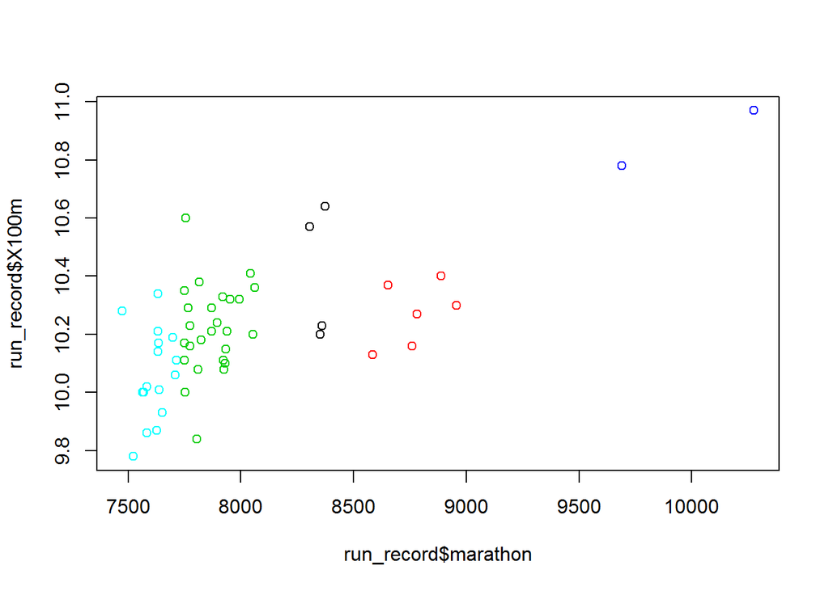

```r
# Cluster run_record using k-means: run_km. 5 clusters, repeat 20 times
run_km <- kmeans(run_record, centers=5, nstart=20)

# Plot the 100m as function of the marathon. Color using clusters
plot(x=run_record$marathon, y=run_record$X100m, col=run_km$cluster)
```

```r
# Calculate Dunn's index: dunn_km. Print it.
(dunn_km <- clValid::dunn(clusters=run_km$cluster, Data=run_record))
```

```
## [1] 0.05954843
```

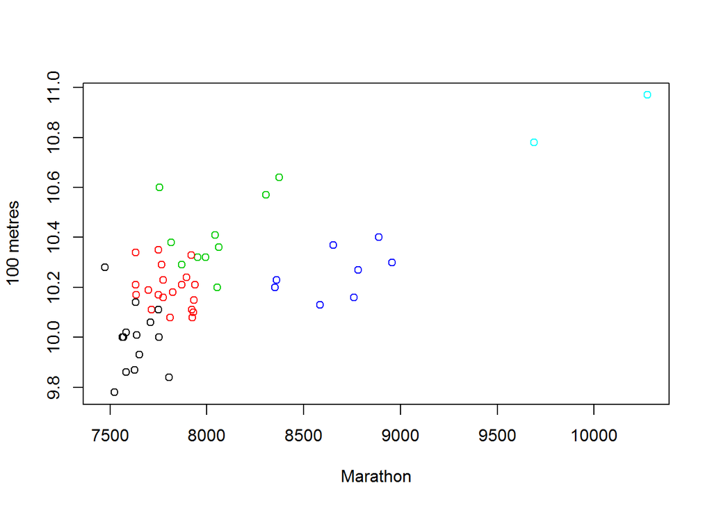

```r
# Standardize run_record, transform to a dataframe: run_record_sc
run_record_sc <- as.data.frame( scale(run_record) )

# Cluster run_record_sc using k-means: run_km_sc. 5 groups, let R start over 20 times
run_km_sc <- kmeans(run_record_sc, centers=5, nstart=20)

# Plot records on 100m as function of the marathon. Color using the clusters in run_km_sc
plot(x=run_record$marathon, y=run_record$X100m, col=run_km_sc$cluster,
     xlab="Marathon", ylab="100 metres"
     )
```